# SRPA Replication in France

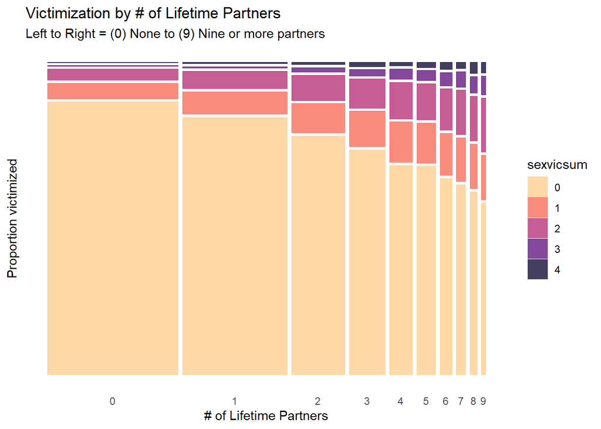

```r
mosym <- mosyplot(df=datv3, "sexvicsum", "nlp", "# of Lifetime Partners",
         "Proportion victimized", "Victimization by # of Lifetime Partners",
         "Left to Right = (0) None to (9) Nine or more partners"
)
mosym
```

**Sexual activity by SRPA (mean)**

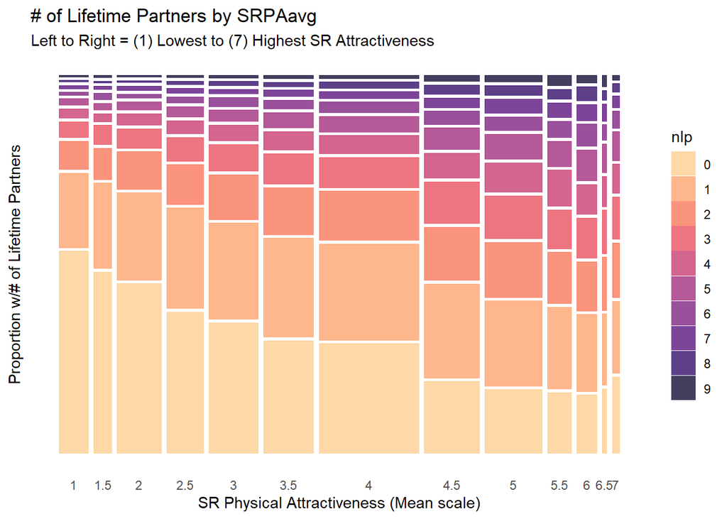

```r
mosmx <- mosyplot(df=datv3, "nlp", "SRPAavg", "SR Physical Attractiveness (Mean scale)",
         "Proportion w/# of Lifetime Partners", "# of Lifetime Partners by SRPAavg",
         "Left to Right = (1) Lowest to (7) Highest SR Attractiveness"
)
mosmx
```

**Sexual activity by SRPA (95 pctl)**

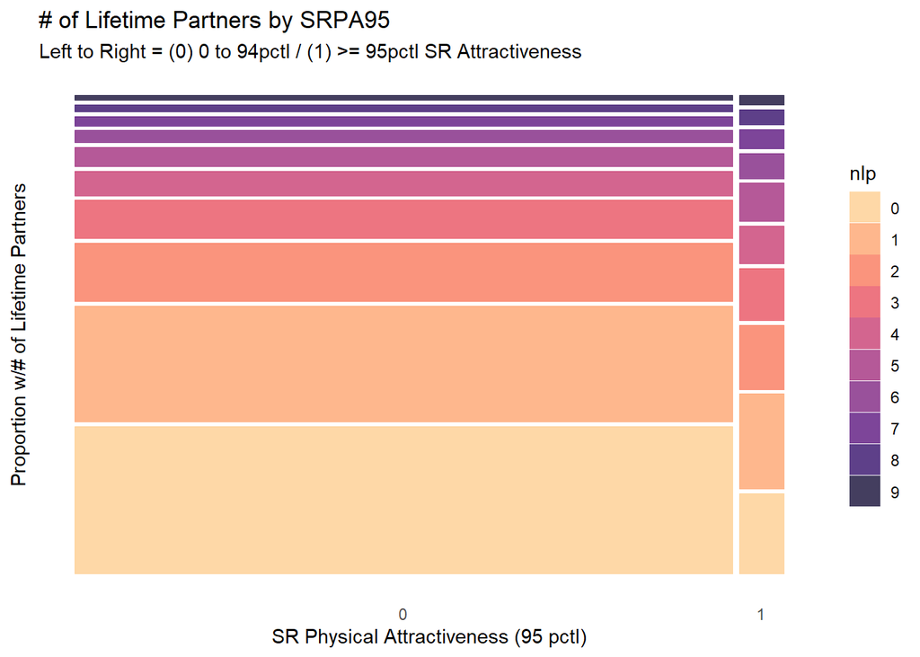

```r
mosmx95 <- mosyplot(df=datv3, "nlp", "SRPA95", "SR Physical Attractiveness (95 pctl)",
         "Proportion w/# of Lifetime Partners", "# of Lifetime Partners by SRPA95",
         "Left to Right = (0) 0 to 94pctl / (1) >= 95pctl SR Attractiveness"
)
mosmx95
```

#### 5.3.1 FIG2: Combined mosaic plots (full & by gender)

Let’s split the sample by gender and then combine these plots into one.

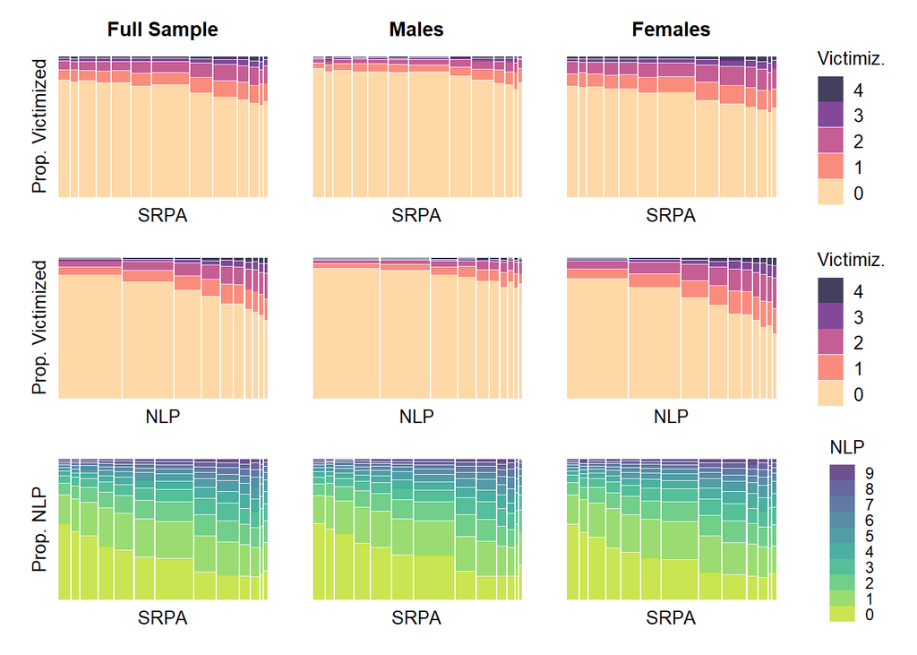

```r
#data subsets for males & females
datv3male <- datv3 %>% dplyr::filter(gender==1)
datv3fem <- datv3 %>% dplyr::filter(gender==2)

#Function to generate simpler mosaic plots to combine in patchwork

mosyplot2 <- function(df, yvar, xvar, guidelab, xlab){
df %>%
  ggplot() +
  geom_mosaic(aes(x = product(!!as.name(yvar), !!as.name(xvar)), fill = !!as.name(yvar)),
              na.rm=TRUE) +
  scale_fill_viridis_d(begin=.1, end=.9, direction=-1, option="magma") +
  guides(fill = guide_legend(reverse=T)) +
  labs(fill=guidelab, x = xlab) +
  theme_minimal() +
  theme(panel.grid.major = element_blank(),
        panel.grid.minor = element_blank(),
        axis.title.x = element_text(size=10, vjust = 3),
        axis.text.y = element_blank(),
        axis.text.x = element_blank(),
        legend.key.height= unit(.5, 'cm'),
        legend.key.width= unit(.5, 'cm'),
        legend.title = element_text(size=10),
        legend.text=element_text(size=10))
  }


# sexvicsum by SRPAavg
mosyx <- mosyplot2(df=datv3, "sexvicsum", "SRPAavg", "Victimiz.", "SRPA") +
  labs(y= "Prop. Victimized", subtitle="Full Sample") +
  theme(axis.title.y= element_text(size=10, vjust = -2),
        plot.subtitle = element_text(hjust = 0.5, face="bold"))

# sexvicsum by SRPAavg - male
mosyx_m <- mosyplot2(df=datv3male, "sexvicsum", "SRPAavg", "Victimiz.", "SRPA") +
  labs(subtitle="Males") +
  theme(axis.title.y = element_blank(),
        plot.subtitle = element_text(hjust = 0.5, face="bold"))

# sexvicsum by SRPAavg - female
mosyx_f <- mosyplot2(df=datv3fem, "sexvicsum", "SRPAavg", "Victimiz.", "SRPA") +
  labs(subtitle="Females") +
  theme(axis.title.y = element_blank(),
        plot.subtitle = element_text(hjust = 0.5, face="bold"))

# sexvicsum by nlp
mosym <- mosyplot2(df=datv3, "sexvicsum", "nlp", "Victimiz.", "NLP") +
  labs(y= "Prop. Victimized") +
  theme(axis.title.y= element_text(size=10, vjust = -2))

# sexvicsum by nlp - male
mosym_m <- mosyplot2(df=datv3male, "sexvicsum", "nlp", "Victimiz.", "NLP") +
  theme(axis.title.y = element_blank())

# sexvicsum by nlp - female
mosym_f <- mosyplot2(df=datv3fem, "sexvicsum", "nlp", "Victimiz.", "NLP") +
  theme(axis.title.y = element_blank())

# nlp by SRPAavg
mosmx <- mosyplot2(df=datv3, "nlp", "SRPAavg", "NLP", "SRPA") +
  scale_fill_viridis_d(begin=.1, end=.9, direction=-1, option="viridis") +
  labs(y= "Prop. NLP") +
  theme(legend.key.height= unit(.3, 'cm'),
        legend.key.width= unit(.5, 'cm'),
        legend.text=element_text(size=9),
        axis.title.y= element_text(size=10, vjust = -2))

# nlp by SRPAavg - male
mosmx_m <- mosyplot2(df=datv3male, "nlp", "SRPAavg", "NLP", "SRPA") +
  scale_fill_viridis_d(begin=.1, end=.9, direction=-1, option="viridis") +
  theme(legend.key.height= unit(.3, 'cm'),
        legend.key.width= unit(.5, 'cm'),
        legend.text=element_text(size=9),
        axis.title.y = element_blank())

# nlp by SRPAavg - female
mosmx_f <- mosyplot2(df=datv3fem, "nlp", "SRPAavg", "NLP", "SRPA") +
  scale_fill_viridis_d(begin=.1, end=.9, direction=-1, option="viridis") +
  theme(legend.key.height= unit(.3, 'cm'),
        legend.key.width= unit(.5, 'cm'),
        legend.text=element_text(size=9),
        axis.title.y = element_blank())

mosaicfig <- (mosyx + mosyx_m + mosyx_f + plot_layout(guides = 'collect')) /
  (mosym + mosym_m + mosym_f + plot_layout(guides = 'collect')) /
    (mosmx + mosmx_m + mosmx_f + plot_layout(guides = 'collect'))
mosaicfig
```

```r
# ggsave("mosaicfig.jpeg", mosaicfig, width=9, height=6.5)
```

As expected, victimization risks increase with SR physical attractiveness and sexual activity, and sexual activity is higher for those self-rated as more physically attractive.

## 6 Modeling

Before estimating a model, it is a good idea to view distributions of our key variables to ensure we specify appropriate link functions.

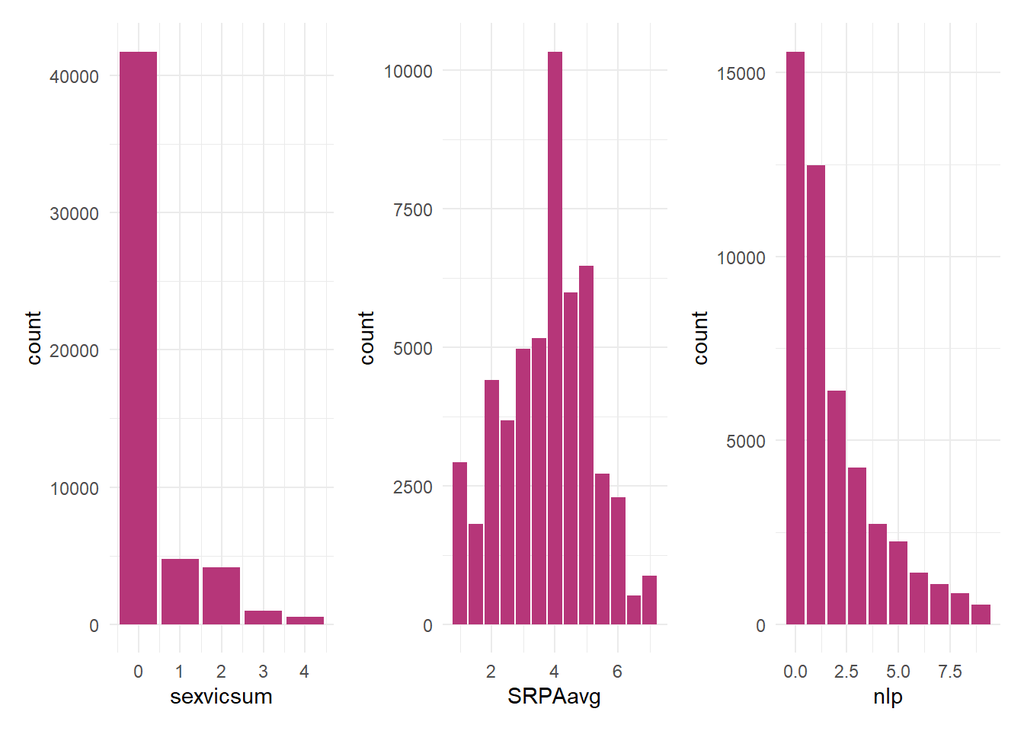

```r
# magma(5, alpha = 1, begin = 0, end = 1, direction = 1)

# datv3 %>% summarytools::freq(sexvicsum)
# datv3 %>% summarytools::freq(SRPAavg)

p1 <- ggplot(datv3, aes(sexvicsum)) + geom_bar(fill="#B63679FF") + theme_minimal()
p2 <- ggplot(datv3, aes(SRPAavg)) + geom_bar(fill="#B63679FF") + theme_minimal()
p3 <- ggplot(datv3, aes(nlp)) + geom_bar(fill="#B63679FF") + theme_minimal()

p1 + p2 + p3
```

`SRPAavg` has 13 categories and exhibits approximately symmetric decay about the mean. It might be appropriate to treat it as a metric continuous predictor, though there is little downside to treating it as an ordinal variable (given we have sufficient data, which we do, and ample processing power).

In contrast, `nlp` and `sexvicsum` exhibit highly skewed ordinal distributions. Ordinal modeling techniques are likely to be more appropriate for these variables.

### 6.1 Ordinal: So What?

Building a regression model that treats ordinal variables as if they are metric continuous variables can generate model predictions that exhibit poor fit to the data and, ultimately, can result in substantial inference errors (e.g., see [Liddell & Kruschke 2018](https://www.sciencedirect.com/science/article/abs/pii/S0022103117307746)).

In the first couple models below, I present linear and ordinal Bayesian “Intercept only” models to illustrate the poor fit of linear modeling to ordinal data and the substantial improvements we gain in predictive fit to underlying data distribution by using ordinal (e.g., cumulative probit) modeing instead.

### 6.2 Intercept: Lin~1 model (poor fit)

I start by estimating a simple linear intercept model of `sexvicsum` with no predictors to illustrate the poor fit of a linear model to the ordinal outcome. I use Bayesian estimation with diffuse priors; Bayesian models will be beneficial for model building and visualization later.

```r
  #Manual caching for stan_glm - file & file_refit built into brms
mod1 <- stan_glm(sexvicsum ~ 1,
            family = gaussian(),
            data = datv3,
            prior_intercept = normal(.3, 2.5),
            chains = 4,
            cores = nCoresphys,
            seed = 1138
            )

# mcmc_areas(mod1, regex_pars = "^bsp_", prob = 0.95) +
#     labs(title = "Coefficient plot",
#          subtitle = "Posterior distributions for monotonic ordinal stress coefficients \nwith medians and 95% intervals")

# mcmc_plot(modelfit, variable = "^bsp_", regex = TRUE, prob = 0.80, prob_outer = 0.95) +
#         labs(title = "Coefficient plot",
#              subtitle = "Posterior intervals for monotonic ordinal stress coefficients
#              \nwith medians, 80%, and 95% intervals")
```

**PPcheck(density)**

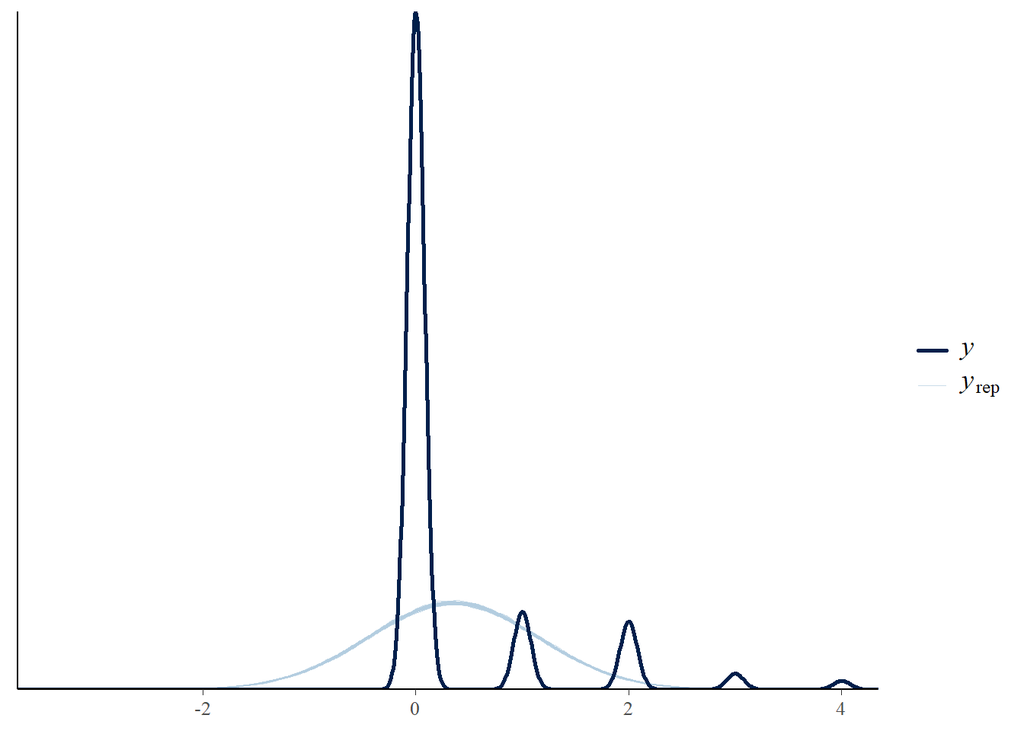

```r
pp_check(mod1)
```

**PPcheck(histogram)**

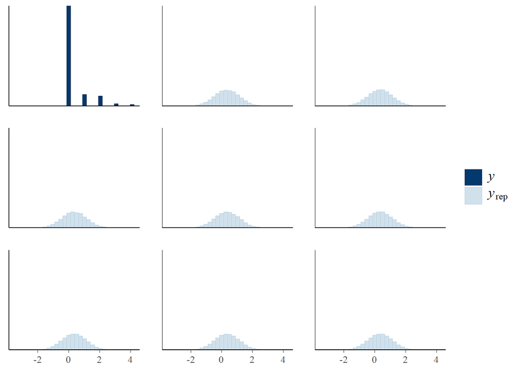

```r
pp_check(mod1, plotfun = "hist")
```

**PPcheck(boxplots)**

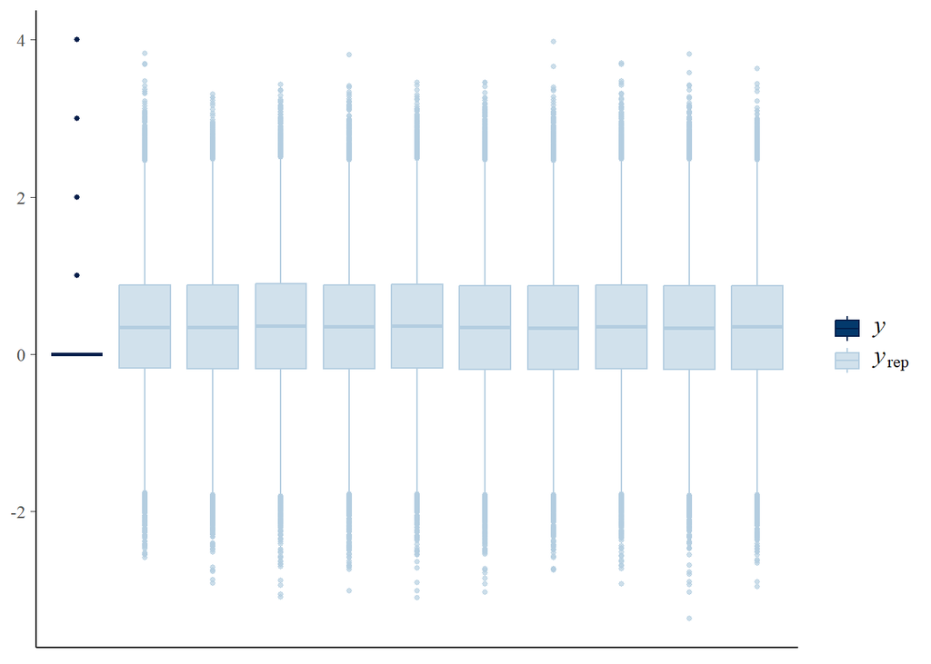

```r
pp_check(mod1, plotfun = "boxplot", nreps = 10, notch = FALSE)
```

**Fit summary**

```r
summary(mod1, probs = c(0.025, 0.975), digits = 2) #summarize results
```

```
Model Info:
 function:     stan_glm
 family:       gaussian [identity]
 formula:      sexvicsum ~ 1
 algorithm:    sampling
 sample:       4000 (posterior sample size)
 priors:       see help('prior_summary')
 observations: 52191
 predictors:   1

Estimates:
              mean   sd   2.5%   97.5%
(Intercept) 0.35   0.00 0.34   0.36
sigma       0.79   0.00 0.78   0.79

Fit Diagnostics:
           mean   sd   2.5%   97.5%
mean_PPD 0.35   0.00 0.34   0.36

The mean_ppd is the sample average posterior predictive distribution of the outcome variable (for details see help('summary.stanreg')).

MCMC diagnostics
              mcse Rhat n_eff
(Intercept)   0.00 1.00 2892
sigma         0.00 1.00 2877
mean_PPD      0.00 1.00 3347
log-posterior 0.02 1.00 1741

For each parameter, mcse is Monte Carlo standard error, n_eff is a crude measure of effective sample size, and Rhat is the potential scale reduction factor on split chains (at convergence Rhat=1).
```

**Prior summary**

```r
prior_summary(mod1) #check priors
```

```
Priors for model 'mod1'
------
Intercept (after predictors centered)
 ~ normal(location = 0.3, scale = 2.5)

Auxiliary (sigma)
  Specified prior:
    ~ exponential(rate = 1)
  Adjusted prior:
    ~ exponential(rate = 1.3)
------
See help('prior_summary.stanreg') for more details
```

Now, let’s compare how a basic cumulative probit model without predictors fits the data.

### 6.3 Priors on ordinal response distribution

I will specify what is essentially a flat prior distribution on the response thresholds in the cumulative probit model by specifying values that equate to equal probabilities (=1/5 or 0.20) for each of the five response categories. Transforming these to cumulative normal distribution thresholds results in values of c(-.84, -.25, .25, .84).

I could specify somewhat more informative priors. For instance, I know that sexual victimization is a relatively rare event, so I could specify the probability of a “0” response as something like 0.6, then specify lower [=0.10 instead of 0.20] and equal probabilities for the remaining categories. One advantage (or drawback, depending on your perspective and aims) of specifying flat priors is that results will typically converge with those generated by traditional frequentist methods.

### 6.4 Intercept: Ord~1 (better fit)

```r
#Ordinal cumulative probit model of sexual victimization index

#estimation is slow - cache model fits

#sexvicsum is a 5-category ordinal variable (0 to 4)
# table(datv3$sexvicsumf)

# develop formula
bf.form = brms::bf(sexvicsumf ~ 1)

# brms default prior is a wide student's t dist
get_prior(bf.form, data = datv3, family = cumulative('probit'))
```

```
                prior     class coef group resp dpar nlpar lb ub       source
 student_t(3, 0, 2.5) Intercept                                       default
 student_t(3, 0, 2.5) Intercept    1                             (vectorized)
 student_t(3, 0, 2.5) Intercept    2                             (vectorized)
 student_t(3, 0, 2.5) Intercept    3                             (vectorized)
 student_t(3, 0, 2.5) Intercept    4                             (vectorized)
```

```r
# use this code to identify values that set priors to equal likelihood for all thresholds
# tibble(rating = 0:4) %>%
#   mutate(proportion = 1/5) %>%
#   mutate(cumulative_proportion = cumsum(proportion)) %>%
#   mutate(right_hand_threshold = qnorm(cumulative_proportion))

# if I wanted to specify more informative priors, I could use this code to identify values that set priors to 0.6 for "no victimization" and equal 0.1 probability for all nonzero thresholds

# tibble(rating = 0:4) %>%
#   mutate(proportion = if_else(rating == 0,.6,.1)) %>%
#   mutate(cumulative_proportion = cumsum(proportion)) %>%
#   mutate(right_hand_threshold = qnorm(cumulative_proportion))

# altpriors = c(
#   prior(normal(0.25, 1), class = Intercept, coef = 1),
#   prior(normal(0.52, 1), class = Intercept, coef = 2),
#   prior(normal(0.84, 1), class = Intercept, coef = 3),
#   prior(normal(1.28, 1), class = Intercept, coef = 4)
# )


priors = c(
  prior(normal(-0.84, 1), class = Intercept, coef = 1),
  prior(normal(-0.25, 1), class = Intercept, coef = 2),
  prior(normal(0.25, 1), class = Intercept, coef = 3),
  prior(normal(0.84, 1), class = Intercept, coef = 4)
)

#sexvicsum - Thresholds only, Cumulative probit model:
mod2 <-
  brm(data = datv3,
      family = cumulative("probit"),
      sexvicsumf ~ 1,
      # prior(normal(0, 4), class = Intercept), #see kruschke/kurtz re: priors for this model
      prior = priors,
      iter = 2000, warmup = 1000,
      chains = 4,
      cores = nCoresphys,
        backend = "cmdstanr",
        # threads = threading(2), #consider within-chain threading if machine has at least 8 physical cores
      seed = 8675309,
      file = "Models/mod2_fit",
      file_refit = "on_change"
      )
```

**PPcheck(density)**

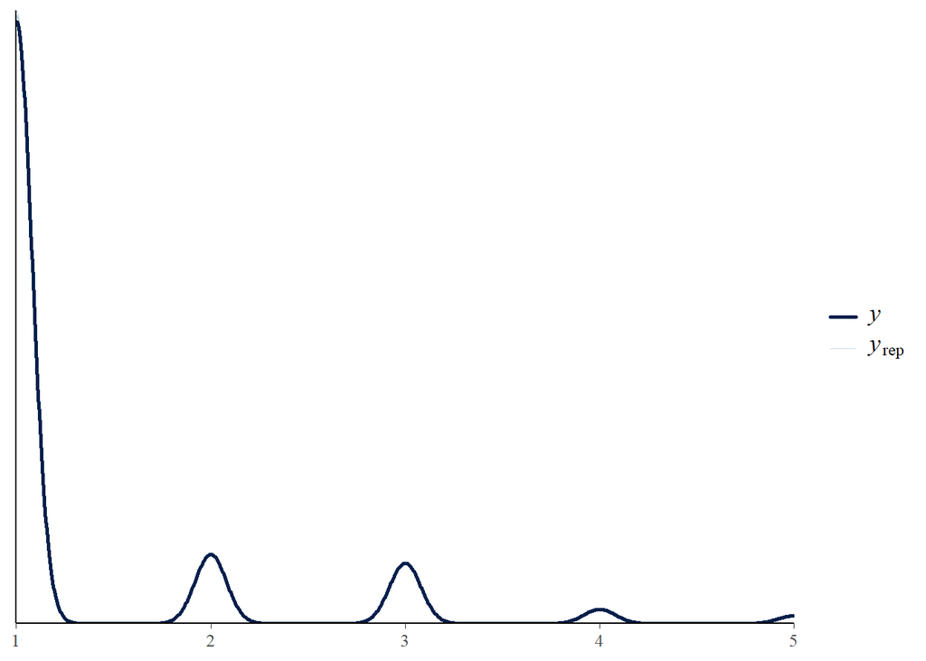

```r
pp_check(mod2)
```

**PPcheck(bars)**

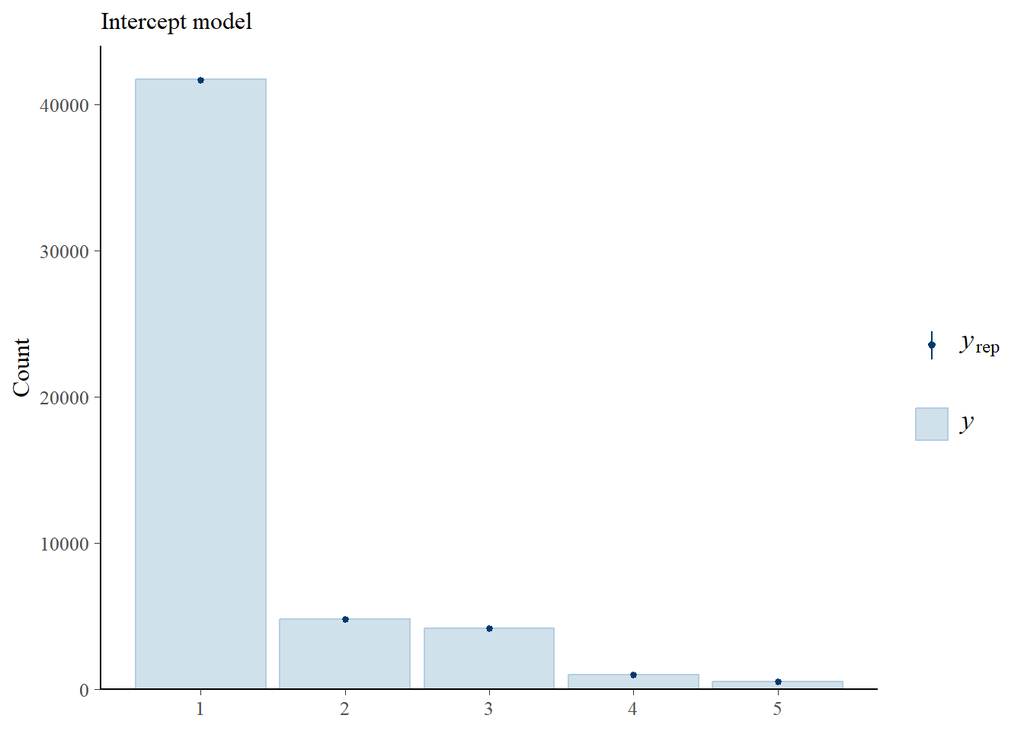

```r
pp_check(
  mod2,
  type = "bars",
  ndraws = 1000,
  linewidth = 1/2,
  size = 1/4) +
  labs(subtitle = "Intercept model")
```

**Fit summary**

```r
summary(mod2, probs = c(0.025, 0.975), digits = 2) #summarize results
```

```
 Family: cumulative
  Links: mu = probit; disc = identity
Formula: sexvicsumf ~ 1
   Data: datv3 (Number of observations: 52191)
  Draws: 4 chains, each with iter = 2000; warmup = 1000; thin = 1;
         total post-warmup draws = 4000

Regression Coefficients:
             Estimate Est.Error l-95% CI u-95% CI Rhat Bulk_ESS Tail_ESS
Intercept[1]     0.84      0.01     0.83     0.85 1.00     4089     3227
Intercept[2]     1.23      0.01     1.22     1.25 1.00     4921     3451
Intercept[3]     1.89      0.01     1.87     1.92 1.00     5022     3277
Intercept[4]     2.32      0.02     2.29     2.35 1.00     4696     3062

Further Distributional Parameters:
     Estimate Est.Error l-95% CI u-95% CI Rhat Bulk_ESS Tail_ESS
disc     1.00      0.00     1.00     1.00   NA       NA       NA

Draws were sampled using sample(hmc). For each parameter, Bulk_ESS
and Tail_ESS are effective sample size measures, and Rhat is the potential
scale reduction factor on split chains (at convergence, Rhat = 1).
```

**Prior summary**

```r
prior_summary(mod2) #check priors
```

```
                prior     class coef group resp dpar nlpar lb ub  source
 student_t(3, 0, 2.5) Intercept                                  default
     normal(-0.84, 1) Intercept    1                                user
     normal(-0.25, 1) Intercept    2                                user
      normal(0.25, 1) Intercept    3                                user
      normal(0.84, 1) Intercept    4                                user
```

As expected, posterior predictions generated by the cumulative probit model are a much better fit to the ordinal response data.

Now, let’s add SRPA as a metric (linear) predictor. Standardizing SRPA first provides interpretive advantages, as the beta coefficient in the cumulative probit model without predictors represents the (unadjusted, unconditional) predicted average marginal effect on latent victimization of increasing from an average SRPA score (mean=0) and one standard deviation units above average SRPA score (+1SD = 1).

Ultimately, I will illustrate what I think are preferable ways of interpreting and visualizing results of ordinal models using “maximum” (monotonic) marginal contrasts. Also, since the key predictors are ordinal items (nlp) or a composite of ordinal items (SRPA), I will follow this model with more complex versions that estimate monotonic effects using cumulative probit links for the key predictors (SRPA & nlp) as well as for the ordinal response variable. For now, let’s examine results of a bivariate cumulative probit model of victimization with a standardized metric SRPA (SRPAavgz) predictor.

### 6.5 Bivariate: Ord~Lin (sexvicsumf by SRPAavgz)

```r
#Ordinal cumulative probit model of sexual victimization index

# set priors:
# equal likelihood for all outcome thresholds
# weakly informative normal(0,1) for default beta

priors2 = c(
  prior(normal(-0.84, 1), class = Intercept, coef = 1),
  prior(normal(-0.25, 1), class = Intercept, coef = 2),
  prior(normal(0.25, 1), class = Intercept, coef = 3),
  prior(normal(0.84, 1), class = Intercept, coef = 4),
  prior(normal(0, 1), class = b)
)

#sexvicsum - bivariate sexvicsum by SRPAavg:
mod3 <-
  brm(data = datv3,
      family = cumulative("probit"),
      sexvicsumf ~ 1 + SRPAavgz,
      # prior(normal(0, 4), class = Intercept), #see kruschke/kurtz re: priors for this model
      prior = priors2,
      iter = 2000, warmup = 1000,
      chains = 4,
      cores = nCoresphys,
        backend = "cmdstanr",
        # threads = threading(2), #consider within-chain threading if machine has at least 8 physical cores
      seed = 8675309,
      file = "Models/mod3_fit",
      file_refit = "on_change"
      )
```

**Coefficient plot (SRPAavg)**

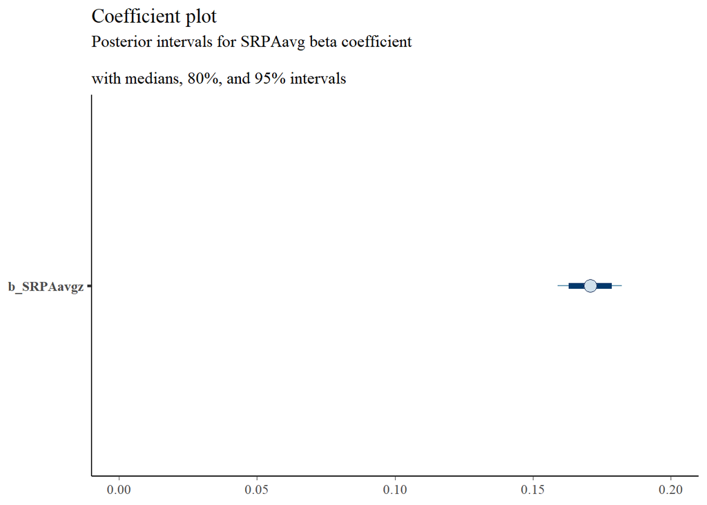

```r
post3 <- as.matrix(mod3)

mcmc_intervals(
  post3,
  regex_pars = "SRPAavg",
  prob = 0.8, # 80% intervals
  prob_outer = 0.95, # 95%
  point_est = "median",
) +
  xlim(0, .2) +
  labs(title = "Coefficient plot",
       subtitle = "Posterior intervals for SRPAavg beta coefficient
       \nwith medians, 80%, and 95% intervals")
```

```r
# mcmc_plot(mod3, variable = "SRPAavg", regex = TRUE,
#           prob = 0.80, prob_outer = 0.95) +
#   xlim(0, .2) +
#   labs(title = "Coefficient plot",
#        subtitle = "Posterior intervals for SRPAavg beta coefficient
#        \nwith medians, 80%, and 95% intervals")

# mcmc_areas(mod3, regex_pars = "SRPAavg", prob = 0.95) +
#   xlim(0, .3) +
#   labs(title = "Coefficient plot",
#        subtitle = "Posterior distributions for SRPAavg beta coefficient
#        \nwith medians and 95% intervals")
```

**Conditional effects (continuous y)**

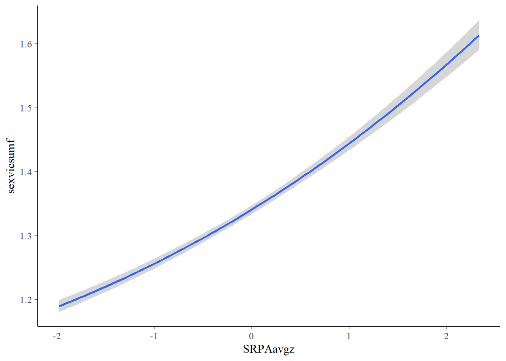

```r
conditional_effects(mod3, "SRPAavgz")
```

**Conditional effects (by y category)**

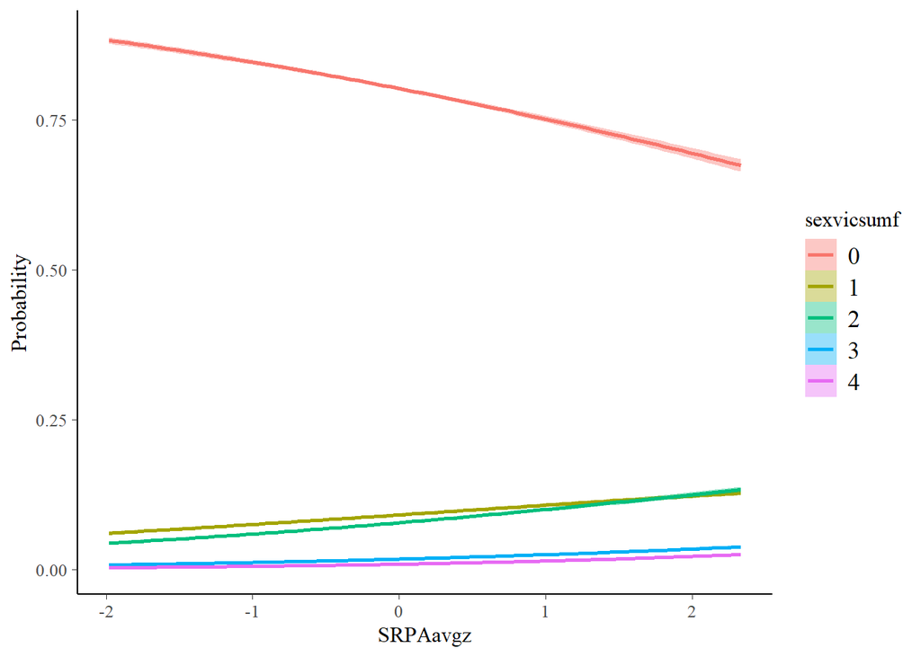

```r
conditional_effects(mod3, "SRPAavgz", categorical=TRUE)
```

**PPcheck(density)**

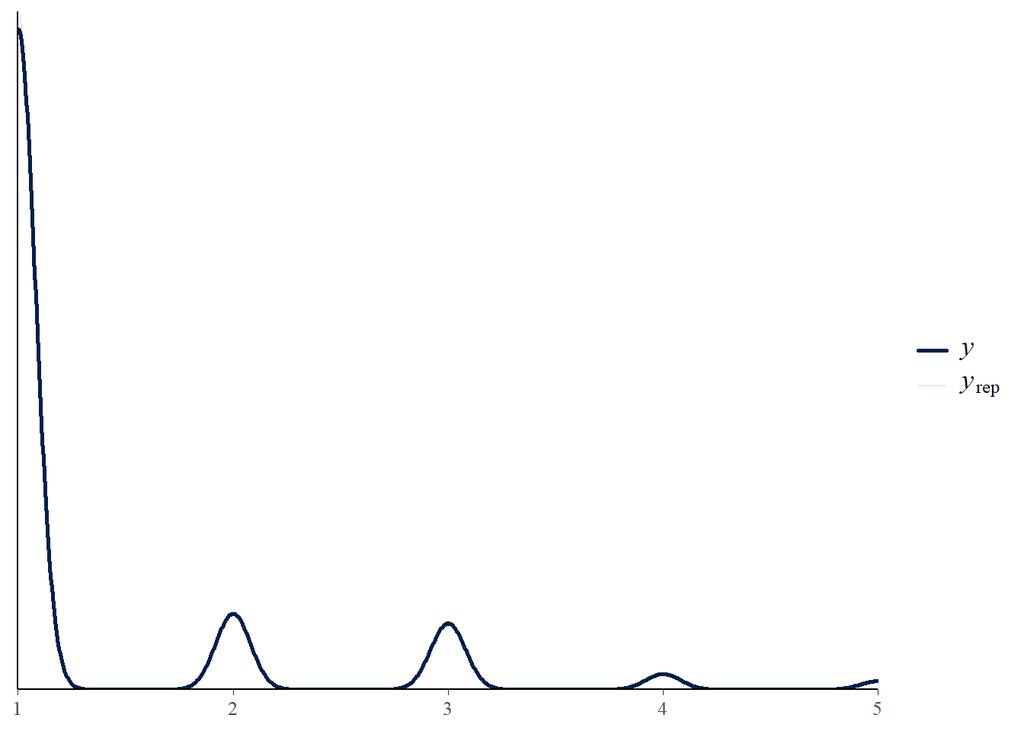

```r
pp_check(mod3)
```

**Fit summary**

```r
summary(mod3, probs = c(0.025, 0.975), digits = 2) #summarize results
```

```
 Family: cumulative
  Links: mu = probit; disc = identity
Formula: sexvicsumf ~ 1 + SRPAavgz
   Data: datv3 (Number of observations: 52191)
  Draws: 4 chains, each with iter = 2000; warmup = 1000; thin = 1;
         total post-warmup draws = 4000

Regression Coefficients:
             Estimate Est.Error l-95% CI u-95% CI Rhat Bulk_ESS Tail_ESS
Intercept[1]     0.85      0.01     0.84     0.86 1.00     5065     3316
Intercept[2]     1.25      0.01     1.23     1.26 1.00     4541     3160
Intercept[3]     1.92      0.01     1.90     1.94 1.00     5513     3212
Intercept[4]     2.35      0.02     2.32     2.38 1.00     5549     3067
SRPAavgz         0.17      0.01     0.16     0.18 1.00     4874     2751

Further Distributional Parameters:
     Estimate Est.Error l-95% CI u-95% CI Rhat Bulk_ESS Tail_ESS
disc     1.00      0.00     1.00     1.00   NA       NA       NA

Draws were sampled using sample(hmc). For each parameter, Bulk_ESS
and Tail_ESS are effective sample size measures, and Rhat is the potential
scale reduction factor on split chains (at convergence, Rhat = 1).
```

**Prior summary**

```r
prior_summary(mod3) #check priors
```

```
                prior     class     coef group resp dpar nlpar lb ub
         normal(0, 1)         b
         normal(0, 1)         b SRPAavgz
 student_t(3, 0, 2.5) Intercept
     normal(-0.84, 1) Intercept        1
     normal(-0.25, 1) Intercept        2
      normal(0.25, 1) Intercept        3
      normal(0.84, 1) Intercept        4
       source
         user
 (vectorized)
      default
         user
         user
         user
         user
```

#### 6.5.1 Visualize probs & contrasts by response category (mod3)

If the ordinal sexual victimization index (sexvicsum) can be plausibly assumed to represent a coarse measure of an underlying continuous latent sexual victimization variable (e.g., Bürkner & Vuorre, 2019; see [Kurz](https://solomonkurz.netlify.app/blog/2023-05-21-causal-inference-with-ordinal-regression/)), then the beta for SRPAavg from a cumulative probit response model represents the estimated average marginal effects of a 1-SD increase (from the mean to +1SD) in SRPAavg on the latent continuous victimization scale.

(It is past time I gave a huge shout-out to Solomon Kurz for his [blog on ordinal Bayesian models](https://solomonkurz.netlify.app/blog/2023-05-21-causal-inference-with-ordinal-regression/) and [bookdown translation of McElreath’s Monsters & Mixtures chapter](https://bookdown.org/content/4857/monsters-and-mixtures.html)).

Moreover, with the latent response expressed on a standard normal scale in a cumulative probit model, the beta can be interpreted as a latent Cohen’s D. Hence, the beta coefficients themselves in these models are useful for visualizing effect estimates. (Of course, causal interpretations require additional assumptions as well…)

Yet, with ordinal data, it can be helpful to visualize predicted probabilities and contrasts of these predicted probabilities separately for each ordinal response category. Let’s do that next.

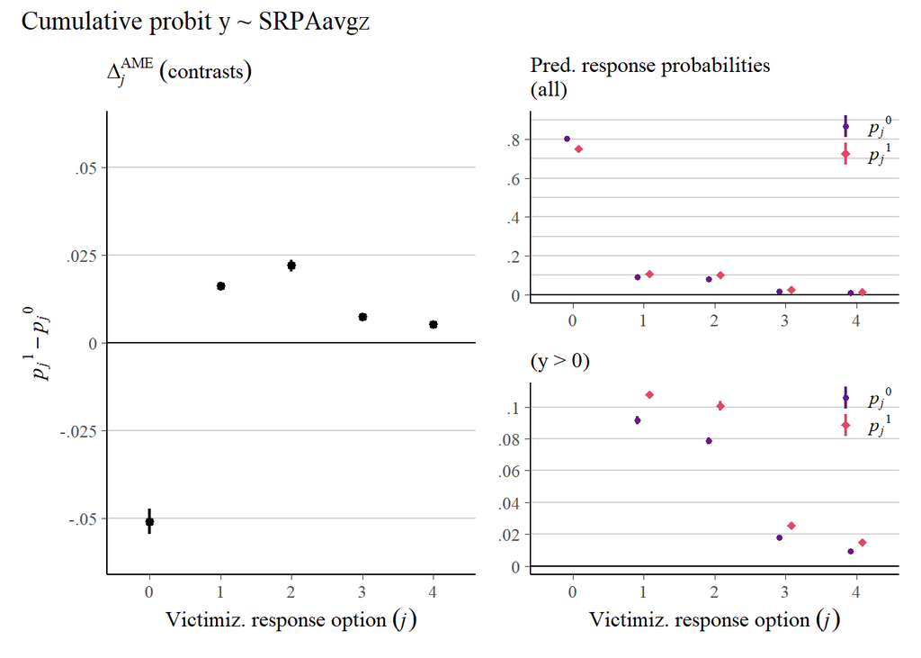

```r
#avg contrast on latent scale

#ANOVA
# latent scale - below generates same contrast estimate as model beta
# see https://solomonkurz.netlify.app/blog/2023-05-21-causal-inference-with-ordinal-regression/

# update the data grid
# nd_id <- datv3 %>%
#   mutate(id = row_number()) %>%
#   dplyr::select(id, nlpz, SRintelz, SRpopularz, agez, worked, gender) %>%
#   expand_grid(SRPAavgz = 0:1) %>%
#   mutate(row = 1:n())

# compute the posterior predictions
# fitted(mod3,
#        newdata = nd_id,
#        scale = "linear",
#        summary = F) %>%
#   # convert the results to a data frame
#   data.frame() %>%
#   # rename the columns
#   set_names(pull(nd_id, row)) %>%
#   # add a numeric index for the MCMC draws
#   mutate(draw = 1:n()) %>%
#   # convert to the long format
#   pivot_longer(-draw) %>%
#   # convert the row column from the character to the numeric format
#   mutate(row = as.double(name)) %>%
#   # join the nd_id predictor grid to the output
#   left_join(nd_id, by = "row") %>%
#   # drop two of the unnecessary columns
#   dplyr::select(-name, -row) %>%
#   # convert to a wider format so we can compute the contrast
#   pivot_wider(names_from = SRPAavgz, values_from = value) %>%
#   # compute the AME contrast
#   mutate(tau = `1` - `0`) %>%
#   # compute the average AME value within each MCMC draw
#   group_by(draw) %>%
#   summarise(ame = mean(tau)) %>%
#   # remove the draw index column
#   dplyr::select(ame) %>%
#   # now summarize the AME across the MCMC draws
#   summarise(m = mean(ame),
#             s = sd(ame),
#             ll = quantile(ame, probs = .025),
#             ul = quantile(ame, probs = .975))
#


#contrasts by response category

# define the predictor grid
nd <- tibble(SRPAavgz = 0:1)

# compute and save
fit3_conditional_probabilities_by_group <- nd %>%
  add_epred_draws(mod3) %>%
  ungroup()

# show the first 6 rows
# fit3_conditional_probabilities_by_group %>%
#   head()


#plot

# conditional probabilities (alt method - data type not working)
# mod3pred <- predictions(mod3, newdata = nd) %>%
#   data.frame() %>%
#   mutate(SRPAavgz = ifelse(SRPAavgz == 0, "italic(p[j])^0", "italic(p[j])^1"))

#use fitted + epred workflow
mod3pred <- fit3_conditional_probabilities_by_group %>%
  # now summarize the category-level probabilities, by SRPAavg
  group_by(SRPAavgz, .category) %>%
  summarise(p = mean(.epred),
            sd = sd(.epred),
            ll = quantile(.epred, probs = .025),
            ul = quantile(.epred, probs = .975)) %>%
  data.frame() %>%
  mutate(SRPAavgz = ifelse(SRPAavgz == 0, "italic(p[j])^0", "italic(p[j])^1"))

#function to find & drop leading zeroes (used for x-axis label)
dropLeadingZero <- function(l){
  str_replace(l, '0(?=.)', '')
}

#full range of y responses (0:4)
mod3p1 <- mod3pred %>%
  ggplot(aes(x = .category, y = p, ymin = ll, ymax = ul,
             color = SRPAavgz)) +
  geom_hline(yintercept = 0:9 / 10, color = "lightgrey") +
  geom_hline(yintercept = 0, color = "black") +
  geom_linerange(linewidth = 3/4, position = position_dodge(width = 1/3)) +
  geom_point(aes(shape = SRPAavgz),
             position = position_dodge(width = 1/3),
             size = 2) +
  scale_color_viridis_d(NULL, option = "magma", begin = .3, end = .6,
                        labels = scales::parse_format()) +
  scale_shape_manual(NULL, values = c(20, 18),
                     labels = scales::parse_format()) +
  scale_y_continuous(limits = c(0, .9), breaks=seq(0, .9, by = .2),
                     labels = dropLeadingZero) +
  labs(subtitle = "Pred. response probabilities\n(all)") +
  theme(legend.background = element_blank(),
        legend.position = c(0.9, 0.85),
        legend.key.height= unit(.5, 'cm'),
        legend.key.width= unit(.5, 'cm'),
        legend.title = element_text(size=10),
        legend.text=element_text(size=10),
        axis.title.y = element_blank(),
        axis.title.x = element_blank())

#nonzero victimization values only (1:4)
mod3p2 <- mod3pred %>%
  # dplyr::filter(.category != 0) %>%
  ggplot(aes(x = .category, y = p, ymin = ll, ymax = ul,
             color = SRPAavgz)) +
  geom_hline(yintercept = 0:5 / 50, color = "lightgrey") +
  geom_hline(yintercept = 0, color = "black") +
  geom_linerange(linewidth = 3/4, position = position_dodge(width = 1/3)) +
  geom_point(aes(shape = SRPAavgz),
             position = position_dodge(width = 1/3),
             size = 2) +
  scale_color_viridis_d(NULL, option = "magma", begin = .3, end = .6,
                        labels = scales::parse_format()) +
  scale_shape_manual(NULL, values = c(20, 18),
                     labels = scales::parse_format()) +
  scale_y_continuous(limits = c(0, .11), breaks=seq(0, .1, by = .02),
                     labels = dropLeadingZero) +
  labs(subtitle = "(y > 0)",
       x = expression(Victimiz.~response~option~(italic(j)))) +
  theme(legend.background = element_blank(),
        legend.position = c(0.9, 0.85),
        legend.key.height= unit(.5, 'cm'),
        legend.key.width= unit(.5, 'cm'),
        legend.title = element_text(size=10),
        legend.text=element_text(size=10),
        axis.title.y = element_blank()
        )

# contrasts (alt method not working - data type error)
# p2 <- comparisons(mod3, newdata = nd, by = "group")

# contrasts
mod3con <- fit3_conditional_probabilities_by_group %>%
  dplyr::select(SRPAavgz, .draw, .category, .epred) %>%
  pivot_wider(names_from = SRPAavgz, values_from = .epred) %>%
  mutate(`1 - 0` = `1` - `0`) %>%
  # now summarize the category-level probabilities, by SRPAavg
  group_by(.category) %>%
  summarise(p = mean(`1 - 0`),
            sd = sd(`1 - 0`),
            ll = quantile(`1 - 0`, probs = .025),
            ul = quantile(`1 - 0`, probs = .975)) %>%
data.frame()

mod3p3 <- mod3con %>%
  ggplot(aes(x = .category, y = p, ymin = ll, ymax = ul)) +
  geom_hline(yintercept = -2:2 / 40, color = "lightgrey") +
  geom_hline(yintercept = 0, color = "black") +
  geom_pointrange(linewidth = 3/4, size = 1/3) +
  scale_y_continuous(expression(italic(p[j])^1-italic(p[j])^0),
                     limits = c(-0.06, 0.06), breaks=seq(-.05, .05, by = .025),
                     labels = dropLeadingZero) +
  labs(subtitle = expression(Delta[italic(j)]^{AME}~(contrasts)),
       x = expression(Victimiz.~response~option~(italic(j))))

# combine and entitle
((mod3p3 | mod3p1 / mod3p2)) +
  plot_annotation(title = "Cumulative probit y ~ SRPAavgz")
```

Yet, a +1SD-unit increase in SRPA and its average marginal effect on ordinal victimization responses remain a bit vague and difficult to interpret. So, I will modify this modeling approach by: (1) estimating and interpreting “maximum” predictive contrast effects instead, and (2) generating maximum contrasts with a cumulative probit link for the key predictor(s) to estimate the monotonic marginal effects of moving “up” each of the 13 ordinal SRPA categories on the (conditional) probabilities of each response category.

Why not just treat SRPA (or nlp) as metric variables? Well, doing so assumes both monotonic and equal effects on the outcome across all category increases on the predictor variable. Yet, what if higher attractiveness has larger effects across some categories than others? Treating ordinal outcomes and predictors as metric can result in substantial inference errors, such as magnitude and, in some cases, even directional sign errors (see McElreath’s *Statistical Rethinking* [2020, 2nd Ed.]; [Liddell & Kruschke 2018](https://www.sciencedirect.com/science/article/abs/pii/S0022103117307746).

One preferable solution is to retain the monotonicity assumption but relax the “equal” effects across categories assumption by specifying a cumulative probit link for the ordinal predictor. The `brms` package offers this option by using its `mo()` (meaning monotonic) function for ordinal predictors.

Let’s re-estimate the bivariate model above with SRPA specified as an ordinal predictor (using an ordered factor version - SRPAf). Then, rather than estimating average marginal contrasts of potential outcomes for those with “mean” and “+1SD” SRPA scores, I will estimate “maximum” marginal contrasts (see McElreath 2020; [Kurz](https://bookdown.org/content/4857/monsters-and-mixtures.html)) as differences in predicted probabilities for each victimization response category across “minimum” (SRPAavg=1) and “maximum” (SRPAavg=7) SRPA scores.

### 6.6 Priors on parameters for ordinal predictors

Since I am adding predictors, I need to add prior distributions on their parameters. A weakly informative prior distribution (Normal[0,1]) for covariate beta coefficients will be highly diffuse in this context to allow for a wide range of likelihood-driven estimates. The priors for SRPA’s (and later NLP’s) monotonic beta coefficient are equivalent to this covariate prior distribution; the hyperparamenter (sd=1) was simply divided by twelve (or nine for NLP) estimated ordinal thresholds or cutpoints for SRPA (1/12 = 0.083; for NLP, 1/9 = 0.11).

A Dirichlet prior distribution is specified for SRPA’s (and later NLP’s) cumulative monotonic simplex parameter (delta), which is a multivariate extension of the beta distribution and, likewise, is a distribution for probabilities. A Dirichlet distribution is parameterized using a vector of alpha values that regulate the range of potential probability values for each cutpoint. McElreath notes that an alpha=2 prior distribution is a very weak prior that allows each cutpoint probability to vary substantially from one another; specifying alpha=2 for all 12 cutpoints results in a uniform prior distribution across the cutpoints.

As usual, with help from McElreath (2020, p.393) and [Kurz’s bookdown translation & code](https://bookdown.org/content/4857/monsters-and-mixtures.html#over-dispersed-counts), we can visualize the specified Dirichlet prior on mo(SRPA) simplex parameter in plots below.

**n=20 draws from uniform Dirichlet prior (alpha=2, cutpoints=12)**

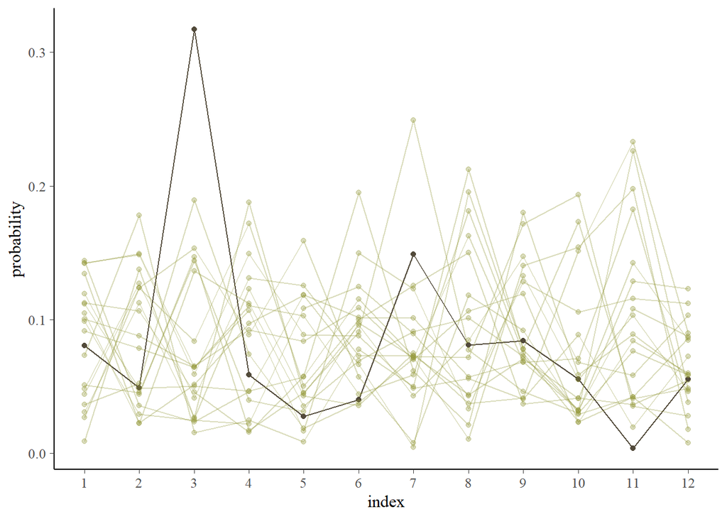

```r
set.seed(8675309)

delta <- rdirichlet(20, alpha = rep(2, 12))
# str(delta)

#n=20 example draws from Dirichlet distribution with alpha=rep(2,12)
# one draw bolded to illustrate variation in a single vector (see McElreath p.393)
delta %>%
  data.frame() %>%
  set_names(1:12) %>%
  mutate(row = 1:n()) %>%
  pivot_longer(-row, names_to = "index") %>%
  mutate(index = as.numeric(index)) %>%

  ggplot(aes(x = index, y = value, group = row,
             alpha = row == 3, color = row == 3)) +
  geom_line() +
  geom_point() +
  scale_alpha_manual(values = c(1/3, 1)) +
  scale_color_manual(values = canva_pal("Green fields")(4)[1:2]) +
  scale_x_continuous(breaks = 1:12) +
  ylab("probability") +
  theme(legend.position = "none")
```

**Prior probability distributions for 12 cutpoints**

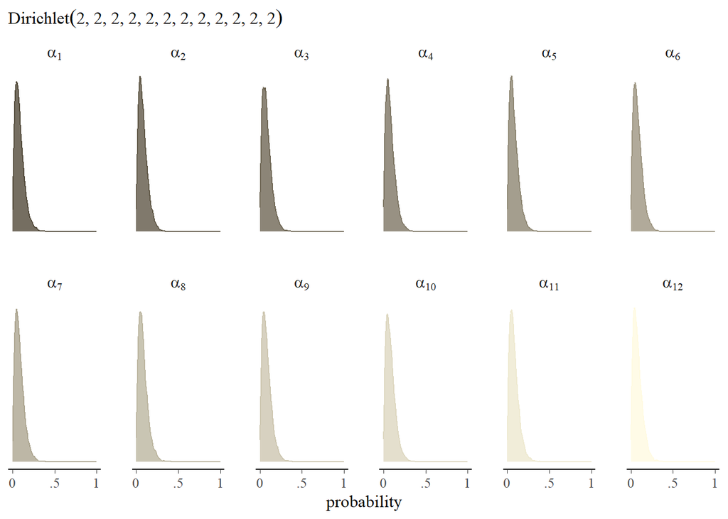

```r
# name2 = factor(name,
#                        levels = unique(name)),
#          name2 = fct_relevel(name,
#                              "1", "2", "3", "4", "5", "6",
#                              "7", "8", "9", "10", "11", "12"),

#prior probability distributions for 12 thresholds
brms::rdirichlet(n = 1e4, alpha = rep(2, 12)) %>%
  data.frame() %>%
  set_names(1:12) %>%
  pivot_longer(everything()) %>%
  mutate(name  = name %>% as.double(),
         alpha = str_c("alpha[", name, "]"),
         alpha = factor(alpha, levels = unique(alpha)) #preserve factor ordering
         ) %>%
  ggplot(aes(x = value, color = name, group = name, fill= name)) +
  geom_density(alpha = .8) +
  scale_fill_gradient(low = canva_pal("Green fields")(4)[2],
                      high = canva_pal("Green fields")(4)[3]) +
  scale_color_gradient(low = canva_pal("Green fields")(4)[2],
                       high = canva_pal("Green fields")(4)[3]) +
  scale_x_continuous("probability", limits = c(0, 1),
                     breaks = c(0, .5, 1), labels = c("0", ".5", "1"), ) +
  scale_y_continuous(NULL, breaks = NULL) +
  labs(subtitle = expression("Dirichlet"*(2*", "*2*", "*2*", "*2*", "*2*", "*2*", "*2*", "*2*", "*2*", "*2*", "*2*", "*2))) +
  theme(legend.position = "none") +

  facet_wrap(~ alpha, labeller = label_parsed, nrow = 2)
```

Overall, applied to our large sample size, the likelihood should dominate these diffuse priors, resulting in data-driven estimates that are consistent with those that would be generated in a comparable frequentist analysis. Now, let’s move onto the model.

### 6.7 M1 (Bivariate): Ord~Ord (sexvicsumf by moSRPAf)

```r
#Ordinal cumulative probit model of sexual victimization index
#with ordinal (monotonic cumulative probit) SRPA predictor

datv3tmp <- datv3 %>%
  mutate(
    SRPAf = SRPA1 + SRPA2,
    SRPAf = factor(SRPAf, ordered = T)
  )
# levels(datv3tmp$SRPAf)

# set priors:
# equal likelihood for all outcome thresholds
# weakly informative normal(0,1) for default beta


#13 SRPA response categories = 12 thresholds
# so, beta prior (0,1) equiv to (0,[1/12]) or (0,.083)

priors3 = c(
  prior(normal(-0.84, 1), class = Intercept, coef = 1),
  prior(normal(-0.25, 1), class = Intercept, coef = 2),
  prior(normal(0.25, 1), class = Intercept, coef = 3),
  prior(normal(0.84, 1), class = Intercept, coef = 4),
  prior(normal(0, 1), class = b),
  prior(normal(0, 0.083), class = b, coef = moSRPAf),
  prior(dirichlet(2, 2, 2, 2, 2, 2, 2, 2, 2, 2, 2, 2), class = simo, coef = moSRPAf1)
)

#sexvicsum - bivariate sexvicsum by mo(SRPAf):
mod3mo <-
  brm(data = datv3tmp,
      family = cumulative("probit"),
      sexvicsumf ~ 1 + mo(SRPAf),
      # prior(normal(0, 4), class = Intercept), #see kruschke/kurtz re: priors for this model
      prior = priors3,
      iter = 2000, warmup = 1000,
      chains = 4,
      cores = nCoresphys,
        backend = "cmdstanr",
        # threads = threading(2), #consider within-chain threading if machine has at least 8 physical cores
      seed = 8675309,
      file = "Models/mod3mo_fit",
      file_refit = "on_change"
      )
```

**Coefficient plot (moSRPAf)**

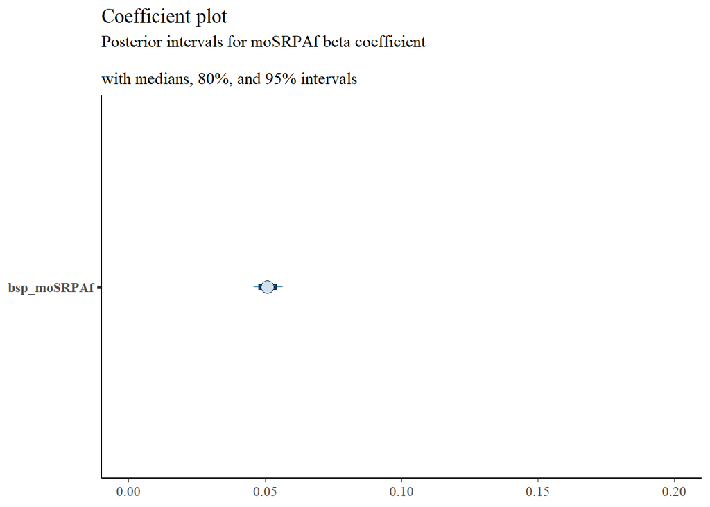

```r
post3mo <- as.matrix(mod3mo)

mcmc_intervals(
  post3mo,
  regex_pars = "bsp_moSRPAf",
  prob = 0.8, # 80% intervals
  prob_outer = 0.95, # 95%
  point_est = "median",
) +
  xlim(0, .2) +
  labs(title = "Coefficient plot",
       subtitle = "Posterior intervals for moSRPAf beta coefficient
       \nwith medians, 80%, and 95% intervals")
```

**Conditional effects (continuous y)**

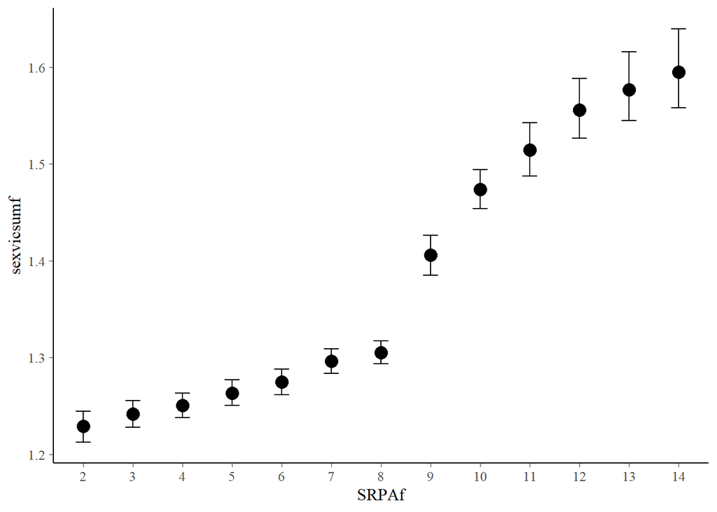

```r
conditional_effects(mod3mo, "SRPAf")
```

**Conditional effects (by y category)**

```r
conditional_effects(mod3mo, "SRPAf", categorical=TRUE)
```

[output not shown]

**PPcheck(density)**

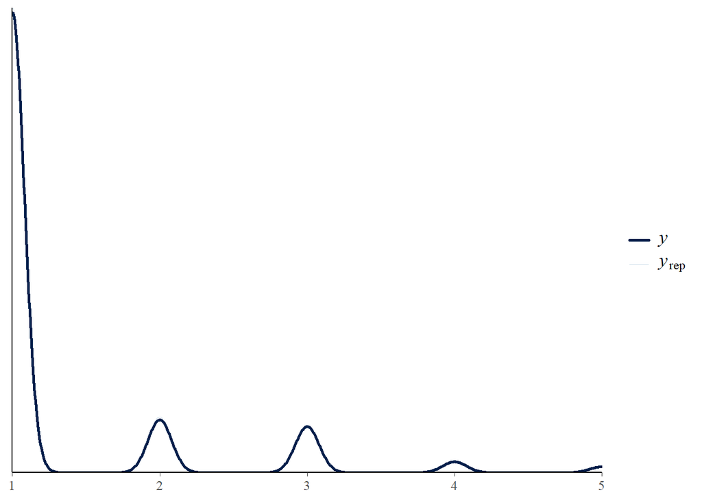

```r
pp_check(mod3mo)
```

**PPcheck (bars)**

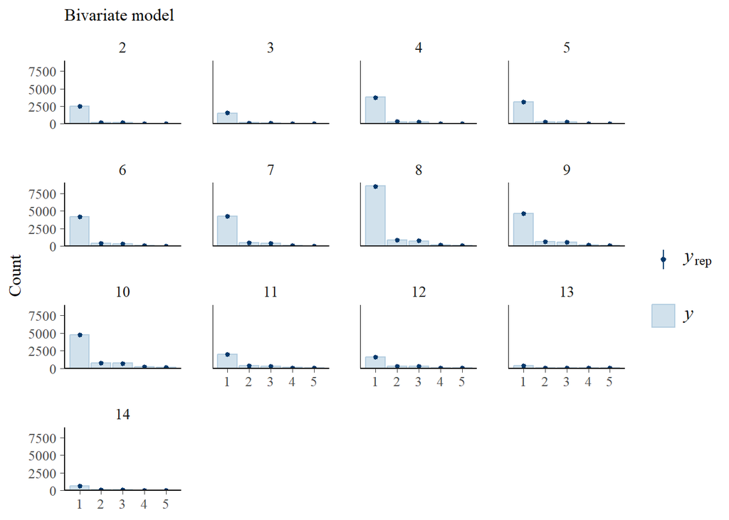

```r
pp_check(
  mod3mo,
  type = "bars_grouped",
  group = "SRPAf",
  ndraws = 1000,
  linewidth = 1/2,
  size = 1/4) +
  labs(subtitle = "Bivariate model")
```

**Fit summary**

```r
summary(mod3mo, probs = c(0.025, 0.975), digits = 2) #summarize results
```

```
 Family: cumulative
  Links: mu = probit; disc = identity
Formula: sexvicsumf ~ 1 + mo(SRPAf)
   Data: datv3tmp (Number of observations: 52191)
  Draws: 4 chains, each with iter = 2000; warmup = 1000; thin = 1;
         total post-warmup draws = 4000

Regression Coefficients:
             Estimate Est.Error l-95% CI u-95% CI Rhat Bulk_ESS Tail_ESS
Intercept[1]     1.08      0.02     1.05     1.13 1.00     4225     3048
Intercept[2]     1.48      0.02     1.44     1.52 1.00     4368     2616
Intercept[3]     2.16      0.02     2.11     2.20 1.00     4788     2799
Intercept[4]     2.59      0.03     2.54     2.64 1.00     4920     2739
moSRPAf          0.05      0.00     0.05     0.06 1.00     4799     3218

Monotonic Simplex Parameters:
             Estimate Est.Error l-95% CI u-95% CI Rhat Bulk_ESS Tail_ESS
moSRPAf1[1]      0.05      0.03     0.01     0.11 1.00     4229     2501
moSRPAf1[2]      0.03      0.02     0.00     0.08 1.00     5951     2804
moSRPAf1[3]      0.05      0.03     0.01     0.11 1.00     4592     2125
moSRPAf1[4]      0.04      0.02     0.01     0.09 1.00     4847     2401
moSRPAf1[5]      0.07      0.03     0.02     0.13 1.00     4716     2316
moSRPAf1[6]      0.03      0.02     0.00     0.07 1.00     4744     2302
moSRPAf1[7]      0.29      0.04     0.22     0.37 1.00     6008     2884
moSRPAf1[8]      0.17      0.04     0.10     0.24 1.00     5966     2607
moSRPAf1[9]      0.09      0.04     0.03     0.17 1.00     4312     2286
moSRPAf1[10]     0.09      0.04     0.02     0.17 1.00     4326     2394
moSRPAf1[11]     0.04      0.03     0.01     0.11 1.00     5244     2476
moSRPAf1[12]     0.04      0.02     0.01     0.09 1.00     5297     2584

Further Distributional Parameters:
     Estimate Est.Error l-95% CI u-95% CI Rhat Bulk_ESS Tail_ESS
disc     1.00      0.00     1.00     1.00   NA       NA       NA

Draws were sampled using sample(hmc). For each parameter, Bulk_ESS
and Tail_ESS are effective sample size measures, and Rhat is the potential
scale reduction factor on split chains (at convergence, Rhat = 1).
```

**Prior summary**

```r
prior_summary(mod3mo) #check priors
```

```
                                         prior     class     coef group resp
                                  normal(0, 1)         b
                              normal(0, 0.083)         b  moSRPAf
                          student_t(3, 0, 2.5) Intercept
                              normal(-0.84, 1) Intercept        1
                              normal(-0.25, 1) Intercept        2
                               normal(0.25, 1) Intercept        3
                               normal(0.84, 1) Intercept        4
 dirichlet(2, 2, 2, 2, 2, 2, 2, 2, 2, 2, 2, 2)      simo moSRPAf1
 dpar nlpar lb ub  source
                     user
                     user
                  default
                     user
                     user
                     user
                     user
                     user
```

Again, posterior predictive checks confirm that a cumulative probit response model fits the ordinal outcome data quite well.

A primary reason to specify a cumulative probit link to model monotonic effects of the ordinal independent variable (SRPA) is that the equidistant category assumption underlying traditional metric modeling approaches render estimates that are insensitive to (i.e., average over) potentially important differences in effects across crude or discrete ordinal categories. One practical consequence may be downwardly biased coefficients or misspecification of nonlinear effects. In this case, compare the “conditional effects” plots (see tabs above) from this model with those generated by the previous (“Ord-Lin”) model. The conditional effects plot from this fully ordinal bivariate model reveals that increased victimization risks emerge primarily at the upper range of SRPA scores (e.g., >8 on the ordinal scale ranging from 2 to 14). Interestingly, examination of the conditional effects plot also reveals that increased victimization risks emerge primarily at the upper range of SRPA scores (e.g., >8 on the ordinal scale ranging from 2 to 14). This is lower than the 95th-percentile threshold suggested by Savolainen and colleagues (i.e., the 95th percentile is a score of 12 on the 2 to 14 scale), though the pattern is consistent with their expectation that increased victimization risks should be observed at the highest ranges of physical attractiveness scales.

The beta coefficient in this model represents the average monotonic effect of a one-category increase in a summed SRPA scale (ranging from “2” to “14”) on latent victimization. We could multiply the beta by the number of SRPA thresholds (x12) to estimate the “maximum” effect on the latent victimization scale.

Instead, to improve interpretation and better match our estimates to the ordinal outcome variable, I will estimate predicted probabilities and contrasts between the minimum and maximum SRPA categories for each of the victimization response categories.

#### 6.7.1 FIG3: Visualize max moSRPA effect by response category (mod3mo)

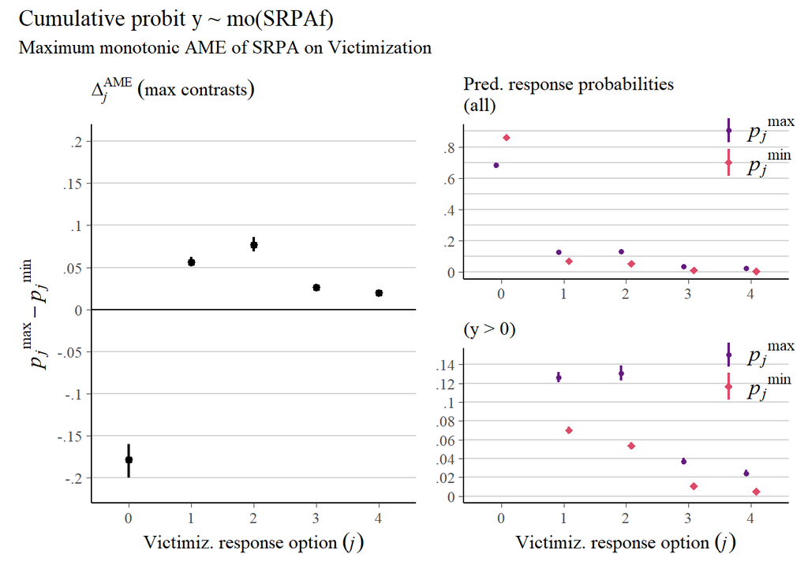

```r
#contrasts by response category

# define the predictor grid
ndmo <- tibble(SRPAf = c("2","14"))

# compute and save
fit3mo_conditional_probabilities_by_group <- ndmo %>%
  add_epred_draws(mod3mo) %>%
  ungroup() %>%
  mutate(SRPAf = if_else(SRPAf=="2", "min", "max"))

# show the first 6 rows
# fit3_conditional_probabilities_by_group %>%
#   head()

#use fitted + epred workflow
mod3mopred <- fit3mo_conditional_probabilities_by_group %>%
  group_by(SRPAf, .category) %>%
  summarise(p = mean(.epred),
            sd = sd(.epred),
            ll = quantile(.epred, probs = .025),
            ul = quantile(.epred, probs = .975)) %>%
  data.frame() %>%
  mutate(SRPAf = ifelse(SRPAf == "min", "italic(p[j])^min", "italic(p[j])^max"))

#function to find & drop leading zeroes (used for x-axis label)
dropLeadingZero <- function(l){
  str_replace(l, '0(?=.)', '')
}

#full range of y responses (0:4)
mod3mop1 <- mod3mopred %>%
  ggplot(aes(x = .category, y = p, ymin = ll, ymax = ul,
             color = SRPAf)) +
  geom_hline(yintercept = 0:9 / 10, color = "lightgrey") +
  geom_linerange(linewidth = 3/4, position = position_dodge(width = 1/3)) +
  geom_point(aes(shape = SRPAf),
             position = position_dodge(width = 1/3),
             size = 2) +
  scale_color_viridis_d(NULL, option = "magma", begin = .3, end = .6,
                        labels = scales::parse_format()) +
  scale_shape_manual(NULL, values = c(20, 18),
                     labels = scales::parse_format()) +
  scale_y_continuous(limits = c(0, .9), breaks=seq(0, .9, by = .2),
                     labels = dropLeadingZero) +
  labs(subtitle = "Pred. response probabilities\n(all)") +
  theme(legend.background = element_blank(),
        legend.position = c(0.9, 0.85),
        legend.key.height= unit(.5, 'cm'),
        legend.key.width= unit(.5, 'cm'),
        legend.title = element_text(size=14),
        legend.text=element_text(size=14),
        axis.title.y = element_blank(),
        axis.title.x = element_blank())

#nonzero victimization values only (1:4)
mod3mop2 <- mod3mopred %>%
  # dplyr::filter(.category != 0) %>%
  ggplot(aes(x = .category, y = p, ymin = ll, ymax = ul,
             color = SRPAf)) +
  geom_hline(yintercept = 0:7 / 50, color = "lightgrey") +
  geom_linerange(linewidth = 3/4, position = position_dodge(width = 1/3)) +
  geom_point(aes(shape = SRPAf),
             position = position_dodge(width = 1/3),
             size = 2) +
  scale_color_viridis_d(NULL, option = "magma", begin = .3, end = .6,
                        labels = scales::parse_format()) +
  scale_shape_manual(NULL, values = c(20, 18),
                     labels = scales::parse_format()) +
  scale_y_continuous(limits = c(0, .15), breaks=seq(0, .14, by = .02),
                     labels = dropLeadingZero) +
  labs(subtitle = "(y > 0)",
       x = expression(Victimiz.~response~option~(italic(j)))) +
  theme(legend.background = element_blank(),
        legend.position = c(0.9, 0.85),
        legend.key.height= unit(.5, 'cm'),
        legend.key.width= unit(.5, 'cm'),
        legend.title = element_text(size=14),
        legend.text=element_text(size=14),
        axis.title.y = element_blank()
        )

# contrasts (alt method not working - data type error)
# p2 <- comparisons(mod3, newdata = nd, by = "group")

# contrasts
mod3mocon <- fit3mo_conditional_probabilities_by_group %>%
  dplyr::select(SRPAf, .draw, .category, .epred) %>%
  pivot_wider(names_from = SRPAf, values_from = .epred) %>%
  mutate(`max - min` = `max` - `min`) %>%
  # now summarize the category-level probabilities, by SRPA
  group_by(.category) %>%
  summarise(p = mean(`max - min`),
            sd = sd(`max - min`),
            ll = quantile(`max - min`, probs = .025),
            ul = quantile(`max - min`, probs = .975)) %>%
data.frame()

mod3mop3 <- mod3mocon %>%
  ggplot(aes(x = .category, y = p, ymin = ll, ymax = ul)) +
  geom_hline(yintercept = -4:4 / 20, color = "lightgrey") +
  geom_hline(yintercept = 0, color = "black") +
  geom_pointrange(linewidth = 3/4, size = 1/3) +
  scale_y_continuous(expression(italic(p[j])^max-italic(p[j])^min),
                     limits = c(-0.21, 0.2), breaks=seq(-.2, .2, by = .05),
                     labels = dropLeadingZero) +
  labs(subtitle = expression(Delta[italic(j)]^{AME}~(max~contrasts)),
       x = expression(Victimiz.~response~option~(italic(j)))) +
  theme(
    axis.title.y = element_text(size=14)
  )

# combine and entitle
mod3plot <- ((mod3mop3 | mod3mop1 / mod3mop2)) +
  plot_annotation(title = "Cumulative probit y ~ mo(SRPAf)",
  subtitle = "Maximum monotonic AME of SRPA on Victimization")
mod3plot
```

```r
# ggsave("mod3plot.jpeg", mod3plot, width=9, height=6.5)
```

This is a descriptive bivariate estimate unadjusted for potential measured confounders. Using the same modeling and estimation approach, let’s next add covariates (as metric standardized variables or unordered factors) to adjust for some potential sources of confounding.

### 6.8 M2 (Controls): Ord~Ord (sexvicsumf by moSRPAf)

```r
#Ordinal cumulative probit model of sexual victimization index
#with ordinal (monotonic cumulative probit) SRPA predictor & linear controls

#sexvicsum - bivariate sexvicsum by mo(SRPAf):
mod4mo <-
  brm(data = datv3tmp,
      family = cumulative("probit"),
      sexvicsumf ~ 1 + mo(SRPAf) + SRintelz + SRpopularz + agez + worked + gender,
      prior = priors3,
      iter = 2000, warmup = 1000,
      chains = 4,
      cores = nCoresphys,
        backend = "cmdstanr",
        # threads = threading(2), #consider within-chain threading if machine has at least 8 physical cores
      seed = 8675309,
      file = "Models/mod4mo_fit",
      file_refit = "on_change"
      )
```

**Coefficient plot (moSRPAf)**

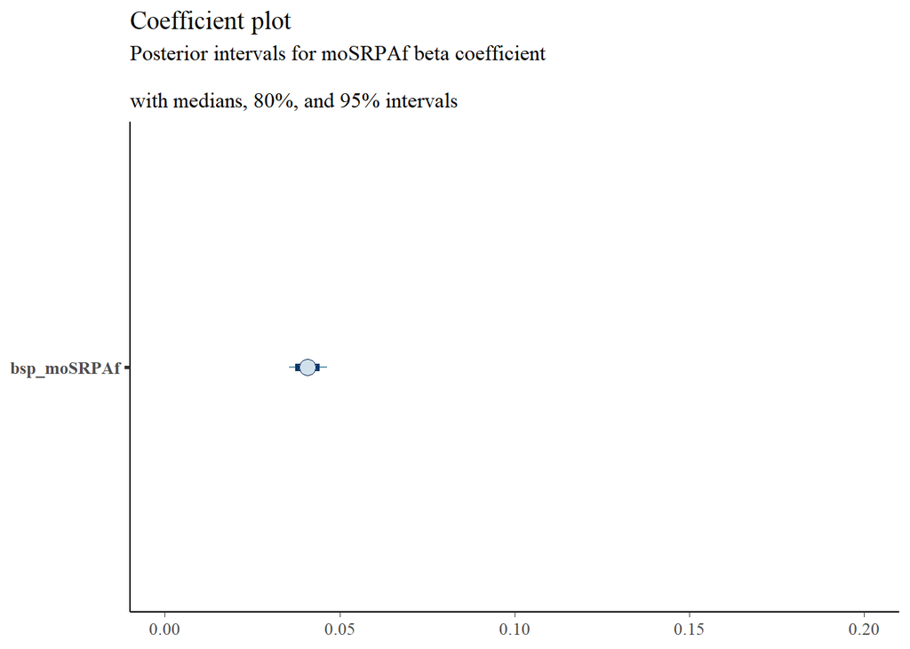

```r
post4mo <- as.matrix(mod4mo)

mcmc_intervals(
  post4mo,
  regex_pars = "bsp_moSRPAf",
  prob = 0.8, # 80% intervals
  prob_outer = 0.95, # 95%
  point_est = "median",
) +
  xlim(0, .2) +
  labs(title = "Coefficient plot",
       subtitle = "Posterior intervals for moSRPAf beta coefficient
       \nwith medians, 80%, and 95% intervals")
```

**Coefficient plot (all)**

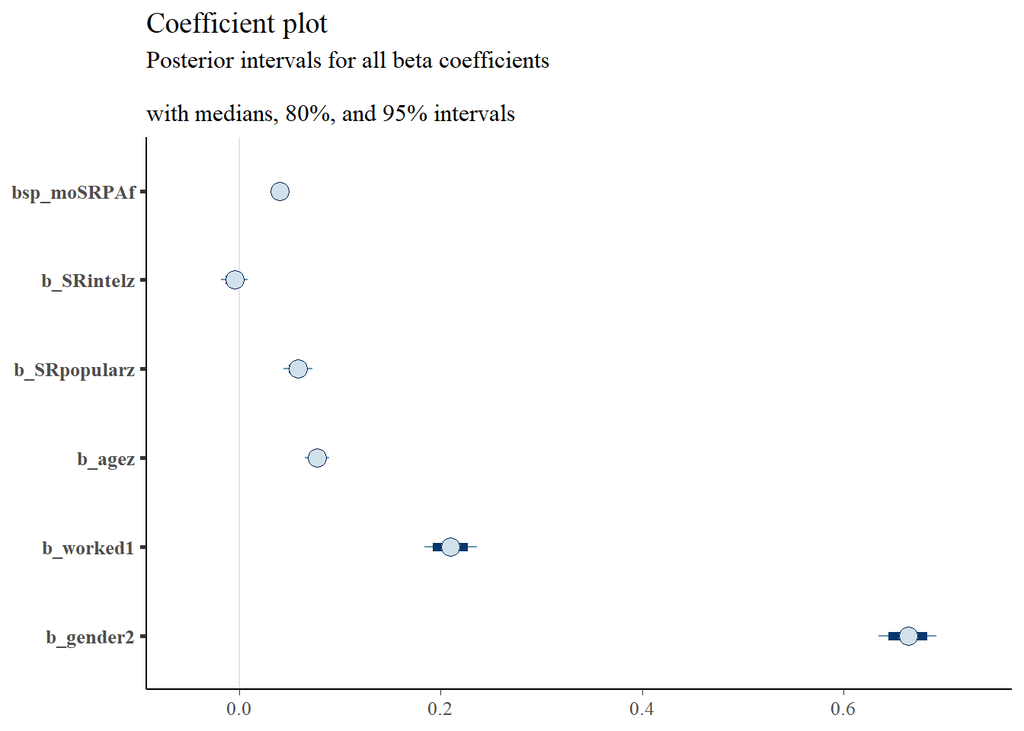

```r
coefgrp <- c("bsp_moSRPAf", "SRintel", "SRpopular",
             "age", "worked", "gender")
mcmc_plot(mod4mo, variable = coefgrp, regex = TRUE,
          prob = 0.80, prob_outer = 0.95) +
  labs(title = "Coefficient plot",
       subtitle = "Posterior intervals for all beta coefficients
       \nwith medians, 80%, and 95% intervals")
```

**Conditional effects (continuous y)**

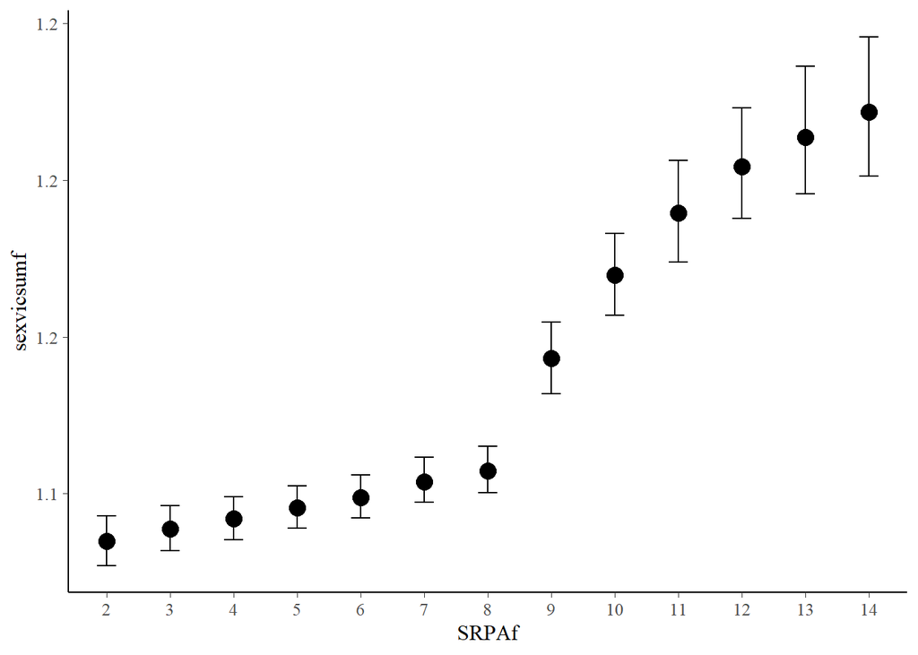

```r
conditional_effects(mod4mo, "SRPAf")
```

**Conditional effects (by y category)**

```r
conditional_effects(mod3mo, "SRPAf", categorical = TRUE)
```

[output not shown]

**Fit summary**

```r
summary(mod4mo, probs = c(0.025, 0.975), digits = 2) #summarize results
```

```
 Family: cumulative
  Links: mu = probit; disc = identity
Formula: sexvicsumf ~ 1 + mo(SRPAf) + SRintelz + SRpopularz + agez + worked + gender
   Data: datv3tmp (Number of observations: 52191)
  Draws: 4 chains, each with iter = 2000; warmup = 1000; thin = 1;
         total post-warmup draws = 4000

Regression Coefficients:
             Estimate Est.Error l-95% CI u-95% CI Rhat Bulk_ESS Tail_ESS
Intercept[1]     1.58      0.02     1.53     1.62 1.00     4519     2873
Intercept[2]     1.99      0.02     1.95     2.04 1.00     4516     2731
Intercept[3]     2.70      0.02     2.65     2.75 1.00     4707     2879
Intercept[4]     3.14      0.03     3.09     3.20 1.00     5297     3137
SRintelz        -0.00      0.01    -0.02     0.01 1.00     6026     3032
SRpopularz       0.06      0.01     0.04     0.07 1.00     5498     2350
agez             0.08      0.01     0.07     0.09 1.00     6132     3016
worked1          0.21      0.01     0.18     0.24 1.00     6672     3190
gender2          0.66      0.01     0.63     0.69 1.00     6023     3220
moSRPAf          0.04      0.00     0.04     0.05 1.00     4431     3034

Monotonic Simplex Parameters:
             Estimate Est.Error l-95% CI u-95% CI Rhat Bulk_ESS Tail_ESS
moSRPAf1[1]      0.04      0.03     0.01     0.11 1.00     4438     2797
moSRPAf1[2]      0.03      0.02     0.01     0.08 1.00     5004     2639
moSRPAf1[3]      0.04      0.02     0.01     0.08 1.00     4112     2290
moSRPAf1[4]      0.03      0.02     0.00     0.08 1.00     5110     2208
moSRPAf1[5]      0.05      0.03     0.01     0.11 1.00     4770     2227
moSRPAf1[6]      0.03      0.02     0.00     0.08 1.00     4561     2066
moSRPAf1[7]      0.29      0.05     0.21     0.38 1.00     5178     3332
moSRPAf1[8]      0.18      0.05     0.09     0.28 1.00     4640     2746
moSRPAf1[9]      0.12      0.05     0.03     0.21 1.00     4115     2204
moSRPAf1[10]     0.08      0.04     0.02     0.18 1.00     4436     2550
moSRPAf1[11]     0.05      0.03     0.01     0.13 1.00     5175     2783
moSRPAf1[12]     0.04      0.03     0.01     0.10 1.00     5354     2720

Further Distributional Parameters:
     Estimate Est.Error l-95% CI u-95% CI Rhat Bulk_ESS Tail_ESS
disc     1.00      0.00     1.00     1.00   NA       NA       NA

Draws were sampled using sample(hmc). For each parameter, Bulk_ESS
and Tail_ESS are effective sample size measures, and Rhat is the potential
scale reduction factor on split chains (at convergence, Rhat = 1).
```

**Prior summary**

```r
prior_summary(mod4mo) #check priors
```

```
                                         prior     class       coef group resp
                                  normal(0, 1)         b
                                  normal(0, 1)         b       agez
                                  normal(0, 1)         b    gender2
                              normal(0, 0.083)         b    moSRPAf
                                  normal(0, 1)         b   SRintelz
                                  normal(0, 1)         b SRpopularz
                                  normal(0, 1)         b    worked1
                          student_t(3, 0, 2.5) Intercept
                              normal(-0.84, 1) Intercept          1
                              normal(-0.25, 1) Intercept          2
                               normal(0.25, 1) Intercept          3
                               normal(0.84, 1) Intercept          4
 dirichlet(2, 2, 2, 2, 2, 2, 2, 2, 2, 2, 2, 2)      simo   moSRPAf1
 dpar nlpar lb ub       source
                          user
                  (vectorized)
                  (vectorized)
                          user
                  (vectorized)
                  (vectorized)
                  (vectorized)
                       default
                          user
                          user
                          user
                          user
                          user
```

#### 6.8.1 Visualize max moSRPA effect by response category (mod4mo)

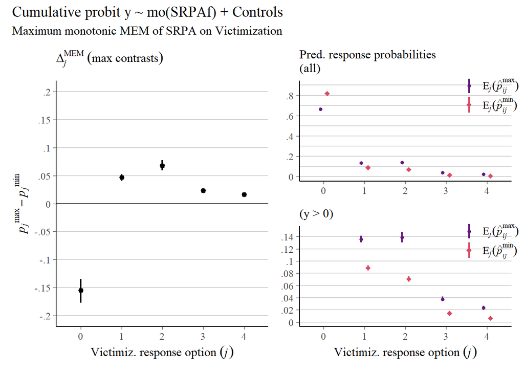

```r
#contrasts by response category

# update the data grid
# ndmo_id <- datv3tmp %>%
#   mutate(id = 1:n()) %>%
#   dplyr::select(id, SRintelz, SRpopularz, agez, worked, gender) %>%
#   expand_grid(SRPAf = c("2","14")) %>%
#   mutate(row = 1:n())

# conditional probabilities (marginaleffects workflow - fixed matrix issue)
# mod4mopred <- avg_predictions(mod4mo, newdata = ndmo_id,
#                               by = c("SRPAf", "group")) %>%
#   data.frame() %>%
#   mutate(SRPAf = ifelse(SRPAf == "2", "E[italic(j)](hat(italic(p))[italic(ij)]^min)", "E[italic(j)](hat(italic(p))[italic(ij)]^max)"))


#method above for aap are too computationally intensive
# see here: https://marginaleffects.com/vignettes/performance.html

# One option is to limit variables averaged over. E.g.,

# predictions(
#     mod4mo,
#     type = "response",
#     by = "SRPAf",
#     datagrid(SRPAf = c("2","14")),
#     variables = c("SRintelz", "SRpopularz", "agez"))

# For now, I am opting to estimate adjusted predictions at mean (apm) instead

mod4mopred <- predictions(mod4mo, newdata = datagrid(SRPAf = c("2","14")), by = c("SRPAf","group")) %>%
  data.frame() %>%
  mutate(SRPAf = ifelse(SRPAf == "2", "E[italic(j)](hat(italic(p))[italic(ij)]^min)", "E[italic(j)](hat(italic(p))[italic(ij)]^max)"))

#function to find & drop leading zeroes (used for x-axis label)
dropLeadingZero <- function(l){
  str_replace(l, '0(?=.)', '')
}

#full range of y responses (0:4)
mod4mop1 <- mod4mopred %>%
  ggplot(aes(x = group, y = estimate, ymin = conf.low, ymax = conf.high,
             color = SRPAf)) +
  geom_hline(yintercept = 0:9 / 10, color = "lightgrey") +
  geom_linerange(linewidth = 3/4, position = position_dodge(width = 1/3)) +
  geom_point(aes(shape = SRPAf),
             position = position_dodge(width = 1/3),
             size = 2) +
  scale_color_viridis_d(NULL, option = "magma", begin = .3, end = .6,
                        labels = scales::parse_format()) +
  scale_shape_manual(NULL, values = c(20, 18),
                     labels = scales::parse_format()) +
  scale_y_continuous(limits = c(0, .9), breaks=seq(0, .9, by = .2),
                     labels = dropLeadingZero) +
  labs(subtitle = "Pred. response probabilities\n(all)") +
  theme(legend.background = element_blank(),
        legend.position = c(0.9, 0.85),
        legend.key.height= unit(.5, 'cm'),
        legend.key.width= unit(.5, 'cm'),
        legend.title = element_text(size=10),
        legend.text=element_text(size=10),
        axis.title.y = element_blank(),
        axis.title.x = element_blank())

#nonzero victimization values only (1:4)
mod4mop2 <- mod4mopred %>%
  # dplyr::filter(group != 0) %>%
  ggplot(aes(x = group, y = estimate, ymin = conf.low, ymax = conf.high,
             color = SRPAf)) +
  geom_hline(yintercept = 0:7 / 50, color = "lightgrey") +
  geom_linerange(linewidth = 3/4, position = position_dodge(width = 1/3)) +
  geom_point(aes(shape = SRPAf),
             position = position_dodge(width = 1/3),
             size = 2) +
  scale_color_viridis_d(NULL, option = "magma", begin = .3, end = .6,
                        labels = scales::parse_format()) +
  scale_shape_manual(NULL, values = c(20, 18),
                     labels = scales::parse_format()) +
  scale_y_continuous(limits = c(0, .15), breaks=seq(0, .14, by = .02),
                     labels = dropLeadingZero) +
  labs(subtitle = "(y > 0)",
       x = expression(Victimiz.~response~option~(italic(j)))) +
  theme(legend.background = element_blank(),
        legend.position = c(0.9, 0.85),
        legend.key.height= unit(.5, 'cm'),
        legend.key.width= unit(.5, 'cm'),
        legend.title = element_text(size=10),
        legend.text=element_text(size=10),
        axis.title.y = element_blank()
        )

# contrasts (marginaleffects workflow - fixed matrix issue)
# also too computationally intensive
# mod4mocon <- avg_comparisons(mod4mo, variables = "SRPAf") %>%
#   data.frame()

# estimate contrasts at means

mod4mocon <- comparisons(mod4mo, variables = list(SRPAf = c("2","14")),
newdata = "mean", by = "group") %>%
  data.frame()


mod4mop3 <- mod4mocon %>%
  ggplot(aes(x = group, y = estimate, ymin = conf.low, ymax = conf.high)) +
  geom_hline(yintercept = -4:4 / 20, color = "lightgrey") +
  geom_hline(yintercept = 0, color = "black") +
  geom_pointrange(linewidth = 3/4, size = 1/3) +
  scale_y_continuous(expression(italic(p[j])^max-italic(p[j])^min),
                     limits = c(-0.2, 0.2), breaks=seq(-.2, .2, by = .05),
                     labels = dropLeadingZero) +
  labs(subtitle = expression(Delta[italic(j)]^{MEM}~(max~contrasts)),
       x = expression(Victimiz.~response~option~(italic(j))))

# combine and entitle
((mod4mop3 | mod4mop1 / mod4mop2)) +
  plot_annotation(title = "Cumulative probit y ~ mo(SRPAf) + Controls",
  subtitle = "Maximum monotonic MEM of SRPA on Victimization")
```

After adjusting for these covariates, the SRPAf coefficient shrinks slightly (from 0.05 to 0.04).

Also, as expected, the beta coefficient for gender shows girls report substantially more sexual victimization experiences than boys. Likewise, it will be important to interact SRPAf with gender later to explore possible heterogeneity in predicted probabilities and contrasts.

Unfortunately, estimating average predictions and contracts marginalized across all covariates from these ordinal models with a large (~50k) dataset is too computationally intensive; doing so bogged down my computer and resulted in multiple crashes. For now, I’ve settled on the much more computationally efficient yet somewhat less interpretable marginal effects at means (MEM) instead to generate predictions and contrasts by response category in models with covariates. Like the beta coefficient, the estimated maximum contrast is slightly smaller (-0.154 versus -0.178 from Bivariate model). However, as the predicted probabilities are estimated at the means and not averaged over all covariate values, these estimates are not directly comparable.

For now, let’s adjust for “nlp” as an ordinal variable with a cumulative monotonic effect on victimization and compare the MEM contrast.

Before we do, now might be a good time to formalize the “full” (Controls + NLP) Model 3 in equation form. For more information about these models and specifications, see previous links to Kurz’s blog and bookdowns; Bürkner’s papers, & McElreath’s *Statistical Rethinking*.

$$\begin{align*} \text{victimiz}_i & \sim \operatorname{Cumulative}(\mathbf p, \mu_i, \alpha) \\ p_j & = \Phi(\tau_j) \\ \mu_i & = 0 + \beta_1 \text{mo(SRPA}_i,\delta_1) + \beta_2 \text{mo(NLP}_i,\delta_2)) + \beta_3 \text{Covariate}_{3i} + \beta_K \text{Covariate}_{Ki}\\ \alpha & = 1 \\ \tau_1 & \sim \operatorname{Normal}(-0.84, 1) \\ \tau_2 & \sim \operatorname{Normal}(-0.25, 1) \\ \tau_3 & \sim \operatorname{Normal}(0.25, 1) \\ \tau_4 & \sim \operatorname{Normal}(0.84, 1) \\ \beta_1 & \sim \operatorname{Normal}(0, 0.083) \\ \beta_2 & \sim \operatorname{Normal}(0, 0.11) \\ \beta_3, \dots, \beta_k & \sim \operatorname{Normal}(0, 1) \\ \delta_1 & \sim \operatorname{Dirichlet}(2,2,2,2,2,2,2,2,2,2,2,2) \\ \delta_2 & \sim \operatorname{Dirichlet}(2,2,2,2,2,2,2,2,2) \end{align*}$$

### 6.9 M3 (NLP): Ord~Ord (sexvicsumf by moSRPAf)

```r
#Ordinal cumulative probit model of sexual victimization index
#with ordinal (monotonic cumulative probit) SRPA predictor, linear controls, & mo(nlp)

#10 nlp response categories = 9 thresholds
# so, beta prior (0,1) equiv to (0,[1/9]) or (0,.11)

priors4 = c(
  prior(normal(-0.84, 1), class = Intercept, coef = 1),
  prior(normal(-0.25, 1), class = Intercept, coef = 2),
  prior(normal(0.25, 1), class = Intercept, coef = 3),
  prior(normal(0.84, 1), class = Intercept, coef = 4),
  prior(normal(0, 1), class = b),
  prior(normal(0, 0.083), class = b, coef = moSRPAf),
  prior(normal(0, 0.11), class = b, coef = monlpf),
  prior(dirichlet(2, 2, 2, 2, 2, 2, 2, 2, 2, 2, 2, 2), class = simo, coef = moSRPAf1),
  prior(dirichlet(2, 2, 2, 2, 2, 2, 2, 2, 2), class = simo, coef = monlpf1)
)

#sexvicsum - bivariate sexvicsum by mo(SRPAf):
mod5mo <-
  brm(data = datv3tmp,
      family = cumulative("probit"),
      sexvicsumf ~ 1 + mo(SRPAf) + mo(nlpf) + SRintelz + SRpopularz + agez + worked + gender,
      prior = priors4,
      iter = 2000, warmup = 1000,
      chains = 4,
      cores = nCoresphys,
        backend = "cmdstanr",
        # threads = threading(2), #consider within-chain threading if machine has at least 8 physical cores
      seed = 8675309,
      file = "Models/mod5mo_fit",
      file_refit = "on_change"
      )
```

**Coefficient plot (moSRPAf)**

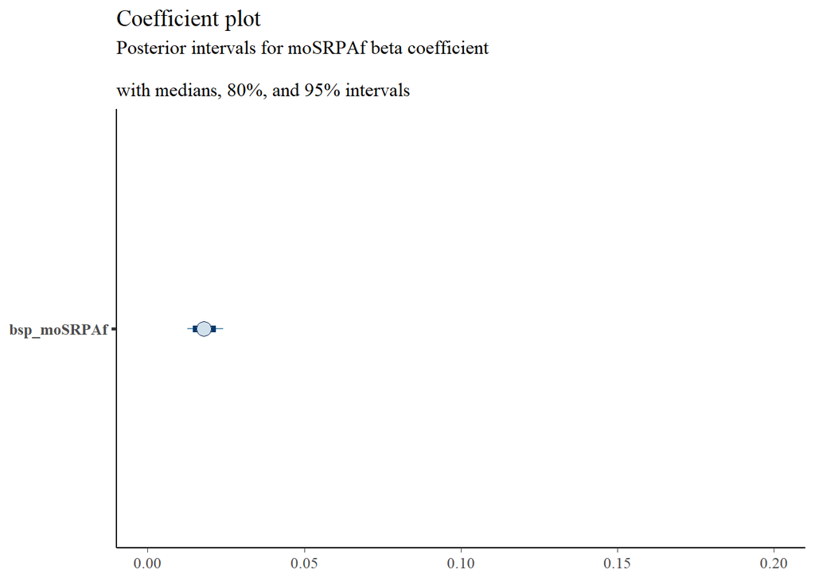

```r
post5mo <- as.matrix(mod5mo)

mcmc_intervals(
  post5mo,
  regex_pars = "bsp_moSRPAf",
  prob = 0.8, # 80% intervals
  prob_outer = 0.95, # 95%
  point_est = "median",
) +
  xlim(0, .2) +
  labs(title = "Coefficient plot",
       subtitle = "Posterior intervals for moSRPAf beta coefficient
       \nwith medians, 80%, and 95% intervals")
```

**Coefficient plot (all)**

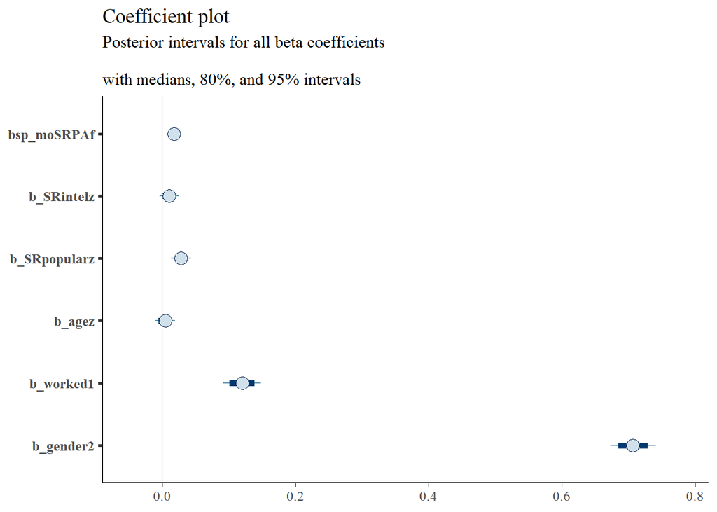

```r
coefgrp <- c("bsp_moSRPAf", "SRintel", "SRpopular",
             "age", "worked", "gender")
mcmc_plot(mod5mo, variable = coefgrp, regex = TRUE,
          prob = 0.80, prob_outer = 0.95) +
  labs(title = "Coefficient plot",
       subtitle = "Posterior intervals for all beta coefficients
       \nwith medians, 80%, and 95% intervals")
```

**Conditional effects (continuous y)**

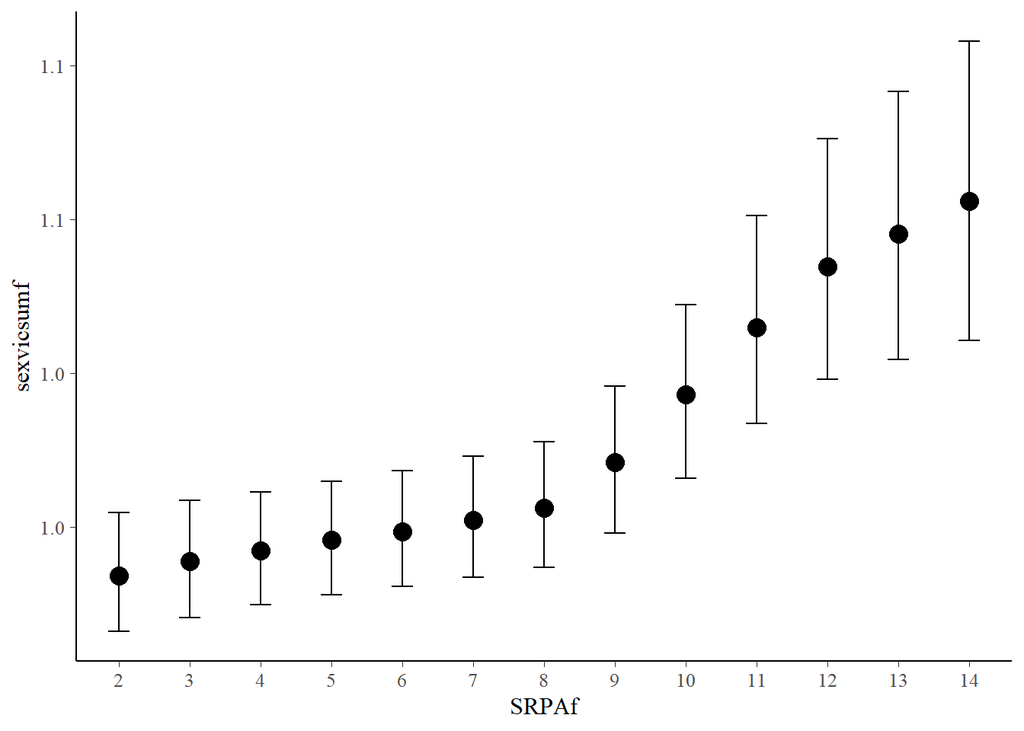

```r
conditional_effects(mod5mo, "SRPAf")
```

**Conditional effects (by y category)**

```r
conditional_effects(mod3mo, "SRPAf", categorical = TRUE)
```

[output not shown]

**Fit summary**

```r
summary(mod5mo, probs = c(0.025, 0.975), digits = 2) #summarize results
```

```
 Family: cumulative
  Links: mu = probit; disc = identity
Formula: sexvicsumf ~ 1 + mo(SRPAf) + mo(nlpf) + SRintelz + SRpopularz + agez + worked + gender
   Data: datv3tmp (Number of observations: 47532)
  Draws: 4 chains, each with iter = 2000; warmup = 1000; thin = 1;
         total post-warmup draws = 4000

Regression Coefficients:
             Estimate Est.Error l-95% CI u-95% CI Rhat Bulk_ESS Tail_ESS
Intercept[1]     1.92      0.02     1.88     1.97 1.00     4929     2992
Intercept[2]     2.37      0.02     2.33     2.42 1.00     5161     3154
Intercept[3]     3.17      0.03     3.12     3.22 1.00     5543     2919
Intercept[4]     3.63      0.03     3.57     3.69 1.00     6254     3228
SRintelz         0.01      0.01    -0.00     0.02 1.00     7043     3182
SRpopularz       0.03      0.01     0.01     0.04 1.00     6464     3178
agez             0.00      0.01    -0.01     0.02 1.00     6943     2841
worked1          0.12      0.01     0.09     0.15 1.00     7563     3149
gender2          0.71      0.02     0.67     0.74 1.00     6666     2534
moSRPAf          0.02      0.00     0.01     0.02 1.00     5527     3481
monlpf           0.12      0.00     0.11     0.13 1.00     4410     2881

Monotonic Simplex Parameters:
             Estimate Est.Error l-95% CI u-95% CI Rhat Bulk_ESS Tail_ESS
moSRPAf1[1]      0.05      0.03     0.01     0.12 1.00     5602     2755
moSRPAf1[2]      0.04      0.03     0.00     0.10 1.00     5451     2458
moSRPAf1[3]      0.03      0.02     0.00     0.08 1.00     6095     2136
moSRPAf1[4]      0.03      0.02     0.00     0.08 1.00     4845     1960
moSRPAf1[5]      0.03      0.02     0.00     0.09 1.00     5627     2555
moSRPAf1[6]      0.04      0.03     0.01     0.10 1.00     5784     2622
moSRPAf1[7]      0.14      0.07     0.03     0.28 1.00     4476     1942
moSRPAf1[8]      0.19      0.08     0.04     0.37 1.00     5191     2408
moSRPAf1[9]      0.17      0.08     0.03     0.34 1.00     5478     2433
moSRPAf1[10]     0.14      0.08     0.02     0.31 1.00     6163     2837
moSRPAf1[11]     0.08      0.05     0.01     0.19 1.00     5509     2626
moSRPAf1[12]     0.07      0.05     0.01     0.18 1.00     5873     2606
monlpf1[1]       0.21      0.02     0.17     0.24 1.00     6135     2989
monlpf1[2]       0.23      0.02     0.18     0.27 1.00     5591     3116
monlpf1[3]       0.13      0.03     0.08     0.18 1.00     5418     2651
monlpf1[4]       0.12      0.03     0.06     0.17 1.00     5752     2669
monlpf1[5]       0.04      0.02     0.01     0.09 1.00     4503     2653
monlpf1[6]       0.09      0.03     0.03     0.15 1.00     5805     2877
monlpf1[7]       0.05      0.03     0.01     0.11 1.00     4904     2001
monlpf1[8]       0.06      0.03     0.01     0.12 1.00     5835     2654
monlpf1[9]       0.07      0.04     0.01     0.15 1.00     4636     2939

Further Distributional Parameters:
     Estimate Est.Error l-95% CI u-95% CI Rhat Bulk_ESS Tail_ESS
disc     1.00      0.00     1.00     1.00   NA       NA       NA

Draws were sampled using sample(hmc). For each parameter, Bulk_ESS
and Tail_ESS are effective sample size measures, and Rhat is the potential
scale reduction factor on split chains (at convergence, Rhat = 1).
```

**Prior summary**

```r
prior_summary(mod5mo) #check priors
```

```
                                         prior     class       coef group resp
                                  normal(0, 1)         b
                                  normal(0, 1)         b       agez
                                  normal(0, 1)         b    gender2
                               normal(0, 0.11)         b     monlpf
                              normal(0, 0.083)         b    moSRPAf
                                  normal(0, 1)         b   SRintelz
                                  normal(0, 1)         b SRpopularz
                                  normal(0, 1)         b    worked1
                          student_t(3, 0, 2.5) Intercept
                              normal(-0.84, 1) Intercept          1
                              normal(-0.25, 1) Intercept          2
                               normal(0.25, 1) Intercept          3
                               normal(0.84, 1) Intercept          4
          dirichlet(2, 2, 2, 2, 2, 2, 2, 2, 2)      simo    monlpf1
 dirichlet(2, 2, 2, 2, 2, 2, 2, 2, 2, 2, 2, 2)      simo   moSRPAf1
 dpar nlpar lb ub       source
                          user
                  (vectorized)
                  (vectorized)
                          user
                          user
                  (vectorized)
                  (vectorized)
                  (vectorized)
                       default
                          user
                          user
                          user
                          user
                          user
                          user
```

#### 6.9.1 Visualize max moSRPA effect by response category (mod5mo)

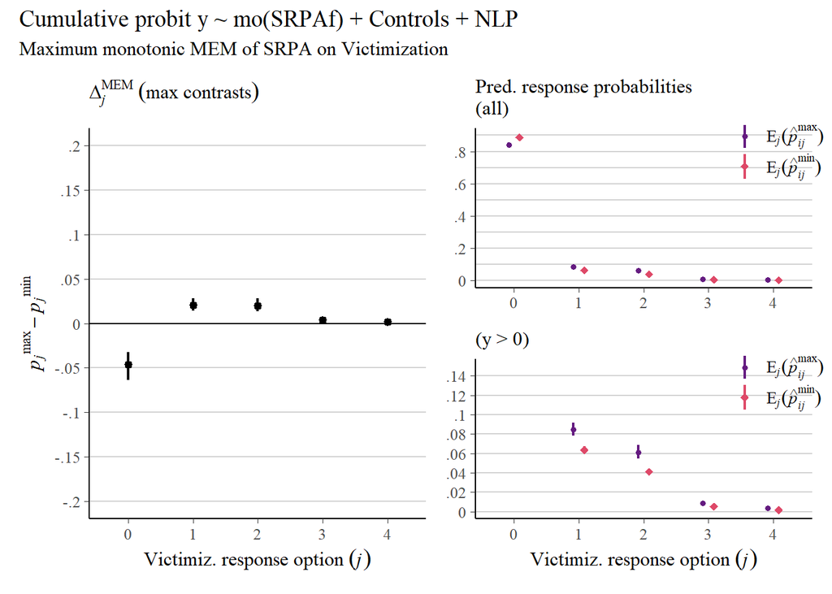

```r
#contrasts by response category

# update the data grid
# ndmo_id <- datv3tmp %>%
#   mutate(id = 1:n()) %>%
#   dplyr::select(id, SRintelz, SRpopularz, agez, worked, gender) %>%
#   expand_grid(SRPAf = c("2","14")) %>%
#   mutate(row = 1:n())

# conditional probabilities (marginaleffects workflow - fixed matrix issue)
# mod5mopred <- avg_predictions(mod5mo, newdata = ndmo_id,
#                               by = c("SRPAf", "group")) %>%
#   data.frame() %>%
#   mutate(SRPAf = ifelse(SRPAf == "2", "E[italic(j)](hat(italic(p))[italic(ij)]^min)", "E[italic(j)](hat(italic(p))[italic(ij)]^max)"))


#method above for aap are too computationally intensive
# see here: https://marginaleffects.com/vignettes/performance.html

# One option is to limit variables averaged over. E.g.,

# predictions(
#     mod5mo,
#     type = "response",
#     by = "SRPAf",
#     datagrid(SRPAf = c("2","14")),
#     variables = c("SRintelz", "SRpopularz", "agez"))

# For now, I am opting to estimate adjusted predictions at mean (apm) instead

mod5mopred <- predictions(mod5mo, newdata = datagrid(SRPAf = c("2","14")), by = c("SRPAf","group")) %>%
  data.frame() %>%
  mutate(SRPAf = ifelse(SRPAf == "2", "E[italic(j)](hat(italic(p))[italic(ij)]^min)", "E[italic(j)](hat(italic(p))[italic(ij)]^max)"))

#function to find & drop leading zeroes (used for x-axis label)
dropLeadingZero <- function(l){
  str_replace(l, '0(?=.)', '')
}

#full range of y responses (0:4)
mod5mop1 <- mod5mopred %>%
  ggplot(aes(x = group, y = estimate, ymin = conf.low, ymax = conf.high,
             color = SRPAf)) +
  geom_hline(yintercept = 0:9 / 10, color = "lightgrey") +
  geom_linerange(linewidth = 3/4, position = position_dodge(width = 1/3)) +
  geom_point(aes(shape = SRPAf),
             position = position_dodge(width = 1/3),
             size = 2) +
  scale_color_viridis_d(NULL, option = "magma", begin = .3, end = .6,
                        labels = scales::parse_format()) +
  scale_shape_manual(NULL, values = c(20, 18),
                     labels = scales::parse_format()) +
  scale_y_continuous(limits = c(0, .9), breaks=seq(0, .9, by = .2),
                     labels = dropLeadingZero) +
  labs(subtitle = "Pred. response probabilities\n(all)") +
  theme(legend.background = element_blank(),
        legend.position = c(0.9, 0.85),
        legend.key.height= unit(.5, 'cm'),
        legend.key.width= unit(.5, 'cm'),
        legend.title = element_text(size=10),
        legend.text=element_text(size=10),
        axis.title.y = element_blank(),
        axis.title.x = element_blank())

#nonzero victimization values only (1:4)
mod5mop2 <- mod5mopred %>%
  # dplyr::filter(group != 0) %>%
  ggplot(aes(x = group, y = estimate, ymin = conf.low, ymax = conf.high,
             color = SRPAf)) +
  geom_hline(yintercept = 0:7 / 50, color = "lightgrey") +
  geom_linerange(linewidth = 3/4, position = position_dodge(width = 1/3)) +
  geom_point(aes(shape = SRPAf),
             position = position_dodge(width = 1/3),
             size = 2) +
  scale_color_viridis_d(NULL, option = "magma", begin = .3, end = .6,
                        labels = scales::parse_format()) +
  scale_shape_manual(NULL, values = c(20, 18),
                     labels = scales::parse_format()) +
  scale_y_continuous(limits = c(0, .15), breaks=seq(0, .14, by = .02),
                     labels = dropLeadingZero) +
  labs(subtitle = "(y > 0)",
       x = expression(Victimiz.~response~option~(italic(j)))) +
  theme(legend.background = element_blank(),
        legend.position = c(0.9, 0.85),
        legend.key.height= unit(.5, 'cm'),
        legend.key.width= unit(.5, 'cm'),
        legend.title = element_text(size=10),
        legend.text=element_text(size=10),
        axis.title.y = element_blank()
        )

# contrasts (marginaleffects workflow - fixed matrix issue)
# also too computationally intensive
# mod5mocon <- avg_comparisons(mod5mo, variables = "SRPAf") %>%
#   data.frame()

# estimate contrasts at means

mod5mocon <- comparisons(mod5mo, variables = list(SRPAf = c("2","14")),
newdata = "mean", by = "group") %>%
  data.frame()


mod5mop3 <- mod5mocon %>%
  ggplot(aes(x = group, y = estimate, ymin = conf.low, ymax = conf.high)) +
  geom_hline(yintercept = -4:4 / 20, color = "lightgrey") +
  geom_hline(yintercept = 0, color = "black") +
  geom_pointrange(linewidth = 3/4, size = 1/3) +
  scale_y_continuous(expression(italic(p[j])^max-italic(p[j])^min),
                     limits = c(-0.2, 0.2), breaks=seq(-.2, .2, by = .05),
                     labels = dropLeadingZero) +
  labs(subtitle = expression(Delta[italic(j)]^{MEM}~(max~contrasts)),
       x = expression(Victimiz.~response~option~(italic(j))))

# combine and entitle
((mod5mop3 | mod5mop1 / mod5mop2)) +
  plot_annotation(title = "Cumulative probit y ~ mo(SRPAf) + Controls + NLP",
  subtitle = "Maximum monotonic MEM of SRPA on Victimization")
```

After adjusting for nlp, the SRPAf coefficient shrinks substantially (0.04 in Controls model to 0.02).

Again, the predicted probabilities are not averaged over all covariate values, so the estimates are not directly comparable (i.e., they are conditional average marginal effects, not average marginal effects). Nonetheless, they do illustrate that stratification on nlp accounts for a substantial portion of the observed association between SRPA and sexual victimization. Recall, the degree to which this overlap represents plausible confounding or mediation processes is unknown.

Later, I estimate indirect effects of SRPA on victimization via nlp to illustrate the inferences we might make under the assumption that a mediation process generated these data.

For now, let’s combine some of these estimates into plots that show how they change across models.

## 7 Combining estimates across models

### 7.1 Comparing beta estimates of SRPA effect on latent victimization

Let’s start by plotting the beta estimates from models without covariates, with covariates, and with nlp (a confounder and/or mediator). Recall, these betas represent effect estimates on a latent continuous response scale.

**Avg (1-category) beta on latent y**

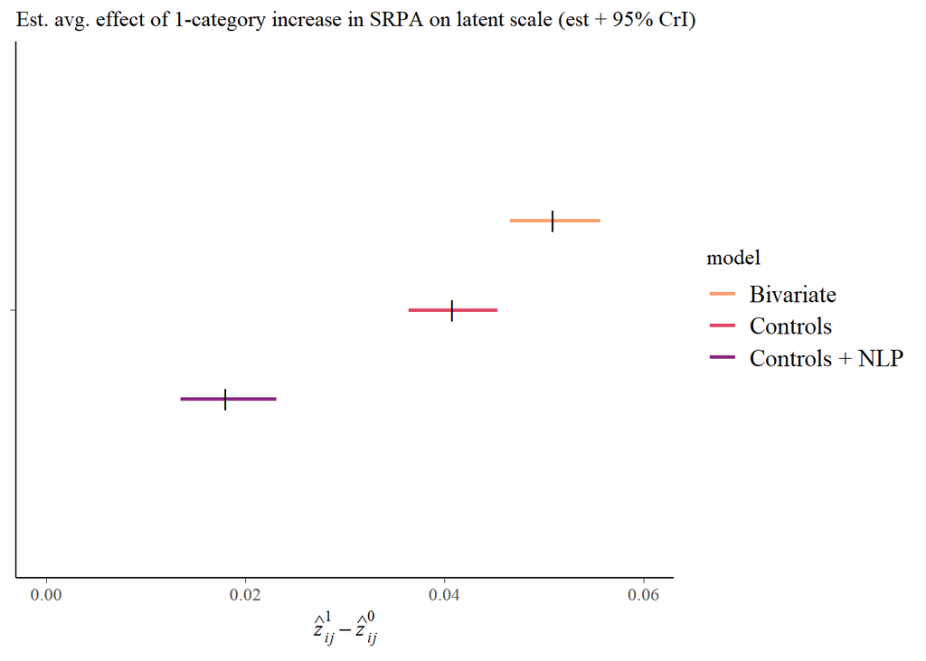

```r
# https://stackoverflow.com/questions/52875665/plotting-posterior-parameter-estimates-from-multiple-models-with-bayesplot
intdat3 <- mcmc_intervals_data(post3mo) %>%
  mutate(model="Bivariate") %>%
  dplyr::filter(parameter=="bsp_moSRPAf")
intdat4 <- mcmc_intervals_data(post4mo) %>%
  mutate(model="Controls") %>%
  dplyr::filter(parameter=="bsp_moSRPAf")
intdat5 <- mcmc_intervals_data(post5mo) %>%
  mutate(model="Controls + NLP") %>%
  dplyr::filter(parameter=="bsp_moSRPAf")

allpost <- rbind(intdat3, intdat4, intdat5) %>%
  mutate(
    model = factor(model, levels = c("Bivariate", "Controls", "Controls + NLP"),
                      ordered = FALSE)
    )

#redo with different factor levels
theme_set(bayesplot::theme_default())
pos <- position_nudge(y = if_else(allpost$model == "Bivariate", .2,
                                 if_else(allpost$model == "Controls", 0, -.2)))
ggplot(allpost, aes(x = m, y = parameter, color=model)) +
  geom_linerange(aes(xmin = ll, xmax = hh), position = pos, size=1) + #95%interval
  geom_point(position = pos, color="black", shape=124, size=4) + #pointestimate
  scale_color_manual(values = c("#FE9F6DFF","#DE4968FF","#8C2981FF")) +
  xlim(0,.06) +
  labs(x=expression(hat(italic(z))[italic(ij)]^1-hat(italic(z))[italic(ij)]^0),
    subtitle = "Est. avg. effect of 1-category increase in SRPA on latent scale (est + 95% CrI)") +
  theme(
    axis.text.y = element_blank(),
    axis.title.y = element_blank()
  )
```

```r
#estimated avg monotonic effect of 1-category increase in SRPA on latent victimization scale
```

**Maximum (max-min category) beta on latent y**

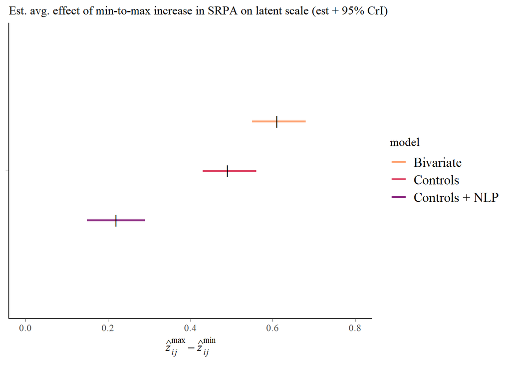

```r
# intdat3 <- mcmc_intervals_data(post3mo) %>%
#   mutate(model="Bivariate") %>%
#   dplyr::filter(parameter=="bsp_moSRPAf") %>%
#   transmute(bE = m * 12)

maxbdat3 <- as_draws_df(post3mo) %>%
  transmute(bE = bsp_moSRPAf * 12) %>%
  median_qi(.width = .95) %>%
  mutate_if(is.double, round, digits = 2) %>%
  mutate(model="Bivariate", parameter="bsp_moSRPAf")

maxbdat4 <- as_draws_df(post4mo) %>%
  transmute(bE = bsp_moSRPAf * 12) %>%
  median_qi(.width = .95) %>%
  mutate_if(is.double, round, digits = 2) %>%
  mutate(model="Controls", parameter="bsp_moSRPAf")

maxbdat5 <- as_draws_df(post5mo) %>%
  transmute(bE = bsp_moSRPAf * 12) %>%
  median_qi(.width = .95) %>%
  mutate_if(is.double, round, digits = 2) %>%
  mutate(model="Controls + NLP", parameter="bsp_moSRPAf")

allmaxbpost <- rbind(maxbdat3, maxbdat4, maxbdat5) %>%
  mutate(
    model = factor(model, levels = c("Bivariate", "Controls", "Controls + NLP"),
                      ordered = FALSE)
    )

#redo with different factor levels
theme_set(bayesplot::theme_default())
pos <- position_nudge(y = if_else(allmaxbpost$model == "Bivariate", .2,
                                 if_else(allmaxbpost$model == "Controls", 0, -.2)))
ggplot(allmaxbpost, aes(x = bE, y = parameter, color=model)) +
  geom_linerange(aes(xmin = .lower, xmax = .upper), position = pos, size=1) + #95%interval
  geom_point(position = pos, color="black", shape=124, size=4) + #pointestimate
  scale_color_manual(values = c("#FE9F6DFF","#DE4968FF","#8C2981FF")) +
  xlim(0,.80) +
  labs(x=expression(hat(italic(z))[italic(ij)]^max-hat(italic(z))[italic(ij)]^min),
    subtitle = "Est. avg. effect of min-to-max increase in SRPA on latent scale (est + 95% CrI)") +
  theme(
    axis.text.y = element_blank(),
    axis.title.y = element_blank()
  )
```

```r
#estimated maximum monotonic effect of min-to-max increase in SRPA on latent victimization scale
```

Before plotting contrasts, I will make sure all the maximum and minimum predicted probabilities, maximum contrast (pmax - pmin), and maximum adjusted risk ratios (pmax / pmin) estimates from Models 1 to 3 are easily accessible for reporting in the paper.

**M1 Unadj. PP**

```r
mod3mopred %>% gt()
```

| SRPAf | .category | p | sd | ll | ul |
| --- | --- | --- | --- | --- | --- |
| italic(p[j])^max | 0 | 0.6816 | 0.00903 | 0.6625 | 0.6984 |
| italic(p[j])^max | 1 | 0.1265 | 0.00265 | 0.1214 | 0.1318 |
| italic(p[j])^max | 2 | 0.1307 | 0.00414 | 0.1231 | 0.1393 |
| italic(p[j])^max | 3 | 0.0370 | 0.00190 | 0.0334 | 0.0409 |
| italic(p[j])^max | 4 | 0.0242 | 0.00167 | 0.0212 | 0.0277 |
| italic(p[j])^min | 0 | 0.8606 | 0.00446 | 0.8520 | 0.8698 |
| italic(p[j])^min | 1 | 0.0702 | 0.00197 | 0.0662 | 0.0739 |
| italic(p[j])^min | 2 | 0.0536 | 0.00200 | 0.0496 | 0.0574 |
| italic(p[j])^min | 3 | 0.0107 | 0.00057 | 0.0096 | 0.0118 |
| italic(p[j])^min | 4 | 0.0049 | 0.00036 | 0.0042 | 0.0056 |

**M2 Adj. PP**

```r
mod4mopred %>% gt()
```

| group | SRPAf | estimate | conf.low | conf.high |
| --- | --- | --- | --- | --- |
| 0 | E[italic(j)](hat(italic(p))[italic(ij)]^min) | 0.8191 | 0.8096 | 0.8300 |
| 0 | E[italic(j)](hat(italic(p))[italic(ij)]^max) | 0.6642 | 0.6443 | 0.6813 |
| 1 | E[italic(j)](hat(italic(p))[italic(ij)]^min) | 0.0890 | 0.0846 | 0.0932 |
| 1 | E[italic(j)](hat(italic(p))[italic(ij)]^max) | 0.1358 | 0.1305 | 0.1416 |
| 2 | E[italic(j)](hat(italic(p))[italic(ij)]^min) | 0.0708 | 0.0660 | 0.0753 |
| 2 | E[italic(j)](hat(italic(p))[italic(ij)]^max) | 0.1390 | 0.1309 | 0.1481 |
| 3 | E[italic(j)](hat(italic(p))[italic(ij)]^min) | 0.0144 | 0.0129 | 0.0158 |
| 3 | E[italic(j)](hat(italic(p))[italic(ij)]^max) | 0.0377 | 0.0342 | 0.0420 |
| 4 | E[italic(j)](hat(italic(p))[italic(ij)]^min) | 0.0066 | 0.0057 | 0.0075 |
| 4 | E[italic(j)](hat(italic(p))[italic(ij)]^max) | 0.0232 | 0.0202 | 0.0267 |

**M3 Adj. PP**

```r
mod5mopred %>% gt()
```

| group | SRPAf | estimate | conf.low | conf.high |
| --- | --- | --- | --- | --- |
| 0 | E[italic(j)](hat(italic(p))[italic(ij)]^min) | 0.8884 | 0.8815 | 0.8954 |
| 0 | E[italic(j)](hat(italic(p))[italic(ij)]^max) | 0.8420 | 0.8254 | 0.8564 |
| 1 | E[italic(j)](hat(italic(p))[italic(ij)]^min) | 0.0637 | 0.0600 | 0.0673 |
| 1 | E[italic(j)](hat(italic(p))[italic(ij)]^max) | 0.0846 | 0.0781 | 0.0918 |
| 2 | E[italic(j)](hat(italic(p))[italic(ij)]^min) | 0.0409 | 0.0378 | 0.0441 |
| 2 | E[italic(j)](hat(italic(p))[italic(ij)]^max) | 0.0612 | 0.0547 | 0.0688 |
| 3 | E[italic(j)](hat(italic(p))[italic(ij)]^min) | 0.0052 | 0.0046 | 0.0058 |
| 3 | E[italic(j)](hat(italic(p))[italic(ij)]^max) | 0.0090 | 0.0076 | 0.0107 |
| 4 | E[italic(j)](hat(italic(p))[italic(ij)]^min) | 0.0017 | 0.0014 | 0.0020 |
| 4 | E[italic(j)](hat(italic(p))[italic(ij)]^max) | 0.0034 | 0.0027 | 0.0042 |

**M1 Unadj. Contrasts**

```r
mod3mocon %>% gt()
```

| .category | p | sd | ll | ul |
| --- | --- | --- | --- | --- |
| 0 | -0.179 | 0.0102 | -0.200 | -0.160 |
| 1 | 0.056 | 0.0029 | 0.051 | 0.062 |
| 2 | 0.077 | 0.0044 | 0.069 | 0.086 |
| 3 | 0.026 | 0.0019 | 0.023 | 0.030 |
| 4 | 0.019 | 0.0016 | 0.016 | 0.023 |

**M2 Adj. Contrasts**

```r
mod4mocon %>% gt()
```

| rowid | term | group | contrast | estimate | conf.low | conf.high | predicted_lo | predicted_hi | predicted | tmp_idx |
| --- | --- | --- | --- | --- | --- | --- | --- | --- | --- | --- |
| 1 | SRPAf | 0 | mean(14) - mean(2) | -0.155 | -0.177 | -0.135 | 0.8191 | 0.664 | 0.7886 | 1 |
| 1 | SRPAf | 1 | mean(14) - mean(2) | 0.047 | 0.041 | 0.053 | 0.0890 | 0.136 | 0.1000 | 1 |
| 1 | SRPAf | 2 | mean(14) - mean(2) | 0.068 | 0.059 | 0.078 | 0.0708 | 0.139 | 0.0842 | 1 |
| 1 | SRPAf | 3 | mean(14) - mean(2) | 0.023 | 0.020 | 0.027 | 0.0144 | 0.038 | 0.0183 | 1 |
| 1 | SRPAf | 4 | mean(14) - mean(2) | 0.017 | 0.014 | 0.020 | 0.0066 | 0.023 | 0.0089 | 1 |

**M3 Adj. Contrasts**

```r
mod5mocon %>% gt()
```

| rowid | term | group | contrast | estimate | conf.low | conf.high | predicted_lo | predicted_hi | predicted | tmp_idx |
| --- | --- | --- | --- | --- | --- | --- | --- | --- | --- | --- |
| 1 | SRPAf | 0 | mean(14) - mean(2) | -0.0465 | -0.0638 | -0.0322 | 0.8884 | 0.8420 | 0.8794 | 1 |
| 1 | SRPAf | 1 | mean(14) - mean(2) | 0.0208 | 0.0146 | 0.0282 | 0.0637 | 0.0846 | 0.0679 | 1 |
| 1 | SRPAf | 2 | mean(14) - mean(2) | 0.0202 | 0.0138 | 0.0279 | 0.0409 | 0.0612 | 0.0448 | 1 |
| 1 | SRPAf | 3 | mean(14) - mean(2) | 0.0038 | 0.0025 | 0.0054 | 0.0052 | 0.0090 | 0.0059 | 1 |
| 1 | SRPAf | 4 | mean(14) - mean(2) | 0.0016 | 0.0011 | 0.0024 | 0.0017 | 0.0034 | 0.0020 | 1 |

**M1 Unadj. RR**

```r
#using estimates - helps to work out logic & check
# mod3mopred %>%
#   dplyr::select(c(.category, SRPAf, p)) %>%
#   pivot_wider(
#     names_from = SRPAf,
#     values_from = p
#   ) %>%
#   mutate(
#     rr = `italic(p[j])^max` /  `italic(p[j])^min`
#     ) %>%
#   gt()

#using draws (more accurate & permits calculation of SD & CrIs)

# manual method
# fit3mo_conditional_probabilities_by_group %>%
#   dplyr::select(SRPAf, .draw, .category, .epred) %>%
#   pivot_wider(names_from = SRPAf, values_from = .epred) %>%
#   mutate(`max / min` = `max` / `min`) %>%
#   # now summarize the category-level probabilities, by SRPA
#   group_by(.category) %>%
#   summarise(rr = mean(`max / min`),
#             sd = sd(`max / min`),
#             ll = quantile(`max / min`, probs = .025),
#             ul = quantile(`max / min`, probs = .975)) %>%
#   data.frame() %>%
#   gt()

#using draws - marginaleffects (exp^ln(max/min))
mod3moRR <- avg_comparisons(mod3mo, variables = list("SRPAf" = c("2","14")),
                comparison = "lnratioavg",
                transform = exp) %>%
  data.frame()

mod3moRR %>% gt()
```

| term | group | contrast | estimate | conf.low | conf.high |
| --- | --- | --- | --- | --- | --- |
| SRPAf | 0 | ln(mean(14) / mean(2)) | 0.79 | 0.77 | 0.81 |
| SRPAf | 1 | ln(mean(14) / mean(2)) | 1.80 | 1.70 | 1.92 |
| SRPAf | 2 | ln(mean(14) / mean(2)) | 2.43 | 2.23 | 2.68 |
| SRPAf | 3 | ln(mean(14) / mean(2)) | 3.46 | 3.07 | 3.96 |
| SRPAf | 4 | ln(mean(14) / mean(2)) | 4.96 | 4.24 | 5.91 |

**M2 Adj. RR**

```r
#using estimates
# mod4mopred %>%
#   dplyr::select(c(group, SRPAf, estimate)) %>%
#   pivot_wider(
#     names_from = SRPAf,
#     values_from = estimate
#   ) %>%
#   mutate(
#     rr = `E[italic(j)](hat(italic(p))[italic(ij)]^max)` /  `E[italic(j)](hat(italic(p))[italic(ij)]^min)`
#     ) %>%
#   gt()

#using draws
mod4moRR <- avg_comparisons(mod4mo, variables = list("SRPAf" = c("2","14")),
                            newdata = "mean", by = "group",
                            comparison = "lnratioavg",
                            transform = exp) %>%
  data.frame()

mod4moRR %>% gt()
```

| term | group | contrast | estimate | conf.low | conf.high |
| --- | --- | --- | --- | --- | --- |
| SRPAf | 0 | ln(mean(14) / mean(2)) | 0.81 | 0.78 | 0.83 |
| SRPAf | 1 | ln(mean(14) / mean(2)) | 1.52 | 1.45 | 1.61 |
| SRPAf | 2 | ln(mean(14) / mean(2)) | 1.96 | 1.81 | 2.15 |
| SRPAf | 3 | ln(mean(14) / mean(2)) | 2.63 | 2.34 | 3.00 |
| SRPAf | 4 | ln(mean(14) / mean(2)) | 3.53 | 3.02 | 4.19 |

**M3 Adj. RR**

```r
#using estimates
# mod5mopred %>%
#   dplyr::select(c(group, SRPAf, estimate)) %>%
#   pivot_wider(
#     names_from = SRPAf,
#     values_from = estimate
#   ) %>%
#   mutate(
#     rr = `E[italic(j)](hat(italic(p))[italic(ij)]^max)` /  `E[italic(j)](hat(italic(p))[italic(ij)]^min)`
#     ) %>%
#   gt()

#using draws
mod5moRR <- avg_comparisons(mod5mo, variables = list("SRPAf" = c("2","14")),
                            newdata = "mean", by = "group",
                            comparison = "lnratioavg",
                            transform = exp) %>%
  data.frame()

mod5moRR %>% gt()
```

| term | group | contrast | estimate | conf.low | conf.high |
| --- | --- | --- | --- | --- | --- |
| SRPAf | 0 | ln(mean(14) / mean(2)) | 0.95 | 0.93 | 0.96 |
| SRPAf | 1 | ln(mean(14) / mean(2)) | 1.33 | 1.22 | 1.45 |
| SRPAf | 2 | ln(mean(14) / mean(2)) | 1.49 | 1.33 | 1.70 |
| SRPAf | 3 | ln(mean(14) / mean(2)) | 1.73 | 1.48 | 2.07 |
| SRPAf | 4 | ln(mean(14) / mean(2)) | 1.96 | 1.61 | 2.44 |

### 7.2 Risk Estimates table

While I’m at it, let’s compile these risk estimates in a single table.

```r
risktabf <- function(riskdat, coefest, cilow, cihi, ycat, modcol, coefcol) {
riskdat %>%
  rename(
    est = !!as.name(coefest),
    ll = !!as.name(cilow),
    ul = !!as.name(cihi)
  ) %>%
  pivot_wider(
    names_from = !!as.name(ycat),
    values_from = c(est, ll, ul)
  ) %>%
  mutate(
    model = modcol,
    coef = coefcol
  ) %>%
  relocate(
    c(model, coef), .before = everything()
  )
}

riskppm1 <- mod3mopred %>%
  dplyr::select(-sd) %>%
  risktabf("p", "ll", "ul", ".category", "Model 1 (Unadj.)", "pp") %>%
  dplyr::select(-coef) %>%
  rename(coef = SRPAf) %>%
  mutate(
    coef = if_else(coef=="italic(p[j])^min", "$p_j^{min}$", "$p_j^{max}$")
  ) %>%
  arrange(est_1)
riskppm2 <- mod4mopred %>%
  risktabf("estimate", "conf.low", "conf.high", "group", "Model 2 (Adj. $C_k$)", "pp") %>%
  dplyr::select(-coef) %>%
  rename(coef = SRPAf) %>%
  mutate(
    coef = if_else(coef=="E[italic(j)](hat(italic(p))[italic(ij)]^min)",
                   "$E_j(p_{ij}^{min}|C_k=mean)$", "$E_j(p_{ij}^{max}|C_k=mean)$")
  )
riskppm3 <- mod5mopred %>%
  risktabf("estimate", "conf.low", "conf.high", "group", "Model 3 (Adj. $C_k$ + NLP)", "pp") %>%
  dplyr::select(-coef) %>%
  rename(coef = SRPAf) %>%
  mutate(
    coef = if_else(coef=="E[italic(j)](hat(italic(p))[italic(ij)]^min)",
                   "$E_j(p_{ij}^{min}|C_k=mean)$", "$E_j(p_{ij}^{max}|C_k=mean)$")
  )

riskconm1 <- mod3mocon %>%
  dplyr::select(-sd) %>%
  risktabf("p", "ll", "ul", ".category",
           "Model 1 (Unadj.)", "maxcon") %>%
  mutate(coef = "$p_j^{max}$ - $p_j^{min}$")
riskconm2 <- mod4mocon %>%
  dplyr::select(c(group, estimate, conf.low, conf.high)) %>%
  risktabf("estimate", "conf.low", "conf.high", "group",
           "Model 2 (Adj. $C_k$)", "maxcon") %>%
  mutate(coef = "$E_j(p_{ij}^{max}|C_k=mean)$ - $E_j(p_{ij}^{min}|C=mean)$")
riskconm3 <- mod5mocon %>%
  dplyr::select(c(group, estimate, conf.low, conf.high)) %>%
  risktabf("estimate", "conf.low", "conf.high", "group",
           "Model 3 (Adj. $C_k$ + NLP)", "maxcon") %>%
  mutate(coef = "$E_j(p_{ij}^{max}|C_k=mean)$ - $E_j(p_{ij}^{min}|C_k=mean)$")


riskrrm1 <- risktabf(mod3moRR, "estimate", "conf.low", "conf.high", "group",
                     "Model 1 (Unadj.)", "maxrr") %>%
  dplyr::select(-c(term, contrast)) %>%
  mutate(coef = "$p_j^{max}$ / $p_j^{min}$")
riskrrm2 <- risktabf(mod4moRR, "estimate", "conf.low", "conf.high", "group",
                     "Model 2 (Adj. $C_k$)", "maxrr") %>%
  dplyr::select(-c(term, contrast)) %>%
  mutate(coef = "$E_j(p_{ij}^{max}|C_k=mean)$ / $E_j(p_{ij}^{min}|C_k=mean)$")
riskrrm3 <- risktabf(mod5moRR, "estimate", "conf.low", "conf.high", "group",
                     "Model 3 (Adj. $C_k$ + NLP)", "maxrr") %>%
  dplyr::select(-c(term, contrast)) %>%
  mutate(coef = "$E_j(p_{ij}^{max}|C=mean)$ / $E_j(p_{ij}^{min}|C=mean)$")

risktable <- bind_rows(riskppm1, riskconm1, riskrrm1,
                       riskppm2, riskconm2, riskrrm2,
                       riskppm3, riskconm3, riskrrm3)



risktable <- risktable %>% gt(groupname_col = "model") %>%
  fmt_markdown(c(coef, model), rows = everything()) %>%
  fmt_number(columns = everything(), rows = everything(), decimals = 3) %>%
  cols_merge(columns = c(ll_0, ul_0), pattern = "[{1}, {2}]") %>%
  cols_merge(columns = c(ll_1, ul_1), pattern = "[{1}, {2}]") %>%
  cols_merge(columns = c(ll_2, ul_2), pattern = "[{1}, {2}]") %>%
  cols_merge(columns = c(ll_3, ul_3), pattern = "[{1}, {2}]") %>%
  cols_merge(columns = c(ll_4, ul_4), pattern = "[{1}, {2}]") %>%
  cols_move(columns = ll_0, after = est_0) %>%
  cols_move(columns = ll_1, after = est_1) %>%
  cols_move(columns = ll_2, after = est_2) %>%
  cols_move(columns = ll_3, after = est_3) %>%
  cols_move(columns = ll_4, after = est_4) %>%
  cols_label(
    "est_0" ~ "y=0",
    "ll_0" ~ "",
    "est_1" ~ "y=1",
    "ll_1" ~ "",
    "est_2" ~ "y=2",
    "ll_2" ~ "",
    "est_3" ~ "y=3",
    "ll_3" ~ "",
    "est_4" ~ "y=4",
    "ll_4" ~ ""
    ) %>%
  tab_header(
    title = md("**Table X. Risks, Risk Differences, & Risk Ratios from Models Predicting Victimization**"),
    subtitle = md("Absolute & relative risk estimates contrasting  min versus max SRPA by victimization category")
    ) %>%
  opt_align_table_header(align = "left") %>%
  opt_vertical_padding(scale = 0.5) %>%
  opt_table_font(font = "serif") %>%
  opt_row_striping(row_striping = FALSE) %>%
  gt_highlight_cols(starts_with("y="), fill = "lightgrey", alpha = 0.3) %>%
 tab_style(
    style = cell_text(style = "italic"),
    locations = cells_row_groups()
  )

risktable
```

**Table X. Risks, Risk Differences, & Risk Ratios from Models Predicting Victimization**

Absolute & relative risk estimates contrasting min versus max SRPA by victimization category

| coef | y=0 |  | y=1 |  | y=2 |  | y=3 |  | y=4 |  |
| --- | --- | --- | --- | --- | --- | --- | --- | --- | --- | --- |
| Model 1 (Unadj.) |  |  |  |  |  |  |  |  |  |  |
| $p_j^{min}$ | 0.861 | [0.852, 0.870] | 0.070 | [0.066, 0.074] | 0.054 | [0.050, 0.057] | 0.011 | [0.010, 0.012] | 0.005 | [0.004, 0.006] |
| $p_j^{max}$ | 0.682 | [0.662, 0.698] | 0.126 | [0.121, 0.132] | 0.131 | [0.123, 0.139] | 0.037 | [0.033, 0.041] | 0.024 | [0.021, 0.028] |
| $p_j^{max}$ - $p_j^{min}$ | −0.179 | [−0.200, −0.160] | 0.056 | [0.051, 0.062] | 0.077 | [0.069, 0.086] | 0.026 | [0.023, 0.030] | 0.019 | [0.016, 0.023] |
| $p_j^{max}$ / $p_j^{min}$ | 0.792 | [0.769, 0.813] | 1.801 | [1.701, 1.919] | 2.433 | [2.233, 2.681] | 3.457 | [3.070, 3.958] | 4.956 | [4.238, 5.910] |
| Model 2 (Adj. $C_k$) |  |  |  |  |  |  |  |  |  |  |
| $E_j(p_{ij}^{min}\|C_k=mean)$ | 0.819 | [0.810, 0.830] | 0.089 | [0.085, 0.093] | 0.071 | [0.066, 0.075] | 0.014 | [0.013, 0.016] | 0.007 | [0.006, 0.007] |
| $E_j(p_{ij}^{max}\|C_k=mean)$ | 0.664 | [0.644, 0.681] | 0.136 | [0.131, 0.142] | 0.139 | [0.131, 0.148] | 0.038 | [0.034, 0.042] | 0.023 | [0.020, 0.027] |
| $E_j(p_{ij}^{max}\|C_k=mean)$ - $E_j(p_{ij}^{min}\|C=mean)$ | −0.155 | [−0.177, −0.135] | 0.047 | [0.041, 0.053] | 0.068 | [0.059, 0.078] | 0.023 | [0.020, 0.027] | 0.017 | [0.014, 0.020] |
| $E_j(p_{ij}^{max}\|C_k=mean)$ / $E_j(p_{ij}^{min}\|C_k=mean)$ | 0.811 | [0.785, 0.834] | 1.525 | [1.450, 1.613] | 1.963 | [1.808, 2.149] | 2.633 | [2.337, 2.996] | 3.534 | [3.024, 4.187] |
| Model 3 (Adj. $C_k$ + NLP) |  |  |  |  |  |  |  |  |  |  |
| $E_j(p_{ij}^{min}\|C_k=mean)$ | 0.888 | [0.882, 0.895] | 0.064 | [0.060, 0.067] | 0.041 | [0.038, 0.044] | 0.005 | [0.005, 0.006] | 0.002 | [0.001, 0.002] |
| $E_j(p_{ij}^{max}\|C_k=mean)$ | 0.842 | [0.825, 0.856] | 0.085 | [0.078, 0.092] | 0.061 | [0.055, 0.069] | 0.009 | [0.008, 0.011] | 0.003 | [0.003, 0.004] |
| $E_j(p_{ij}^{max}\|C_k=mean)$ - $E_j(p_{ij}^{min}\|C_k=mean)$ | −0.046 | [−0.064, −0.032] | 0.021 | [0.015, 0.028] | 0.020 | [0.014, 0.028] | 0.004 | [0.003, 0.005] | 0.002 | [0.001, 0.002] |
| $E_j(p_{ij}^{max}\|C=mean)$ / $E_j(p_{ij}^{min}\|C=mean)$ | 0.948 | [0.928, 0.964] | 1.327 | [1.224, 1.452] | 1.493 | [1.330, 1.700] | 1.730 | [1.477, 2.068] | 1.959 | [1.612, 2.440] |

```r
# risktable %>% gtsave("risktable.docx")
```

Now, let’s pull the maximum predicted probability contrasts from our three primary models together into one plot.

### 7.3 FIG4: Comparing maximum contrasts across models

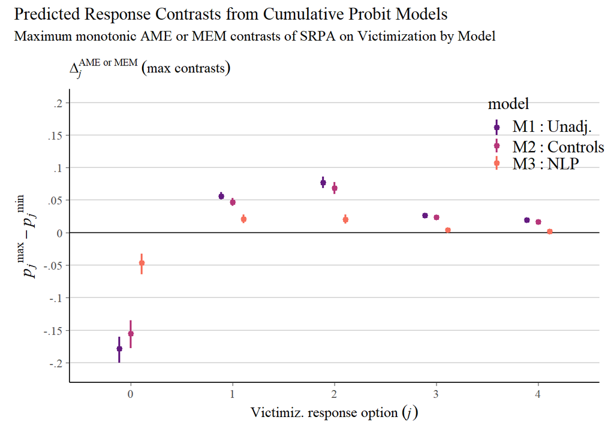

```r
# regenerate contrasts for model 3 using same method to make data merging easier
mod3mocon2 <- avg_comparisons(mod3mo, variables = list("SRPAf" = c("2","14"))) %>%
  data.frame() %>% mutate(model = "M1: Unadj.")

mod4mocon2 <- mod4mocon %>% mutate(model = "M2: Controls") %>%
  dplyr::select(!rowid)
mod5mocon2 <- mod5mocon %>% mutate(model = "M3: NLP") %>%
  dplyr::select(!rowid)

allmodcon <- rbind(mod3mocon2, mod4mocon2, mod5mocon2) %>%
  mutate(
    model = factor(model, levels = c("M1: Unadj.", "M2: Controls", "M3: NLP"),
                      ordered = FALSE)
    )

allmodconp <- allmodcon %>%
  ggplot(aes(x = group, y = estimate, ymin = conf.low, ymax = conf.high,
              color = model)) +
  geom_hline(yintercept = -4:4 / 20, color = "lightgrey") +
  geom_hline(yintercept = 0, color = "black") +
  geom_pointrange(aes(color = model), linewidth = 3/4, size = 1/3,
                      position = position_dodge(width = 1/3)) +
  scale_color_viridis_d(NULL, option = "magma", begin = .3, end = .7,
                        labels = scales::parse_format(), name = "model") +
  scale_y_continuous(expression(italic(p[j])^max-italic(p[j])^min),
                     limits = c(-0.21, 0.2), breaks=seq(-.2, .2, by = .05),
                     labels = dropLeadingZero) +
  labs(subtitle = expression(Delta[italic(j)]^{AME~or~MEM}~(max~contrasts)),
       x = expression(Victimiz.~response~option~(italic(j)))) +
  theme(
    legend.background = element_blank(),
    legend.position = c(0.9, 0.85),
    legend.key.height= unit(.5, 'cm'),
    legend.key.width= unit(.5, 'cm'),
    legend.title = element_text(size=14),
    legend.text=element_text(size=14),
    axis.title.y = element_text(size=14)
    )

allmodconp <- allmodconp +
  plot_annotation(title = "Predicted Response Contrasts from Cumulative Probit Models",
  subtitle = "Maximum monotonic AME or MEM contrasts of SRPA on Victimization by Model")

allmodconp
```

```r
# ggsave("allmodconp.jpeg", allmodconp, width=9, height=6.5)
```

This combined plot makes it easier to see that covariate adjustment in the “Controls” model has little impact on the maximum effect contrast. However, as expected given the strong ordinal bivariate association between SRPA and NLP (see mosaic plots above), adjusting for NLP results in substantial reductions in SRPA’s maximum effect contrasts. Of course, the question is whether this reduction is due to proper stratification on a strong confounder or improper adjustment on a mediator. Again, we cannot ascertain which is the case in these data. However, it is worth noting that one reason for conceptualizing sexual activity as a confounder was that it might cause heightened self-assessments and, thus, higher responses on SRPA items. Yet, results from the “Controls” model reveals little change in SRPA’s estimated maximum effect after adjusting for other measures of heightened self-assessments (e.g., self-reported intelligence and popularity). Given this, it remains plausible that the NLP’s impact on SRPA’s effect estimates at least partly represents mediation processes. Thus, operating on the strong assumption that the data generating process reflects underlying causal mediation processes, exploratory mediation models below further assess “direct” and potential “indirect” effects of SRPA on victimization.

Let’s wrap up by compiling some key coefficients into a table.

### 7.4 TAB1: Coefficient Table

```r
# custom function to extract and wrangle coefficients from brms models for gt()
coeftbl <- function(modfit) {fixef(modfit, summary = TRUE, robust = FALSE, probs = c(0.025, 0.975)) %>%
  data.frame() %>%
  dplyr::select(!Est.Error) %>%
  rownames_to_column(var = "Coefficient") %>%
  mutate(
    rowgrp = if_else(grepl("Intercept", Coefficient, ignore.case = TRUE), "Threshold", "beta"),
    rowgrp = if_else(grepl("SRPA", Coefficient, fixed = TRUE), "SRPA (beta)", rowgrp),
    rowgrp = factor(rowgrp, levels = c("SRPA (beta)","beta","Threshold"))
  )
  }

#Extract beta coefficients (latent response scale) from Bivariate model
coefm1 <- coeftbl(mod3mo) %>%
  rename(Est.M1 = Estimate,
         LL.M1 = Q2.5,
         UL.M1 = Q97.5)

#Extract beta coefficients (latent response scale) from Controls model
coefm2 <- coeftbl(mod4mo) %>%
  rename(Est.M2 = Estimate,
         LL.M2 = Q2.5,
         UL.M2 = Q97.5)

#Extract beta coefficients (latent response scale) from Controls + NLP model
coefm3 <- coeftbl(mod5mo) %>%
  rename(Est.M3 = Estimate,
         LL.M3 = Q2.5,
         UL.M3 = Q97.5)

#Merge coefficients from all 3 models into one dataset
coefm123 <- full_join(coefm1, coefm2)
coefm123 <- full_join(coefm123, coefm3)

#Add transformed "maximum" beta (still on latent response scale)
coefm123 <- coefm123 %>%
  add_row(Coefficient = "moSRPAf(max)",
          Est.M1 = maxbdat3$bE, LL.M1 = maxbdat3$.lower, UL.M1 = maxbdat3$.upper,
          Est.M2 = maxbdat4$bE, LL.M2 = maxbdat4$.lower, UL.M2 = maxbdat4$.upper,
          Est.M3 = maxbdat5$bE, LL.M3 = maxbdat5$.lower, UL.M3 = maxbdat5$.upper,
          rowgrp = "SRPA (max. beta)"
          ) %>%
  mutate(
    rowgrp = factor(rowgrp, levels = c("SRPA (beta)", "SRPA (max. beta)", "beta","Threshold"))
    ) %>%
  arrange(rowgrp)

tab1 <- coefm123 %>%
  gt(groupname_col = "rowgrp") %>%
  fmt_number(columns = everything(), rows = everything(), decimals = 2) %>%
  cols_merge(columns = c(LL.M1, UL.M1), pattern = "[{1}, {2}]") %>%
  cols_merge(columns = c(LL.M2, UL.M2), pattern = "[{1}, {2}]") %>%
  cols_merge(columns = c(LL.M3, UL.M3), pattern = "[{1}, {2}]") %>%
  cols_label(
    starts_with("Est.") ~ "Estimate",
    starts_with("LL.") ~ "95% Cr.I"
  ) %>%
  sub_missing(columns = everything(), rows = everything(), missing_text = "--") %>%
  tab_spanner(label = "Bivariate", columns = ends_with("M1")) %>%
  tab_spanner(label = "Controls", columns = ends_with("M2")) %>%
  tab_spanner(label = "Controls + NLP", columns = ends_with("M3")) %>%
  tab_header(
    title = md("**Table 1. Coefficients from brms Models Predicting Victimization**"),
    subtitle = md("Model betas represent estimated effects on latent continuous response scale")
    ) %>%
  opt_align_table_header(align = "left") %>%
  opt_vertical_padding(scale = 0.5) %>%
  opt_table_font(font = "serif") %>%
  opt_row_striping(row_striping = FALSE) %>%
  gt_highlight_cols(starts_with("Est."), fill = "lightgrey", alpha = 0.3) %>%
 tab_style(
    style = cell_text(style = "italic"),
    locations = cells_row_groups()
  )

tab1
```

**Table 1. Coefficients from brms Models Predicting Victimization**

Model betas represent estimated effects on latent continuous response scale

| Coefficient | Bivariate Estimate | Bivariate 95% Cr.I | Controls Estimate | Controls 95% Cr.I | Controls + NLP Estimate | Controls + NLP 95% Cr.I |
| --- | --- | --- | --- | --- | --- | --- |
| SRPA (beta) |  |  |  |  |  |  |
| moSRPAf | 0.05 | [0.05, 0.06] | 0.04 | [0.04, 0.05] | 0.02 | [0.01, 0.02] |
| SRPA (max. beta) |  |  |  |  |  |  |
| moSRPAf(max) | 0.61 | [0.55, 0.68] | 0.49 | [0.43, 0.56] | 0.22 | [0.15, 0.29] |
| beta |  |  |  |  |  |  |
| SRintelz | – | [–, –] | 0.00 | [−0.02, 0.01] | 0.01 | [0.00, 0.02] |
| SRpopularz | – | [–, –] | 0.06 | [0.04, 0.07] | 0.03 | [0.01, 0.04] |
| agez | – | [–, –] | 0.08 | [0.07, 0.09] | 0.00 | [−0.01, 0.02] |
| worked1 | – | [–, –] | 0.21 | [0.18, 0.24] | 0.12 | [0.09, 0.15] |
| gender2 | – | [–, –] | 0.66 | [0.63, 0.69] | 0.71 | [0.67, 0.74] |
| monlpf | – | [–, –] | – | [–, –] | 0.12 | [0.11, 0.13] |
| Threshold |  |  |  |  |  |  |
| Intercept[1] | 1.08 | [1.05, 1.13] | 1.58 | [1.53, 1.62] | 1.92 | [1.88, 1.97] |
| Intercept[2] | 1.48 | [1.44, 1.52] | 1.99 | [1.95, 2.04] | 2.37 | [2.33, 2.42] |
| Intercept[3] | 2.16 | [2.11, 2.20] | 2.70 | [2.65, 2.75] | 3.17 | [3.12, 3.22] |
| Intercept[4] | 2.59 | [2.54, 2.64] | 3.14 | [3.09, 3.20] | 3.63 | [3.57, 3.69] |

```r
# tab1 %>% gtsave("tab1.png", expand = 10)
# tab1 %>% gtsave("tab1.docx")
```

## 8 Exploratory mediation model

In mediation models below, I specified `yval=0` to estimating differences relative risks of “not” experiencing victimization (versus reporting 1,2,3 or 4 of the measured victimization experiences). The victimzation (y) model is specified as ordinal (estimated with `polr` package). However, the models are simplified relative to those estimated above as sexual activity (nlp) and physical attractiveness (SRPAavgz) are treated as metric standardized variables. I specified `astar` at the maximum SRPA score and `a` at the minimum SRPA score, which will essentially generate counterfactual contrasts that represent differences in the relative risks of any victimization. Values greater than one will indicate greater risks of victimization among respondents with maximum SRPA scores compared to minimum scores - or, more specifically, indicate greater risks of reporting “no victimization” [y=0] among those with minimum SRPA scores relative to those with maximum scores.

An important point here: Since non-victimization (y=0) is much more prevalent than “any” victimization (y>0), CMAverse contrast estimates on the relative risk scale for non-victimization will be much smaller than those describing victimization risks. For instance, consider a difference in predicted probabilities of non-victimization of 0.8 for Group 1 versus 0.7 in Group 2. The “risks” of not being victimized are greater in Group 1, with a prevalence (risk) ratio of 1.14 (0.8/0.7). In comparison, the risks of being victimized instead are 0.2 for Group 1 and 0.3 for Group 3; the risks are greater for Group 2, with a prevalence (risk) ratio of 1.5 (0.3/0.2). Note that both estimates are describing the same absolute contrast, but the relative risk estimates vary due to differences in baseline prevalance rates of non-victimization versus victimization.

Given potential confusion caused by this property of relative risk estimates, I will follow these ordinal y models with a logistic model predicting “any” victimization (collapsing y>0 sexual victimization responses into “1” response category) to generate victimization risk estimates and report these in the supplement section of the paper. I will also replicate the final logistic model with the “eversex” dichotomous mediator variable to assess whether results are sensitive to substantial nonrandom missingness (MNAR) on the mediator.

Finally, I will focus on results from the model specifying an EM interaction (EMint), though I present estimates from ordinal y models without and with a specified exposure-mediator (SRPA:NLP) interaction for supplementary comparison. In cases where the EMint is negligible, results will converge across both model types. However, where a nonnegligible EMint exists, mediation models should account for it.

### 8.1 CMAverse (ordinal Y, metric X & M) w/out exposure-mediator interaction

```r
datv3trim <- datv3 %>% drop_na()

est1 <- cmest(data = datv3trim, model = "rb",
             outcome = "sexvicsumf",
             exposure = "SRPAavgz",
             mediator = "nlpz",
             basec = c("SRintelz", "SRpopularz", "agez", "worked", "gender"),
             EMint = FALSE,
             mreg = list("linear"), yreg = "ordinal",
             astar = max(datv3trim$SRPAavgz), a = min(datv3trim$SRPAavgz),
             mval = list(0),
             yval = list(0),
             estimation = "imputation", inference = "bootstrap", nboot = 20)
```

### 8.2 CMAverse (ordinal Y, metric X & M) w/exposure-mediator interaction

```r
datv3trim <- datv3 %>% drop_na()

est2 <- cmest(data = datv3trim, model = "rb",
             outcome = "sexvicsumf",
             exposure = "SRPAavgz",
             mediator = "nlpz",
             basec = c("SRintelz", "SRpopularz", "agez", "worked", "gender"),
             EMint = TRUE,
             mreg = list("linear"), yreg = "ordinal",
             astar = max(datv3trim$SRPAavgz), a = min(datv3trim$SRPAavgz),
             mval = list(0),
             yval = list(0),
             estimation = "imputation", inference = "bootstrap", nboot = 20)
```

**TAB2A: Mediation Results**

```r
meddat <- as.data.frame(est2[9:12]) %>% rownames_to_column("CMA_est")

medtab <- meddat %>%
  rename("Estimate" = "effect.pe",
         "SE" = "effect.se",
         "ci_low" = "effect.ci.low",
         "ci_high" = "effect.ci.high") %>%
  filter(!CMA_est %in% c("ERcde(prop)", "ERintref(prop)", "ERintmed(prop)",
                          "ERpnie(prop)", "pm", "int", "pe")) %>%
  mutate(
    Description = if_else(CMA_est == "Rcde", "controlled direct effect (RR)", NA),
    Description = if_else(CMA_est == "Rpnde", "pure natural direct effect (RR)", Description),
    Description = if_else(CMA_est == "Rtnde", "total natural direct effect (RR)", Description),
    Description = if_else(CMA_est == "Rpnie", "pure natural indirect effect (RR)", Description),
    Description = if_else(CMA_est == "Rtnie", "total natural indirect effect (RR)", Description),
    Description = if_else(CMA_est == "Rte", "total effect (RR)", Description),
    Description = if_else(CMA_est == "ERcde", "excess relative risk due to cde", Description),
    Description = if_else(CMA_est == "ERintref", "excess rel. risk due to reference interaction", Description),
    Description = if_else(CMA_est == "ERintmed", "excess rel. risk due to mediated interaction", Description),
    Description = if_else(CMA_est == "ERpnie", "excess rel. risk due to pure natural indirect effect", Description),
    rowgrp = if_else(CMA_est %in% c("Rcde", "Rte"), " ", NA),
    rowgrp = if_else(CMA_est %in% c("Rtnde", "Rpnie"), "  ", rowgrp),
    rowgrp = if_else(CMA_est %in% c("Rpnde", "Rtnie"), "   ", rowgrp),
    rowgrp = if_else(CMA_est %in% c("ERcde", "ERintref", "ERintmed", "ERpnie"), "    ", rowgrp)
) %>%
  relocate(Description, .after = CMA_est)


medtab <- medtab %>%
  gt(groupname_col = "rowgrp", rowname_col = "CMA_est") %>%
  tab_stubhead(label = "Effect") %>%
  cols_label(ci_low = html("95% CrI<br>lower"),
             ci_high = html("95% CrI<br>upper")) %>%
  fmt_number(columns = everything(), rows = everything(), decimals = 2) %>%
  tab_header(
    title = md("**Table 2A. CMAverse Mediation Model Results**"),
    subtitle = md("`yval=0; astar=max(SRPA); a=min(SRPA)`")
    ) %>%
  opt_align_table_header(align = "left") %>%
  opt_vertical_padding(scale = 0.5) %>%
  opt_table_font(font = "serif") %>%
  cols_hide(columns = SE) %>%
  cols_move(columns = Estimate, after = ci_low) %>%
  gt_highlight_cols(Estimate, fill = "lightgrey", alpha = 0.3)
  # tab_style(
  #   style = cell_text(style = "italic"),
  #   locations = cells_body(columns = c(ci_low, ci_high)))

medtab
```

**Table 2A. CMAverse Mediation Model Results**

`yval=0; astar=max(SRPA); a=min(SRPA)`

| Effect | Description | 95% CrI lower | Estimate | 95% CrI upper |
| --- | --- | --- | --- | --- |
| Rcde | controlled direct effect (RR) | 1.04 | 1.08 | 1.11 |
| Rte | total effect (RR) | 1.12 | 1.16 | 1.19 |
| Rpnde | pure natural direct effect (RR) | 1.02 | 1.06 | 1.10 |
| Rtnie | total natural indirect effect (RR) | 1.08 | 1.10 | 1.11 |
| Rtnde | total natural direct effect (RR) | 1.04 | 1.07 | 1.10 |
| Rpnie | pure natural indirect effect (RR) | 1.07 | 1.08 | 1.09 |
| ERcde | excess relative risk due to cde | 0.05 | 0.08 | 0.11 |
| ERintref | excess rel. risk due to reference interaction | −0.03 | −0.02 | −0.01 |
| ERintmed | excess rel. risk due to mediated interaction | 0.00 | 0.02 | 0.03 |
| ERpnie | excess rel. risk due to pure natural indirect effect | 0.07 | 0.08 | 0.09 |

**Comparing Results: EMint vs. No EMint**

```r
est1dat <- as.data.frame(est1$effect.pe) %>% rownames_to_column("CMA_est")
est2dat <- as.data.frame(est2$effect.pe) %>% rownames_to_column("CMA_est")

estdattab <- full_join(est1dat, est2dat, by="CMA_est") %>%
  rename("No_EMint" = "est1$effect.pe", "EMint" = "est2$effect.pe") %>%
  filter(!CMA_est %in% c("ERcde(prop)", "ERintref(prop)", "ERintmed(prop)",
                          "ERpnie(prop)", "pm", "int", "pe")) %>%
  mutate(
    Description = if_else(CMA_est == "Rcde", "controlled direct effect (RR)", NA),
    Description = if_else(CMA_est == "Rpnde", "pure natural direct effect (RR)", Description),
    Description = if_else(CMA_est == "Rtnde", "total natural direct effect (RR)", Description),
    Description = if_else(CMA_est == "Rpnie", "pure natural indirect effect (RR)", Description),
    Description = if_else(CMA_est == "Rtnie", "total natural indirect effect (RR)", Description),
    Description = if_else(CMA_est == "Rte", "total effect (RR)", Description),
    Description = if_else(CMA_est == "ERcde", "excess relative risk due to cde", Description),
    Description = if_else(CMA_est == "ERintref", "excess rel. risk due to reference interaction", Description),
    Description = if_else(CMA_est == "ERintmed", "excess rel. risk due to mediated interaction", Description),
    Description = if_else(CMA_est == "ERpnie", "excess rel. risk due to pure natural indirect effect", Description)
)


estdattab %>%
  gt() %>%
    tab_spanner(label = html("CMAverse Mediation Model Results"),
                columns = c("CMA_est", "No_EMint", "EMint", "Description")) %>%
    cols_label(CMA_est = "Effect",
               No_EMint = html("No EMint<br>estimate"),
               EMint = html("EMint<br>estimate")) %>%
    fmt_number(columns = everything(), rows = everything(), decimals = 2) %>%
    cols_move(columns = "Description", after = "CMA_est")
```

| CMAverse Mediation Model Results Effect | CMAverse Mediation Model Results Description | CMAverse Mediation Model Results No EMint estimate | CMAverse Mediation Model Results EMint estimate |
| --- | --- | --- | --- |
| Rcde | controlled direct effect (RR) | 1.07 | 1.08 |
| Rpnde | pure natural direct effect (RR) | 1.08 | 1.06 |
| Rtnde | total natural direct effect (RR) | 1.06 | 1.07 |
| Rpnie | pure natural indirect effect (RR) | 1.10 | 1.08 |
| Rtnie | total natural indirect effect (RR) | 1.08 | 1.10 |
| Rte | total effect (RR) | 1.17 | 1.16 |
| ERcde | excess relative risk due to cde | NA | 0.08 |
| ERintref | excess rel. risk due to reference interaction | NA | −0.02 |
| ERintmed | excess rel. risk due to mediated interaction | NA | 0.02 |
| ERpnie | excess rel. risk due to pure natural indirect effect | NA | 0.08 |

**Risk Ratio Plot (EMint)**

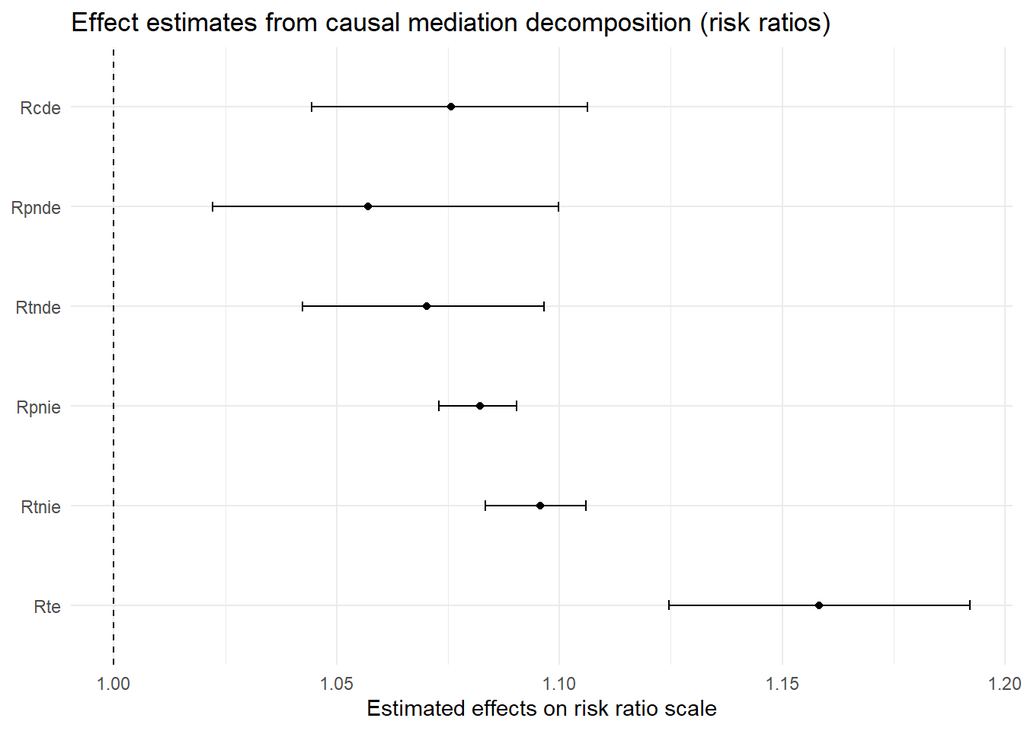

```r
#save estimates and intervals data
est2dat <- as.data.frame(est2[9:12]) %>%
  rownames_to_column("CMA_est")

#Transformation function used to display two decimal places on x axis
scaleFUN <- function(dec) sprintf("%.2f", dec)

# drop proportion estimates
est2dat %>%
  filter(!CMA_est %in% c("pm", "pe", "ERpnie(prop)", "ERintref(prop)",
                         "ERintmed(prop)","ERcde(prop)", "int",
                         "ERpnie", "ERintmed", "ERintref", "ERcde")) %>%
  mutate(CMA_est = factor(CMA_est, levels=c("Rte", "Rtnie", "Rpnie", "Rtnde", "Rpnde", "Rcde"))) %>%
  # reorder the coefficients so that the largest is at the top of the plot
  # mutate(term = fct_reorder(CMA_est, effect.pe)) %>%
  ggplot(aes(effect.pe, CMA_est)) +
  geom_point() +
  geom_errorbarh(aes(xmin = effect.ci.low, xmax = effect.ci.high), height = .1) +
  # add in a dotted line at zero
  geom_vline(xintercept = 1, lty = 2) +
  scale_x_continuous(labels=scaleFUN) +
  labs(
    x = "Estimated effects on risk ratio scale",
    y = NULL,
    title = "Effect estimates from causal mediation decomposition (risk ratios)"
  ) +
  theme_minimal()
```

**Excess Risk Plot (EMint)**

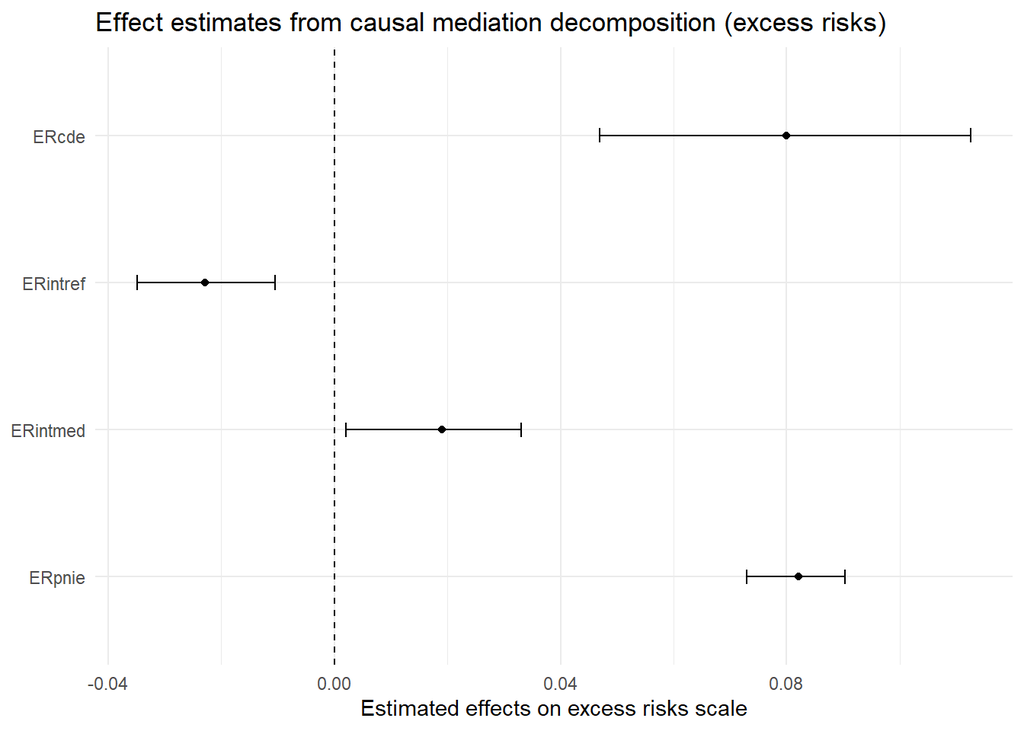

```r
#save estimates and intervals data
est2dat <- as.data.frame(est2[9:12]) %>%
  rownames_to_column("CMA_est")

# drop proportion estimates
est2dat %>%
  filter(!CMA_est %in% c("pm", "pe", "ERpnie(prop)", "ERintref(prop)",
                         "ERintmed(prop)","ERcde(prop)", "int",
                         "Rte", "Rtnie", "Rpnie", "Rtnde", "Rpnde", "Rcde")) %>%
  mutate(CMA_est = factor(CMA_est, levels=c("ERpnie", "ERintmed", "ERintref", "ERcde"))) %>%
  # reorder the coefficients so that the largest is at the top of the plot
  # mutate(term = fct_reorder(CMA_est, effect.pe)) %>%
  ggplot(aes(effect.pe, CMA_est)) +
  geom_point() +
  geom_errorbarh(aes(xmin = effect.ci.low, xmax = effect.ci.high), height = .1) +
  # add in a dotted line at zero
  geom_vline(xintercept = 0, lty = 2) +
  labs(
    x = "Estimated effects on excess risks scale",
    y = NULL,
    title = "Effect estimates from causal mediation decomposition (excess risks)"
  ) +
  theme_minimal()
```

**Risk Ratio Plot (no EMint)**

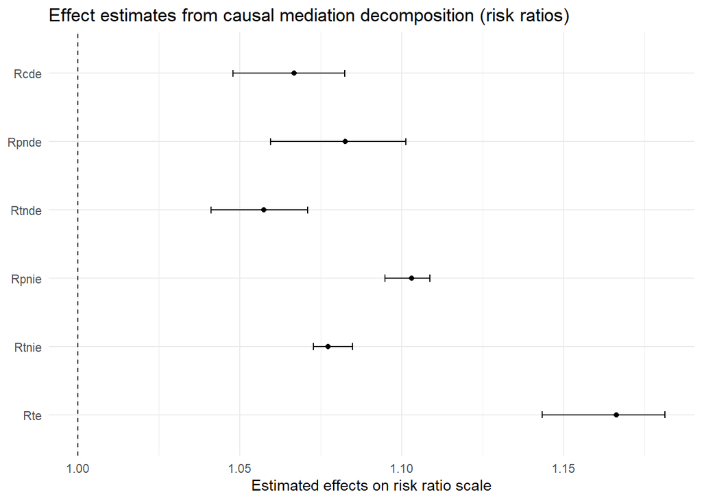

```r
#save estimates and intervals data
est1dat <- as.data.frame(est1[9:12]) %>%
  rownames_to_column("CMA_est")

#Transformation function used to display two decimal places on x axis
scaleFUN <- function(dec) sprintf("%.2f", dec)

# drop proportion estimates
est1dat %>%
  filter(!CMA_est %in% c("pm")) %>%
  mutate(CMA_est = factor(CMA_est, levels=c("Rte", "Rtnie", "Rpnie", "Rtnde", "Rpnde", "Rcde"))) %>%
  # reorder the coefficients so that the largest is at the top of the plot
  # mutate(term = fct_reorder(CMA_est, effect.pe)) %>%
  ggplot(aes(effect.pe, CMA_est)) +
  geom_point() +
  geom_errorbarh(aes(xmin = effect.ci.low, xmax = effect.ci.high), height = .1) +
  # add in a dotted line at zero
  geom_vline(xintercept = 1, lty = 2) +
  scale_x_continuous(labels=scaleFUN) +
  labs(
    x = "Estimated effects on risk ratio scale",
    y = NULL,
    title = "Effect estimates from causal mediation decomposition (risk ratios)"
  ) +
  theme_minimal()
```

**Full Output (EMint)**

```r
summary(est2)
```

```
Causal Mediation Analysis

# Outcome regression:
Call:
MASS::polr(formula = sexvicsumf ~ SRPAavgz + nlpz + SRPAavgz *
    nlpz + SRintelz + SRpopularz + agez + worked + gender, data = getCall(x$reg.output$yreg)$data,
    weights = getCall(x$reg.output$yreg)$weights)

Coefficients:
                Value Std. Error t value
SRPAavgz       0.1016     0.0151   6.743
nlpz           0.5150     0.0121  42.726
SRintelz       0.0235     0.0136   1.736
SRpopularz     0.0659     0.0146   4.503
agez          -0.0071     0.0142  -0.501
worked1        0.2423     0.0270   8.987
gender2        1.3328     0.0337  39.508
SRPAavgz:nlpz -0.0504     0.0115  -4.385

Intercepts:
    Value   Std. Error t value
0|1   2.668   0.032     82.565
1|2   3.484   0.035    100.791
2|3   5.118   0.045    113.788
3|4   6.228   0.063     98.800

Residual Deviance: 58058.96
AIC: 58082.96

# Mediator regressions:

Call:
glm(formula = nlpz ~ SRPAavgz + SRintelz + SRpopularz + agez +
    worked + gender, family = gaussian(), data = getCall(x$reg.output$mreg[[1L]])$data,
    weights = getCall(x$reg.output$mreg[[1L]])$weights)

Coefficients:
            Estimate Std. Error t value             Pr(>|t|)
(Intercept) -0.06602    0.00786   -8.40 < 0.0000000000000002 ***
SRPAavgz     0.23160    0.00489   47.32 < 0.0000000000000002 ***
```

[output cut: 45 more lines]

```
Relevant variable values:
$a
[1] -2

$astar
[1] 2.3

$yval
$yval[[1]]
[1] 0


$mval
$mval[[1]]
[1] 0
```

**Full Output (No EMint)**

```r
summary(est1)
```

```
Causal Mediation Analysis

# Outcome regression:
Call:
MASS::polr(formula = sexvicsumf ~ SRPAavgz + nlpz + SRintelz +
    SRpopularz + agez + worked + gender, data = getCall(x$reg.output$yreg)$data,
    weights = getCall(x$reg.output$yreg)$weights)

Coefficients:
              Value Std. Error t value
SRPAavgz    0.09081     0.0149   6.114
nlpz        0.50206     0.0117  42.798
SRintelz    0.02244     0.0135   1.657
SRpopularz  0.06689     0.0147   4.565
agez       -0.00316     0.0141  -0.224
worked1     0.24352     0.0270   9.033
gender2     1.33319     0.0337  39.517

Intercepts:
    Value   Std. Error t value
0|1   2.678   0.032     83.040
1|2   3.494   0.035    101.262
2|3   5.129   0.045    114.154
3|4   6.240   0.063     99.037

Residual Deviance: 58078.21
AIC: 58100.21

# Mediator regressions:

Call:
glm(formula = nlpz ~ SRPAavgz + SRintelz + SRpopularz + agez +
    worked + gender, family = gaussian(), data = getCall(x$reg.output$mreg[[1L]])$data,
    weights = getCall(x$reg.output$mreg[[1L]])$weights)

Coefficients:
            Estimate Std. Error t value             Pr(>|t|)
(Intercept) -0.06602    0.00786   -8.40 < 0.0000000000000002 ***
SRPAavgz     0.23160    0.00489   47.32 < 0.0000000000000002 ***
SRintelz    -0.04326    0.00443   -9.77 < 0.0000000000000002 ***
```

[output cut: 34 more lines]

```
Relevant variable values:
$a
[1] -2

$astar
[1] 2.3

$yval
$yval[[1]]
[1] 0


$mval
$mval[[1]]
[1] 0
```

The “No EMint” model estimates above do not account for a possible interaction between SRPA and NLP; like a classic” mediation model (and like our models above), it assumes these variables do not interact in their effects (apart from a pure mediation process). With this assumption, the model predicts sizable independent direct and indirect effects, implying that higher SRPA scores directly increase victimization risks as well as indirectly increase risks by increasing NLP. (Or, if a confounder, in indirect portion might be interpreted as the portion of the SRPA/victimization relationship that is due to confounding.)

However, when estimating indirect (or confounding) effects, it is important to account for the possibility of exposure-mediator (EMint) interactions (or, in this case, possibly an exposure-confounder interaction). So, I will focus on results from the EMint model, though supplemental results above also report estimates from a model without an EMint specified.

The estimates above predict relative risk contrasts for “no” versus “any” victimization (yval=0). Notice that these estimates are smaller than might be expected compared to similar contrasts from Bayesian models above. They are also a bit more confusing because they represent contrasts in relative risks of non-victimization rather than risks of victimization. Below, I modify the EMint model to predict a binary victimization outcome item using logistic regression and flip the `astar` and `a` values; this will provide more interpretable estimates of the relative risks of “any” victimization for high versus low SRPA scores. Then, I will replicate this new model after substituting NLP with an alternative dichotomous “eversex” mediator that has substantially less missing data.

### 8.3 CMAverse (binary Y, metric X & M) w/EMint

```r
datv3trim <- datv3 %>%
  mutate(anyvic = if_else(sexvicsum > 0, 1, sexvicsum)) %>%
  drop_na()

est3 <- cmest(data = datv3trim, model = "rb",
             outcome = "anyvic",
             exposure = "SRPAavgz",
             mediator = "nlpz",
             basec = c("SRintelz", "SRpopularz", "agez", "worked", "gender"),
             EMint = TRUE,
             mreg = list("linear"), yreg = "logistic",
             astar = min(datv3trim$SRPAavgz), a = max(datv3trim$SRPAavgz),
             mval = list(0),
             yval = list(1),
             estimation = "imputation", inference = "bootstrap", nboot = 20)
```

### 8.4 CMAverse (binary Y, metric X, binary “eversex” M) w/EMint

```r
datv3trim <- datv3 %>%
  mutate(anyvic = if_else(sexvicsum > 0, 1, sexvicsum),
         eversex = as.numeric(eversex)) %>%
  drop_na(eversex)

est4 <- cmest(data = datv3trim, model = "rb",
             outcome = "anyvic",
             exposure = "SRPAavgz",
             mediator = "eversex",
             basec = c("SRintelz", "SRpopularz", "agez", "worked", "gender"),
             EMint = TRUE,
             mreg = list("logistic"), yreg = "logistic",
             astar = min(datv3trim$SRPAavgz), a = max(datv3trim$SRPAavgz),
             mval = list(0),
             yval = list(1),
             estimation = "imputation", inference = "bootstrap", nboot = 20)
```

**TAB2B: Mediation Results (NLP)**

```r
meddat <- as.data.frame(est3[9:12]) %>% rownames_to_column("CMA_est")

# as.data.frame(est4[9:12]) %>% rownames_to_column("CMA_est")

medtab <- meddat %>%
  rename("Estimate" = "effect.pe",
         "SE" = "effect.se",
         "ci_low" = "effect.ci.low",
         "ci_high" = "effect.ci.high") %>%
  filter(!CMA_est %in% c("ERcde(prop)", "ERintref(prop)", "ERintmed(prop)",
                          "ERpnie(prop)", "pm", "int", "pe")) %>%
  mutate(
    Description = if_else(CMA_est == "Rcde", "controlled direct effect (RR)", NA),
    Description = if_else(CMA_est == "Rpnde", "pure natural direct effect (RR)", Description),
    Description = if_else(CMA_est == "Rtnde", "total natural direct effect (RR)", Description),
    Description = if_else(CMA_est == "Rpnie", "pure natural indirect effect (RR)", Description),
    Description = if_else(CMA_est == "Rtnie", "total natural indirect effect (RR)", Description),
    Description = if_else(CMA_est == "Rte", "total effect (RR)", Description),
    Description = if_else(CMA_est == "ERcde", "excess relative risk due to cde", Description),
    Description = if_else(CMA_est == "ERintref", "excess rel. risk due to reference interaction", Description),
    Description = if_else(CMA_est == "ERintmed", "excess rel. risk due to mediated interaction", Description),
    Description = if_else(CMA_est == "ERpnie", "excess rel. risk due to pure natural indirect effect", Description),
    rowgrp = if_else(CMA_est %in% c("Rcde", "Rte"), " ", NA),
    rowgrp = if_else(CMA_est %in% c("Rtnde", "Rpnie"), "  ", rowgrp),
    rowgrp = if_else(CMA_est %in% c("Rpnde", "Rtnie"), "   ", rowgrp),
    rowgrp = if_else(CMA_est %in% c("ERcde", "ERintref", "ERintmed", "ERpnie"), "    ", rowgrp)
) %>%
  relocate(Description, .after = CMA_est)


medtab <- medtab %>%
  gt(groupname_col = "rowgrp", rowname_col = "CMA_est") %>%
  tab_stubhead(label = "Effect") %>%
  cols_label(ci_low = html("95% CrI<br>lower"),
             ci_high = html("95% CrI<br>upper")) %>%
  fmt_number(columns = everything(), rows = everything(), decimals = 2) %>%
  tab_header(
    title = md("**Table 2B. CMAverse Mediation Model Results**"),
    subtitle = md("`yval=1; astar=min(SRPA); a=max(SRPA)`")
    ) %>%
  opt_align_table_header(align = "left") %>%
  opt_vertical_padding(scale = 0.5) %>%
  opt_table_font(font = "serif") %>%
  cols_hide(columns = SE) %>%
  cols_move(columns = Estimate, after = ci_low) %>%
  gt_highlight_cols(Estimate, fill = "lightgrey", alpha = 0.3)
  # tab_style(
  #   style = cell_text(style = "italic"),
  #   locations = cells_body(columns = c(ci_low, ci_high)))

medtab
```

**Table 2B. CMAverse Mediation Model Results**

`yval=1; astar=min(SRPA); a=max(SRPA)`

| Effect | Description | 95% CrI lower | Estimate | 95% CrI upper |
| --- | --- | --- | --- | --- |
| Rcde | controlled direct effect (RR) | 1.38 | 1.52 | 1.79 |
| Rte | total effect (RR) | 2.01 | 2.20 | 2.59 |
| Rpnde | pure natural direct effect (RR) | 1.42 | 1.56 | 1.84 |
| Rtnie | total natural indirect effect (RR) | 1.37 | 1.41 | 1.49 |
| Rtnde | total natural direct effect (RR) | 1.14 | 1.25 | 1.51 |
| Rpnie | pure natural indirect effect (RR) | 1.69 | 1.75 | 1.81 |
| ERcde | excess relative risk due to cde | 0.35 | 0.47 | 0.70 |
| ERintref | excess rel. risk due to reference interaction | 0.06 | 0.09 | 0.14 |
| ERintmed | excess rel. risk due to mediated interaction | −0.21 | −0.11 | 0.10 |
| ERpnie | excess rel. risk due to pure natural indirect effect | 0.69 | 0.75 | 0.81 |

```r
# medtab %>% gtsave("medtab.png", expand = 10)
# medtab %>% gtsave("medtab.docx")
```

**Comparing Results: M=NLP vs. M=Eversex**

```r
est3dat <- as.data.frame(est3$effect.pe) %>% rownames_to_column("CMA_est")
est4dat <- as.data.frame(est4$effect.pe) %>% rownames_to_column("CMA_est")

estdattab <- full_join(est3dat, est4dat, by="CMA_est") %>%
  rename("M_NLP" = "est3$effect.pe", "M_Eversex" = "est4$effect.pe") %>%
  filter(!CMA_est %in% c("ERcde(prop)", "ERintref(prop)", "ERintmed(prop)",
                          "ERpnie(prop)", "int")) %>%
  mutate(
    Description = if_else(CMA_est == "Rcde", "controlled direct effect (RR)", NA),
    Description = if_else(CMA_est == "Rpnde", "pure natural direct effect (RR)", Description),
    Description = if_else(CMA_est == "Rtnde", "total natural direct effect (RR)", Description),
    Description = if_else(CMA_est == "Rpnie", "pure natural indirect effect (RR)", Description),
    Description = if_else(CMA_est == "Rtnie", "total natural indirect effect (RR)", Description),
    Description = if_else(CMA_est == "Rte", "total effect (RR)", Description),
    Description = if_else(CMA_est == "ERcde", "excess relative risk due to cde", Description),
    Description = if_else(CMA_est == "ERintref", "excess rel. risk due to reference interaction", Description),
    Description = if_else(CMA_est == "ERintmed", "excess rel. risk due to mediated interaction", Description),
    Description = if_else(CMA_est == "ERpnie", "excess rel. risk due to pure natural indirect effect", Description),
    Description = if_else(CMA_est == "pm", "proportion mediated", Description),
    Description = if_else(CMA_est == "pe", "proportion eliminated", Description)
)


estdattab %>%
  gt() %>%
    tab_spanner(label = html("CMAverse Mediation Model Results"),
                columns = c("CMA_est", "M_NLP", "M_Eversex", "Description")) %>%
    cols_label(CMA_est = "Effect",
               M_NLP = html("M=NLP<br>estimate"),
               M_Eversex = html("M=Eversex<br>estimate")) %>%
    fmt_number(columns = everything(), rows = everything(), decimals = 2) %>%
    cols_move(columns = "Description", after = "CMA_est")
```

| CMAverse Mediation Model Results Effect | CMAverse Mediation Model Results Description | CMAverse Mediation Model Results M=NLP estimate | CMAverse Mediation Model Results M=Eversex estimate |
| --- | --- | --- | --- |
| Rcde | controlled direct effect (RR) | 1.52 | 1.48 |
| Rpnde | pure natural direct effect (RR) | 1.56 | 1.71 |
| Rtnde | total natural direct effect (RR) | 1.25 | 1.88 |
| Rpnie | pure natural indirect effect (RR) | 1.75 | 1.37 |
| Rtnie | total natural indirect effect (RR) | 1.41 | 1.50 |
| Rte | total effect (RR) | 2.20 | 2.57 |
| ERcde | excess relative risk due to cde | 0.47 | 0.27 |
| ERintref | excess rel. risk due to reference interaction | 0.09 | 0.44 |
| ERintmed | excess rel. risk due to mediated interaction | −0.11 | 0.49 |
| ERpnie | excess rel. risk due to pure natural indirect effect | 0.75 | 0.37 |
| pm | proportion mediated | 0.54 | 0.55 |
| pe | proportion eliminated | 0.61 | 0.83 |

**Risk Ratio Plot (NLP)**

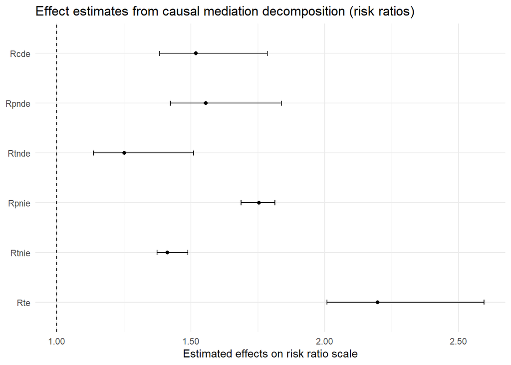

```r
#save estimates and intervals data
est3dat <- as.data.frame(est3[9:12]) %>%
  rownames_to_column("CMA_est")

#Transformation function used to display two decimal places on x axis
scaleFUN <- function(dec) sprintf("%.2f", dec)

# drop proportion estimates
est3dat %>%
  filter(!CMA_est %in% c("pm", "pe", "ERpnie(prop)", "ERintref(prop)",
                         "ERintmed(prop)","ERcde(prop)", "int",
                         "ERpnie", "ERintmed", "ERintref", "ERcde")) %>%
  mutate(CMA_est = factor(CMA_est, levels=c("Rte", "Rtnie", "Rpnie", "Rtnde", "Rpnde", "Rcde"))) %>%
  # reorder the coefficients so that the largest is at the top of the plot
  # mutate(term = fct_reorder(CMA_est, effect.pe)) %>%
  ggplot(aes(effect.pe, CMA_est)) +
  geom_point() +
  geom_errorbarh(aes(xmin = effect.ci.low, xmax = effect.ci.high), height = .1) +
  # add in a dotted line at zero
  geom_vline(xintercept = 1, lty = 2) +
  scale_x_continuous(labels=scaleFUN) +
  labs(
    x = "Estimated effects on risk ratio scale",
    y = NULL,
    title = "Effect estimates from causal mediation decomposition (risk ratios)"
  ) +
  theme_minimal()
```

**Excess Risk Plot (NLP)**

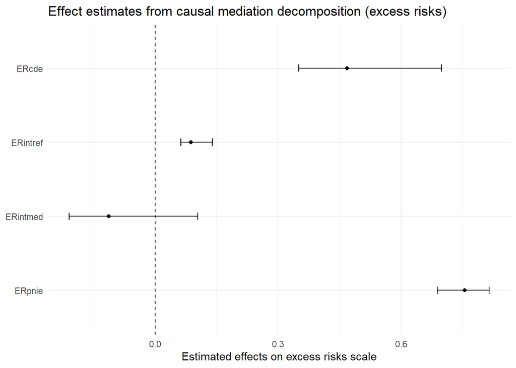

```r
#save estimates and intervals data
est3dat <- as.data.frame(est3[9:12]) %>%
  rownames_to_column("CMA_est")

# drop proportion estimates
est3dat %>%
  filter(!CMA_est %in% c("pm", "pe", "ERpnie(prop)", "ERintref(prop)",
                         "ERintmed(prop)","ERcde(prop)", "int",
                         "Rte", "Rtnie", "Rpnie", "Rtnde", "Rpnde", "Rcde")) %>%
  mutate(CMA_est = factor(CMA_est, levels=c("ERpnie", "ERintmed", "ERintref", "ERcde"))) %>%
  # reorder the coefficients so that the largest is at the top of the plot
  # mutate(term = fct_reorder(CMA_est, effect.pe)) %>%
  ggplot(aes(effect.pe, CMA_est)) +
  geom_point() +
  geom_errorbarh(aes(xmin = effect.ci.low, xmax = effect.ci.high), height = .1) +
  # add in a dotted line at zero
  geom_vline(xintercept = 0, lty = 2) +
  labs(
    x = "Estimated effects on excess risks scale",
    y = NULL,
    title = "Effect estimates from causal mediation decomposition (excess risks)"
  ) +
  theme_minimal()
```

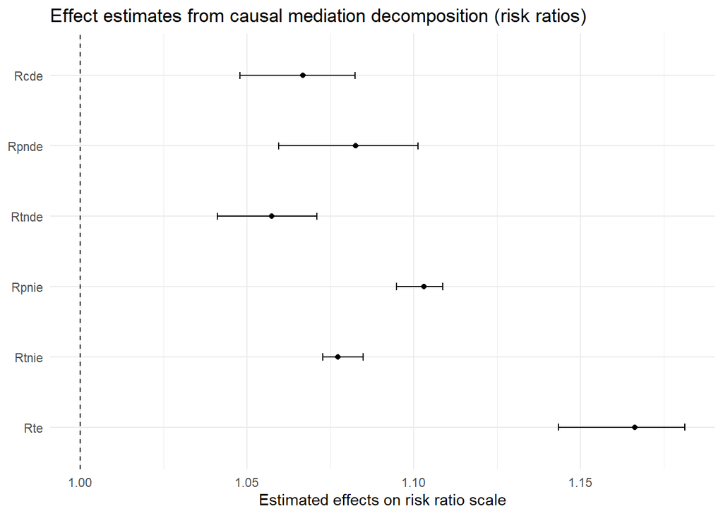

```r
#save estimates and intervals data
est4dat <- as.data.frame(est4[9:12]) %>%
  rownames_to_column("CMA_est")

#Transformation function used to display two decimal places on x axis
scaleFUN <- function(dec) sprintf("%.2f", dec)

# drop proportion estimates
est1dat %>%
  filter(!CMA_est %in% c("pm")) %>%
  mutate(CMA_est = factor(CMA_est, levels=c("Rte", "Rtnie", "Rpnie", "Rtnde", "Rpnde", "Rcde"))) %>%
  # reorder the coefficients so that the largest is at the top of the plot
  # mutate(term = fct_reorder(CMA_est, effect.pe)) %>%
  ggplot(aes(effect.pe, CMA_est)) +
  geom_point() +
  geom_errorbarh(aes(xmin = effect.ci.low, xmax = effect.ci.high), height = .1) +
  # add in a dotted line at zero
  geom_vline(xintercept = 1, lty = 2) +
  scale_x_continuous(labels=scaleFUN) +
  labs(
    x = "Estimated effects on risk ratio scale",
    y = NULL,
    title = "Effect estimates from causal mediation decomposition (risk ratios)"
  ) +
  theme_minimal()
```

**Excess Risk Plot (eversex)**

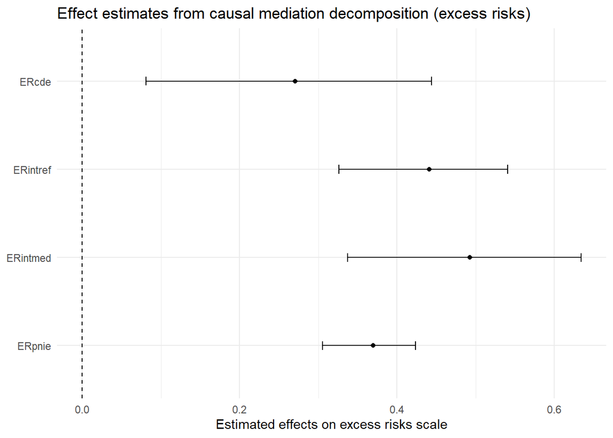

```r
#save estimates and intervals data
est4dat <- as.data.frame(est4[9:12]) %>%
  rownames_to_column("CMA_est")

# drop proportion estimates
est4dat %>%
  filter(!CMA_est %in% c("pm", "pe", "ERpnie(prop)", "ERintref(prop)",
                         "ERintmed(prop)","ERcde(prop)", "int",
                         "Rte", "Rtnie", "Rpnie", "Rtnde", "Rpnde", "Rcde")) %>%
  mutate(CMA_est = factor(CMA_est, levels=c("ERpnie", "ERintmed", "ERintref", "ERcde"))) %>%
  # reorder the coefficients so that the largest is at the top of the plot
  # mutate(term = fct_reorder(CMA_est, effect.pe)) %>%
  ggplot(aes(effect.pe, CMA_est)) +
  geom_point() +
  geom_errorbarh(aes(xmin = effect.ci.low, xmax = effect.ci.high), height = .1) +
  # add in a dotted line at zero
  geom_vline(xintercept = 0, lty = 2) +
  labs(
    x = "Estimated effects on excess risks scale",
    y = NULL,
    title = "Effect estimates from causal mediation decomposition (excess risks)"
  ) +
  theme_minimal()
```

**Full Output (NLP)**

```r
summary(est3)
```

```
Causal Mediation Analysis

# Outcome regression:

Call:
glm(formula = anyvic ~ SRPAavgz + nlpz + SRPAavgz * nlpz + SRintelz +
    SRpopularz + agez + worked + gender, family = binomial(),
    data = getCall(x$reg.output$yreg)$data, weights = getCall(x$reg.output$yreg)$weights)

Coefficients:
              Estimate Std. Error z value             Pr(>|z|)
(Intercept)   -2.65136    0.03238  -81.89 < 0.0000000000000002 ***
SRPAavgz       0.10067    0.01521    6.62       0.000000000036 ***
nlpz           0.50369    0.01240   40.62 < 0.0000000000000002 ***
SRintelz       0.02627    0.01374    1.91                0.056 .
SRpopularz     0.06389    0.01482    4.31       0.000016217068 ***
agez          -0.00521    0.01434   -0.36                0.716
worked1        0.23785    0.02740    8.68 < 0.0000000000000002 ***
gender2        1.31125    0.03384   38.74 < 0.0000000000000002 ***
SRPAavgz:nlpz -0.05682    0.01188   -4.78       0.000001724855 ***
---
Signif. codes:  0 '***' 0.001 '**' 0.01 '*' 0.05 '.' 0.1 ' ' 1

(Dispersion parameter for binomial family taken to be 1)

    Null deviance: 44777  on 47524  degrees of freedom
Residual deviance: 40438  on 47516  degrees of freedom
AIC: 40456

Number of Fisher Scoring iterations: 5


# Mediator regressions:

Call:
glm(formula = nlpz ~ SRPAavgz + SRintelz + SRpopularz + agez +
    worked + gender, family = gaussian(), data = getCall(x$reg.output$mreg[[1L]])$data,
    weights = getCall(x$reg.output$mreg[[1L]])$weights)

Coefficients:
```

[output cut: 48 more lines]

```
Relevant variable values:
$a
[1] 2.3

$astar
[1] -2

$yval
$yval[[1]]
[1] 1


$mval
$mval[[1]]
[1] 0
```

**Full Output (eversex)**

```r
summary(est4)
```

```
Causal Mediation Analysis

# Outcome regression:

Call:
glm(formula = anyvic ~ SRPAavgz + eversex + SRPAavgz * eversex +
    SRintelz + SRpopularz + agez + worked + gender, family = binomial(),
    data = getCall(x$reg.output$yreg)$data, weights = getCall(x$reg.output$yreg)$weights)

Coefficients:
                 Estimate Std. Error z value             Pr(>|z|)
(Intercept)       -3.1826     0.0387  -82.16 < 0.0000000000000002 ***
SRPAavgz           0.0930     0.0288    3.23               0.0012 **
eversex            1.0267     0.0325   31.61 < 0.0000000000000002 ***
SRintelz           0.0159     0.0125    1.27               0.2024
SRpopularz         0.0986     0.0134    7.35      0.0000000000002 ***
agez               0.0487     0.0109    4.45      0.0000084175657 ***
worked1            0.2889     0.0245   11.81 < 0.0000000000000002 ***
gender2            1.1971     0.0293   40.87 < 0.0000000000000002 ***
SRPAavgz:eversex   0.0654     0.0310    2.11               0.0349 *
---
Signif. codes:  0 '***' 0.001 '**' 0.01 '*' 0.05 '.' 0.1 ' ' 1

(Dispersion parameter for binomial family taken to be 1)

    Null deviance: 52298  on 52126  degrees of freedom
Residual deviance: 47978  on 52118  degrees of freedom
AIC: 47996

Number of Fisher Scoring iterations: 5


# Mediator regressions:

Call:
glm(formula = eversex ~ SRPAavgz + SRintelz + SRpopularz + agez +
    worked + gender, family = binomial(), data = getCall(x$reg.output$mreg[[1L]])$data,
    weights = getCall(x$reg.output$mreg[[1L]])$weights)

Coefficients:
```

[output cut: 48 more lines]

```
Relevant variable values:
$a
[1] 2.3

$astar
[1] -2

$yval
$yval[[1]]
[1] 1


$mval
$mval[[1]]
[1] 0
```

Assuming sexual activity (measured as number of lifetime sexual partners, or NLP) mediates a causal effect of physical attractiveness (SRPA) on sexual victimization, these results provide estimates of the relative magnitudes of direct and indirect effects on the victimization risk ratio scale. As with earlier models, these estimates were generated as “maximum” risk ratio contrasts comparing relative risks of victimization for those with highest and lowest SRPA scores. Even if the mediation assumption is wholly invalid and NLP is fully a confounder of the SRPA/victimization relationship, these results provide useful insights into the nature of the joint relationships.

The pure natural direct effect (PNDE) might be considered a lower bound estimate that represents a minimum effect under an assumption that NLP is a confounder rather than a mediator, as the so-called “direct” effect represents associations generated by unmeasured mechanisms (e.g., target gratifiability) after adjusting out any effects that are related to the mediator (sexual activity). The “pure natural direct effect” (PNDE) estimate predicts those with the highest SRPA scores directly experience approximately 1.56 times the risk of victimization, or a 56% increase in risk of victimization, compared to those with the lowest SRPA scores after adjusting for NLP and controls.

For more information about CMAverse models and effect estimates, see my [blog posts](https://reluctantcriminologists.com/blog-posts/%5B11%5D/modmadness-pt3) on the topic.

## 9 Supplemental Interaction Models

Now, with primary models completed, let’s turn to supplementary models assessing effect heterogeneity across gender and nlp.

First, to assess whether estimates vary across gender (noted as possibility in preregistration based on prior research), I add an interaction between SRPA and gender to the “Controls” model (ie., with covariates but without NLP due to ambiguity of NLP’s status as a confounding or mediating mechanism), then plot predicted probabilities and contrasts for each ordinal response category for males and females.

### 9.1 Gender: Ord~Ord (sexvicsumf by moSRPAf:gender)

```r
#Ordinal cumulative probit model of sexual victimization index
#with ordinal (monotonic cumulative probit) SRPA predictor,
# linear controls, & mo(SRPA):gender

#10 nlp response categories = 9 thresholds
# so, beta prior (0,1) equiv to (0,[1/9]) or (0,.11)

#sexvicsum - bivariate sexvicsum by mo(SRPAf):
mod6mo <-
  brm(data = datv3tmp,
      family = cumulative("probit"),
      sexvicsumf ~ 1 + mo(SRPAf) +
        SRintelz + SRpopularz + agez + worked +
        gender + mo(SRPAf):gender,
      prior = priors3,
      iter = 2000, warmup = 1000,
      chains = 4,
      cores = nCoresphys,
        backend = "cmdstanr",
        # threads = threading(2), #consider within-chain threading if machine has at least 8 physical cores
      seed = 8675309,
      file = "Models/mod6mo_fit",
      file_refit = "on_change"
      )
```

**Coefficient plot (moSRPAf)**

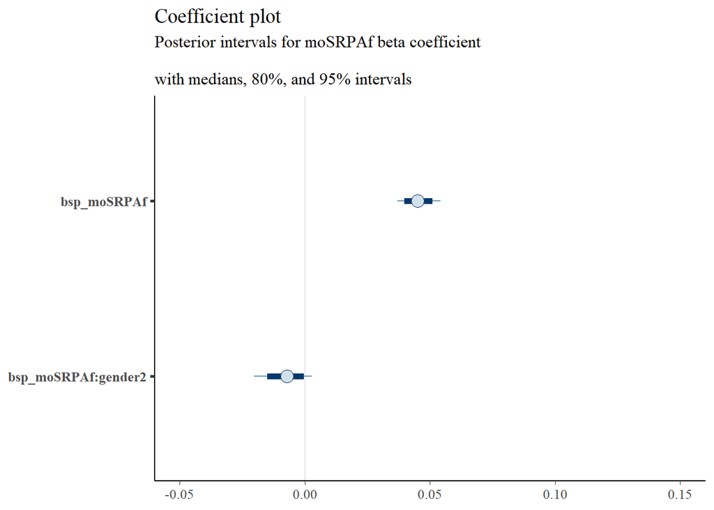

```r
post6mo <- as.matrix(mod6mo)

mcmc_intervals(
  post6mo,
  regex_pars = "bsp_moSRPAf",
  prob = 0.8, # 80% intervals
  prob_outer = 0.95, # 95%
  point_est = "median",
) +
  xlim(-.05, .15) +
  labs(title = "Coefficient plot",
       subtitle = "Posterior intervals for moSRPAf beta coefficient
       \nwith medians, 80%, and 95% intervals")
```

**Coefficient plot (all)**

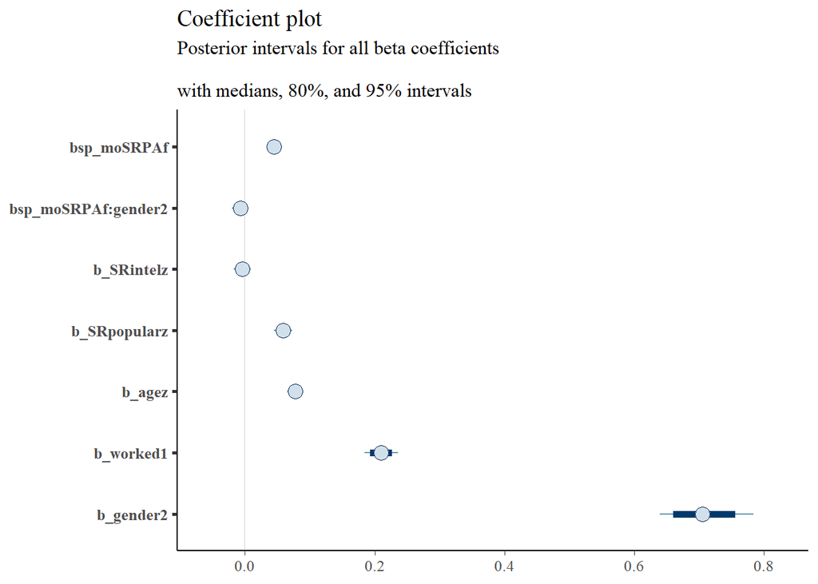

```r
coefgrp <- c("bsp_","b_SR", "age", "worked", "b_gender")
mcmc_plot(mod6mo, variable = coefgrp, regex = TRUE,
          prob = 0.80, prob_outer = 0.95) +
  labs(title = "Coefficient plot",
       subtitle = "Posterior intervals for all beta coefficients
       \nwith medians, 80%, and 95% intervals")
```

**Conditional effects (continuous y)**

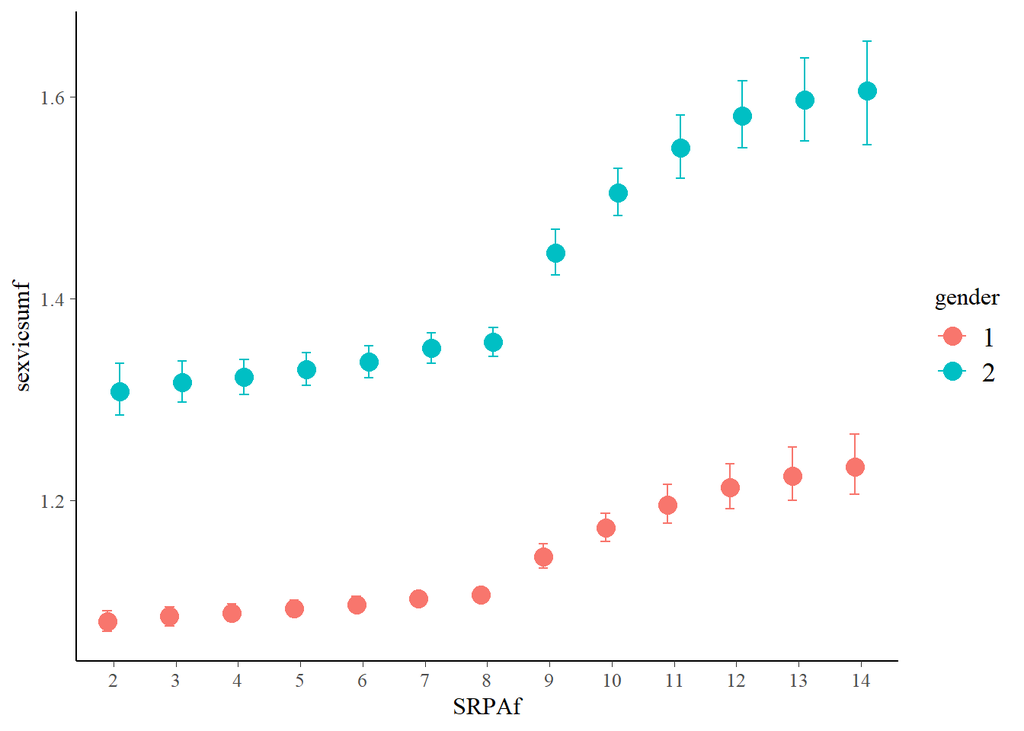

```r
conditional_effects(mod6mo, "SRPAf:gender")
```

**Fit summary**

```r
summary(mod6mo, probs = c(0.025, 0.975), digits = 2) #summarize results
```

```
 Family: cumulative
  Links: mu = probit; disc = identity
Formula: sexvicsumf ~ 1 + mo(SRPAf) + SRintelz + SRpopularz + agez + worked + gender + mo(SRPAf):gender
   Data: datv3tmp (Number of observations: 52191)
  Draws: 4 chains, each with iter = 2000; warmup = 1000; thin = 1;
         total post-warmup draws = 4000

Regression Coefficients:
                Estimate Est.Error l-95% CI u-95% CI Rhat Bulk_ESS Tail_ESS
Intercept[1]        1.60      0.03     1.54     1.66 1.00     1997     2064
Intercept[2]        2.02      0.03     1.96     2.08 1.00     2091     2337
Intercept[3]        2.72      0.03     2.66     2.79 1.00     2229     2411
Intercept[4]        3.17      0.03     3.10     3.24 1.00     2420     2431
SRintelz           -0.00      0.01    -0.02     0.01 1.00     5864     3135
SRpopularz          0.06      0.01     0.04     0.07 1.00     4977     3131
agez                0.08      0.01     0.07     0.09 1.00     6092     3130
worked1             0.21      0.01     0.18     0.24 1.00     5027     3052
gender2             0.71      0.04     0.64     0.78 1.00     1887     2291
moSRPAf             0.05      0.00     0.04     0.05 1.00     1792     2241
moSRPAf:gender2    -0.01      0.01    -0.02     0.00 1.00     1691     2067

Monotonic Simplex Parameters:
                     Estimate Est.Error l-95% CI u-95% CI Rhat Bulk_ESS
moSRPAf1[1]              0.05      0.03     0.01     0.12 1.00     2928
moSRPAf1[2]              0.04      0.02     0.01     0.09 1.00     3719
moSRPAf1[3]              0.04      0.02     0.01     0.09 1.00     3673
moSRPAf1[4]              0.03      0.02     0.00     0.08 1.00     2527
moSRPAf1[5]              0.06      0.03     0.01     0.11 1.00     3036
moSRPAf1[6]              0.03      0.02     0.00     0.08 1.00     2881
moSRPAf1[7]              0.28      0.04     0.20     0.37 1.00     2903
moSRPAf1[8]              0.17      0.04     0.09     0.26 1.00     3270
moSRPAf1[9]              0.12      0.04     0.04     0.21 1.00     3249
moSRPAf1[10]             0.09      0.04     0.02     0.17 1.00     3583
moSRPAf1[11]             0.05      0.03     0.01     0.12 1.00     4027
moSRPAf1[12]             0.04      0.03     0.00     0.11 1.00     4641
moSRPAf:gender21[1]      0.10      0.09     0.00     0.32 1.00     3555
moSRPAf:gender21[2]      0.10      0.08     0.00     0.31 1.00     3058
moSRPAf:gender21[3]      0.08      0.07     0.00     0.27 1.00     3526
moSRPAf:gender21[4]      0.07      0.07     0.00     0.26 1.00     2868
moSRPAf:gender21[5]      0.06      0.06     0.00     0.23 1.00     4121
```

[output cut: 25 more lines]

```
moSRPAf:gender21[6]      1648
moSRPAf:gender21[7]      1998
moSRPAf:gender21[8]      2033
moSRPAf:gender21[9]      1974
moSRPAf:gender21[10]     2067
moSRPAf:gender21[11]     2468
moSRPAf:gender21[12]     2473

Further Distributional Parameters:
     Estimate Est.Error l-95% CI u-95% CI Rhat Bulk_ESS Tail_ESS
disc     1.00      0.00     1.00     1.00   NA       NA       NA

Draws were sampled using sample(hmc). For each parameter, Bulk_ESS
and Tail_ESS are effective sample size measures, and Rhat is the potential
scale reduction factor on split chains (at convergence, Rhat = 1).
```

**Prior summary**

```r
prior_summary(mod6mo) #check priors
```

```
                                         prior     class             coef group
                                  normal(0, 1)         b
                                  normal(0, 1)         b             agez
                                  normal(0, 1)         b          gender2
                              normal(0, 0.083)         b          moSRPAf
                                  normal(0, 1)         b  moSRPAf:gender2
                                  normal(0, 1)         b         SRintelz
                                  normal(0, 1)         b       SRpopularz
                                  normal(0, 1)         b          worked1
                          student_t(3, 0, 2.5) Intercept
                              normal(-0.84, 1) Intercept                1
                              normal(-0.25, 1) Intercept                2
                               normal(0.25, 1) Intercept                3
                               normal(0.84, 1) Intercept                4
                                  dirichlet(1)      simo moSRPAf:gender21
 dirichlet(2, 2, 2, 2, 2, 2, 2, 2, 2, 2, 2, 2)      simo         moSRPAf1
 resp dpar nlpar lb ub       source
                               user
                       (vectorized)
                       (vectorized)
                               user
                       (vectorized)
                       (vectorized)
                       (vectorized)
                       (vectorized)
                            default
                               user
                               user
                               user
                               user
                            default
                               user
```

#### 9.1.1 Visualize max moSRPA effect by response category & gender (mod6mo)

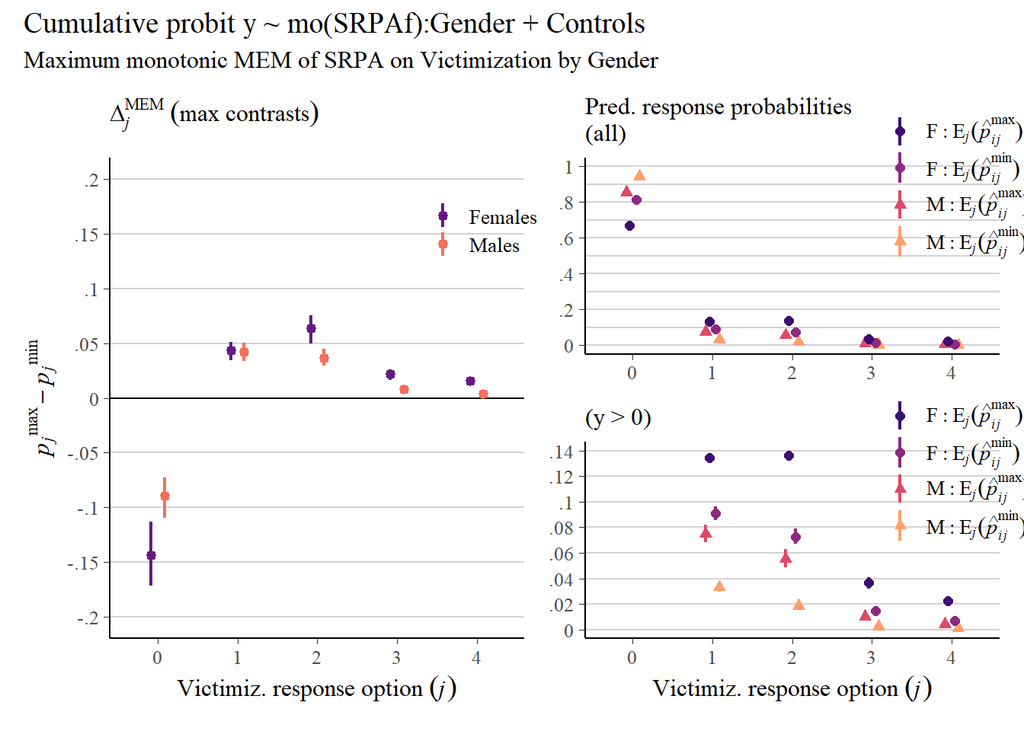

```r
#manual predictions at user-specified means or representative values

# function to generate var mean
# meanvar <- function(x){
#   mean(x, na.rm=TRUE)
# }

#define predictor grid for conditional avg at covariate means or rep values
# ndmo_gen <- tibble(
#   gender= c("1","2"),
#   nlpf = "2", #set at 2 lifetime partners (mean=1.9)
#   SRintelz = 0,
#   SRpopularz = 0,
#   agez = 0,
#   worked = "1") %>%
#   expand_grid(SRPAf = c("2","14"))

# generate and save predictions at user-specified covariate values
# mod6mopred <- predictions(mod6mo, newdata = ndmo_gen) %>%
#   data.frame() %>%
#   mutate(
#     colgrp = if_else(gender == "1" & SRPAf == "2", "M: E[italic(j)](hat(italic(p))[italic(ij)]^min)", "M: E[italic(j)](hat(italic(p))[italic(ij)]^max)"),
#     colgrp = if_else(gender == "2" & SRPAf == "2", "F: E[italic(j)](hat(italic(p))[italic(ij)]^min)", colgrp),
#     colgrp = if_else(gender == "2" & SRPAf == "14", "F: E[italic(j)](hat(italic(p))[italic(ij)]^max)", colgrp),
#   SRPAf = ifelse(SRPAf == "2", "E[italic(j)](hat(italic(p))[italic(ij)]^min)", "E[italic(j)](hat(italic(p))[italic(ij)]^max)"))


#Let's go with automated predictions by response category at means

mod6mopred <- predictions(mod6mo, variables = list(SRPAf = c("2","14")),
newdata = "mean", by = c("SRPAf", "group","gender")) %>%
  data.frame() %>%
  mutate(
    colgrp = if_else(gender == "1" & SRPAf == "2", "M: E[italic(j)](hat(italic(p))[italic(ij)]^min)", "M: E[italic(j)](hat(italic(p))[italic(ij)]^max)"),
    colgrp = if_else(gender == "2" & SRPAf == "2", "F: E[italic(j)](hat(italic(p))[italic(ij)]^min)", colgrp),
    colgrp = if_else(gender == "2" & SRPAf == "14", "F: E[italic(j)](hat(italic(p))[italic(ij)]^max)", colgrp),
  SRPAf = ifelse(SRPAf == "2", "E[italic(j)](hat(italic(p))[italic(ij)]^min)", "E[italic(j)](hat(italic(p))[italic(ij)]^max)"))


#function to find & drop leading zeroes (used for x-axis label)
dropLeadingZero <- function(l){
  str_replace(l, '0(?=.)', '')
}

mod6mopred_m <- mod6mopred %>% dplyr::filter(gender=="1")
mod6mopred_f <- mod6mopred %>% dplyr::filter(gender=="2")

#full range of y responses (0:4)
mod6mop1 <-  ggplot(mod6mopred, aes(x = group, y = estimate, ymin = conf.low, ymax = conf.high,
             color = colgrp)) +
  geom_hline(yintercept = 0:10 / 10, color = "lightgrey") +
  geom_linerange(data=mod6mopred_m, aes(color = colgrp), linewidth = 3/4, position = position_dodge(width = 1/3)) +
  geom_point(data=mod6mopred_m, aes(shape = colgrp),
             position = position_dodge(width = 1/3),
             size = 2) +
  geom_linerange(data=mod6mopred_f, aes(color = colgrp), linewidth = 3/4, position = position_dodge(width = 1/6)) +
  geom_point(data=mod6mopred_f, aes(shape = colgrp),
             position = position_dodge(width = 1/6),
             size = 2) +
  scale_color_viridis_d(NULL, option = "magma", begin = .2, end = .8,
                        labels = scales::parse_format()) +
  scale_shape_manual(NULL, values = c(19, 19, 17, 17),
                     labels = scales::parse_format()) +
  scale_y_continuous(limits = c(0, 1), breaks=seq(0, 1, by = .2),
                     labels = dropLeadingZero) +
  labs(subtitle = "Pred. response probabilities\n(all)") +
  theme(legend.background = element_blank(),
        legend.position = c(0.9, 0.85),
        legend.key.height= unit(.5, 'cm'),
        legend.key.width= unit(.5, 'cm'),
        legend.title = element_text(size=10),
        legend.text=element_text(size=10),
        axis.title.y = element_blank(),
        axis.title.x = element_blank())


#nonzero victimization values only (1:4)
mod6mop2 <-  ggplot(mod6mopred, aes(x = group, y = estimate, ymin = conf.low, ymax = conf.high,
             color = colgrp)) +
  geom_hline(yintercept = 0:7 / 50, color = "lightgrey") +
  geom_linerange(data=mod6mopred_m, aes(color = colgrp), linewidth = 3/4, position = position_dodge(width = 1/3)) +
  geom_point(data=mod6mopred_m, aes(shape = colgrp),
             position = position_dodge(width = 1/3),
             size = 2) +
  geom_linerange(data=mod6mopred_f, aes(color = colgrp), linewidth = 3/4, position = position_dodge(width = 1/6)) +
  geom_point(data=mod6mopred_f, aes(shape = colgrp),
             position = position_dodge(width = 1/6),
             size = 2) +
  scale_color_viridis_d(NULL, option = "magma", begin = .2, end = .8,
                        labels = scales::parse_format()) +
  scale_shape_manual(NULL, values = c(19, 19, 17, 17),
                     labels = scales::parse_format()) +
  scale_y_continuous(limits = c(0, .14), breaks=seq(0, .14, by = .02),
                     labels = dropLeadingZero) +
  labs(subtitle = "(y > 0)",
       x = expression(Victimiz.~response~option~(italic(j)))) +
  theme(legend.background = element_blank(),
        legend.position = c(0.9, 0.85),
        legend.key.height= unit(.5, 'cm'),
        legend.key.width= unit(.5, 'cm'),
        legend.title = element_text(size=10),
        legend.text=element_text(size=10),
        axis.title.y = element_blank()
        )


# estimate contrasts at means or rep values

mod6mocon <- comparisons(mod6mo, variables = list(SRPAf = c("2","14")),
newdata = "mean", by = c("group","gender")) %>%
  data.frame() %>%
  mutate(
    gender = if_else(gender == "1", "Males", "Females"))


mod6mop3 <- mod6mocon %>%
  ggplot(aes(x = group, y = estimate, ymin = conf.low, ymax = conf.high, color = gender)) +
  geom_hline(yintercept = -4:4 / 20, color = "lightgrey") +
  geom_hline(yintercept = 0, color = "black") +
  geom_pointrange(aes(color = gender), linewidth = 3/4, size = 1/3, position = position_dodge(width = 1/3)) +
  scale_color_viridis_d(NULL, option = "magma", begin = .3, end = .7,
                        labels = scales::parse_format()) +
  scale_y_continuous(expression(italic(p[j])^max-italic(p[j])^min),
                     limits = c(-0.2, 0.2), breaks=seq(-.2, .2, by = .05),
                     labels = dropLeadingZero) +
  labs(subtitle = expression(Delta[italic(j)]^{MEM}~(max~contrasts)),
       x = expression(Victimiz.~response~option~(italic(j)))) +
  theme(legend.background = element_blank(),
        legend.position = c(0.9, 0.85),
        legend.key.height= unit(.5, 'cm'),
        legend.key.width= unit(.5, 'cm'),
        legend.title = element_text(size=10),
        legend.text=element_text(size=10)
        )

# combine and entitle
((mod6mop3 | mod6mop1 / mod6mop2)) +
  plot_annotation(title = "Cumulative probit y ~ mo(SRPAf):Gender + Controls",
  subtitle = "Maximum monotonic MEM of SRPA on Victimization by Gender")
```

#### 9.1.2 “Interaction Model 2 (Controls)” Contrasts

```r
mod6mocon %>% gt()
```

| rowid | term | group | contrast | gender | estimate | conf.low | conf.high | predicted_lo | predicted_hi | predicted | tmp_idx |
| --- | --- | --- | --- | --- | --- | --- | --- | --- | --- | --- | --- |
| 1 | SRPAf | 0 | mean(14) - mean(2) | Males | -0.0898 | -0.1100 | -0.0725 | 0.94524 | 0.8555 | 0.9289 | 1 |
| 2 | SRPAf | 0 | mean(14) - mean(2) | Females | -0.1442 | -0.1716 | -0.1130 | 0.81470 | 0.6706 | 0.7896 | 2 |
| 1 | SRPAf | 1 | mean(14) - mean(2) | Males | 0.0419 | 0.0341 | 0.0506 | 0.03297 | 0.0749 | 0.0414 | 1 |
| 2 | SRPAf | 1 | mean(14) - mean(2) | Females | 0.0437 | 0.0348 | 0.0512 | 0.09074 | 0.1344 | 0.0997 | 2 |
| 1 | SRPAf | 2 | mean(14) - mean(2) | Males | 0.0366 | 0.0294 | 0.0452 | 0.01854 | 0.0552 | 0.0249 | 1 |
| 2 | SRPAf | 2 | mean(14) - mean(2) | Females | 0.0635 | 0.0497 | 0.0757 | 0.07271 | 0.1362 | 0.0838 | 2 |
| 1 | SRPAf | 3 | mean(14) - mean(2) | Males | 0.0078 | 0.0060 | 0.0100 | 0.00246 | 0.0102 | 0.0036 | 1 |
| 2 | SRPAf | 3 | mean(14) - mean(2) | Females | 0.0217 | 0.0166 | 0.0264 | 0.01488 | 0.0366 | 0.0181 | 2 |
| 1 | SRPAf | 4 | mean(14) - mean(2) | Males | 0.0035 | 0.0027 | 0.0047 | 0.00077 | 0.0043 | 0.0012 | 1 |
| 2 | SRPAf | 4 | mean(14) - mean(2) | Females | 0.0154 | 0.0114 | 0.0192 | 0.00689 | 0.0222 | 0.0088 | 2 |

Estimates from this model shows higher predicted probabilities of reported sexual victimization for females compared to males across both the lowest and highest SRPA scores. Likewise, the “conditional effects” plot displaying predicted probabilities by gender across all SRPA categories (see tab above) also illustrates these gender differences. Interestingly, examination of the conditional effects plot also reveals that the pattern of increased victimization risks emerging primarily at the upper range of SRPA scores (e.g., >8 on the ordinal scale ranging from 2 to 14) is apparent both for females and males.

Also, the maximum effect contrasts indicate that differences in predicted probabilities between those with the lowest and highest SRPA scores are larger for females than for males. Recall, these estimates adjust for measured potential confounders but not nlp.

Let’s rerun the model to see if patterns hold after adjusting for NLP. This time, though, we will increase the number of iterations and the warmup. This is because two mo(x) variables and an interaction with one of the mo(x) variables is asking a lot from our data, and our previous specifications resulted in low ESS (<1000) & high Rhat (>1.01) values (see [here](https://easystats.github.io/effectsize/reference/interpret_ess.html) for more information). With four chains each generating 10k iterations (minus 1k warmup), we will end with 36k post-warmup draws from the posterior (compared to 4k in simpler models above). This may be going a bit overboard here, but the model already takes a long time to run so I want to be sure we have enough samples to generate valid conclusions about the posterior.

### 9.2 Gender: Ord~Ord (sexvicsumf by moSRPAf:gender, add NLP)

```r
#Ordinal cumulative probit model of sexual victimization index
#with ordinal (monotonic cumulative probit) SRPA predictor,
# linear controls, mo(SRPA):gender, & mo(nlp)

#sexvicsum - bivariate sexvicsum by mo(SRPAf):
mod7mo <-
  brm(data = datv3tmp,
      family = cumulative("probit"),
      sexvicsumf ~ 1 + mo(SRPAf) +  mo(nlpf) +
        SRintelz + SRpopularz + agez + worked +
        gender + mo(SRPAf):gender,
      prior = priors4,
      iter = 10000, warmup = 1000,
      chains = 4,
      cores = nCoresphys,
        backend = "cmdstanr",
        # threads = threading(2), #consider within-chain threading if machine has at least 8 physical cores
      seed = 8675309,
      file = "Models/mod7mo_fit",
      file_refit = "on_change"
      )
```

**Coefficient plot (moSRPAf)**

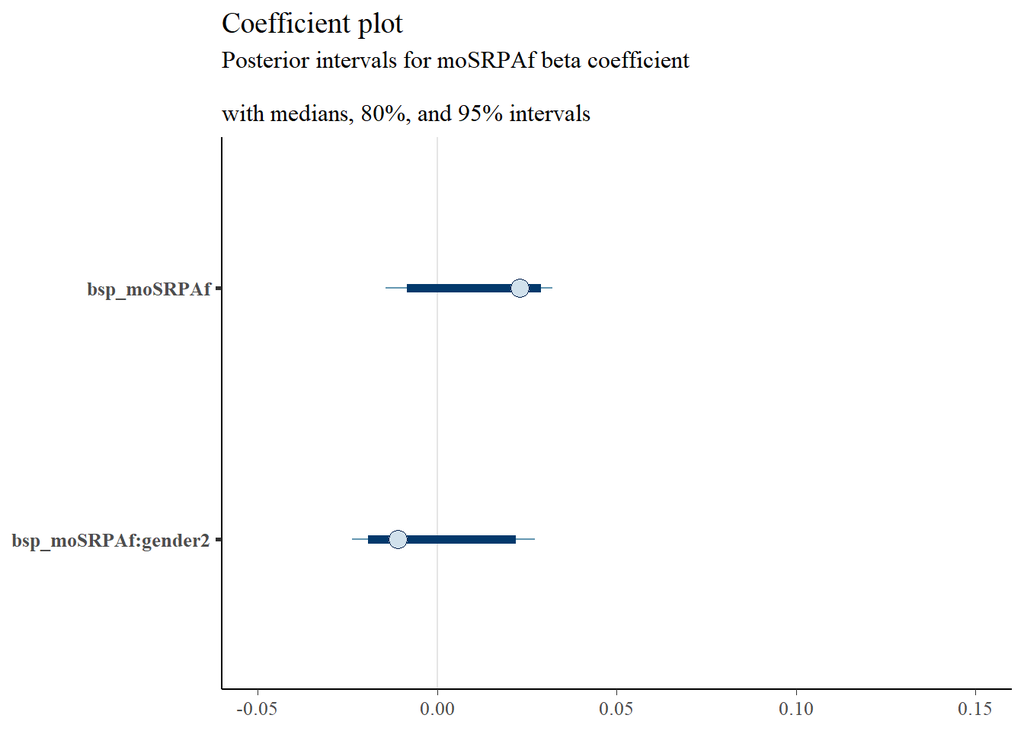

```r
post7mo <- as.matrix(mod7mo)

mcmc_intervals(
  post7mo,
  regex_pars = "bsp_moSRPAf",
  prob = 0.8, # 80% intervals
  prob_outer = 0.95, # 95%
  point_est = "median",
) +
  xlim(-.05, .15) +
  labs(title = "Coefficient plot",
       subtitle = "Posterior intervals for moSRPAf beta coefficient
       \nwith medians, 80%, and 95% intervals")
```

**Coefficient plot (all)**

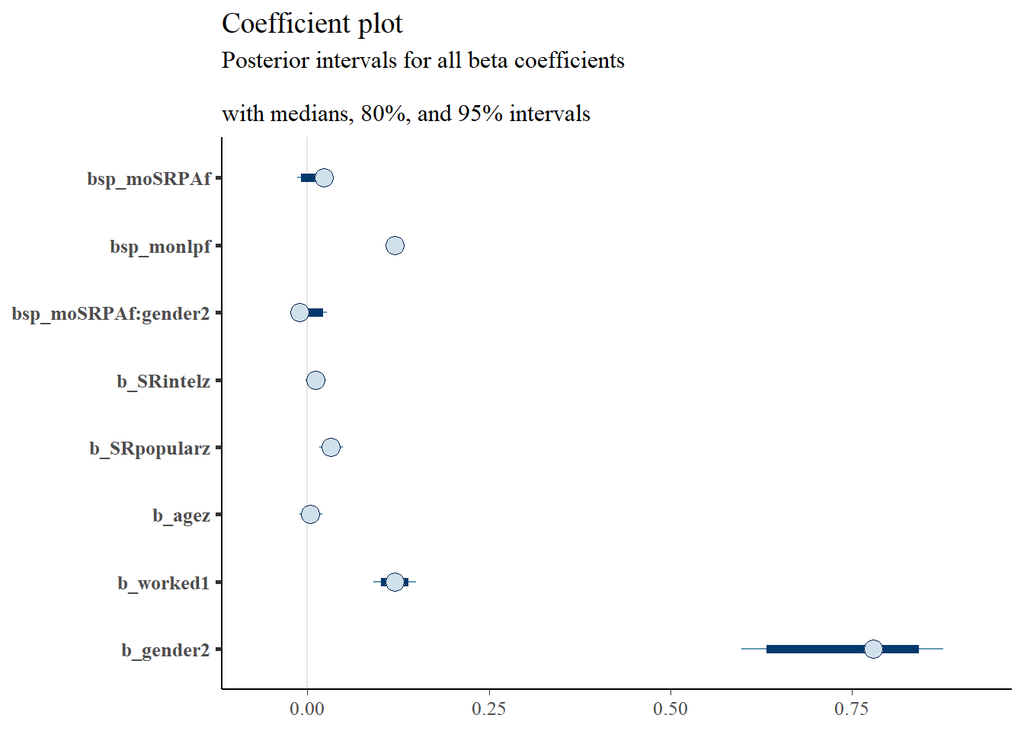

```r
coefgrp <- c("bsp_","b_SR", "age", "worked", "b_gender")
mcmc_plot(mod7mo, variable = coefgrp, regex = TRUE,
          prob = 0.80, prob_outer = 0.95) +
  labs(title = "Coefficient plot",
       subtitle = "Posterior intervals for all beta coefficients
       \nwith medians, 80%, and 95% intervals")
```

**Conditional effects (continuous y)**

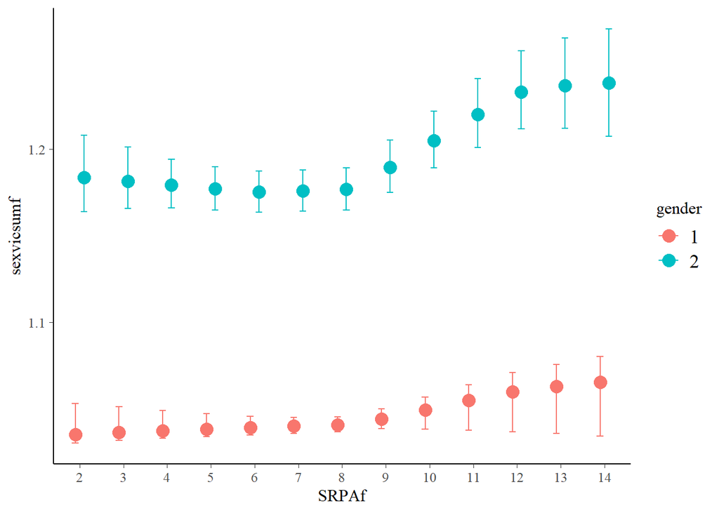

```r
conditional_effects(mod7mo, "SRPAf:gender")
```

**Fit summary**

```r
summary(mod7mo, probs = c(0.025, 0.975), digits = 2) #summarize results
```

```
 Family: cumulative
  Links: mu = probit; disc = identity
Formula: sexvicsumf ~ 1 + mo(SRPAf) + mo(nlpf) + SRintelz + SRpopularz + agez + worked + gender + mo(SRPAf):gender
   Data: datv3tmp (Number of observations: 47532)
  Draws: 4 chains, each with iter = 10000; warmup = 1000; thin = 1;
         total post-warmup draws = 36000

Regression Coefficients:
                Estimate Est.Error l-95% CI u-95% CI Rhat Bulk_ESS Tail_ESS
Intercept[1]        1.93      0.06     1.77     2.01 1.01      389      734
Intercept[2]        2.38      0.06     2.22     2.46 1.01      389      734
Intercept[3]        3.17      0.06     3.01     3.26 1.01      390      736
Intercept[4]        3.64      0.07     3.47     3.73 1.01      396      764
SRintelz            0.01      0.01    -0.00     0.03 1.00    22800    26129
SRpopularz          0.03      0.01     0.02     0.05 1.00     4013     8139
agez                0.00      0.01    -0.01     0.02 1.00    53959    26596
worked1             0.12      0.01     0.09     0.15 1.00    53321    27309
gender2             0.76      0.08     0.60     0.87 1.01      382      744
moSRPAf             0.02      0.01    -0.01     0.03 1.01      387      776
monlpf              0.12      0.00     0.11     0.13 1.00    24391    26248
moSRPAf:gender2    -0.01      0.01    -0.02     0.03 1.01      380      766

Monotonic Simplex Parameters:
                     Estimate Est.Error l-95% CI u-95% CI Rhat Bulk_ESS
moSRPAf1[1]              0.06      0.05     0.01     0.18 1.00     1403
moSRPAf1[2]              0.05      0.05     0.01     0.19 1.00      922
moSRPAf1[3]              0.05      0.05     0.01     0.19 1.00      725
moSRPAf1[4]              0.05      0.05     0.00     0.19 1.00      648
moSRPAf1[5]              0.05      0.04     0.01     0.15 1.00     1122
moSRPAf1[6]              0.05      0.04     0.01     0.14 1.00     1628
moSRPAf1[7]              0.12      0.07     0.02     0.26 1.00      710
moSRPAf1[8]              0.16      0.08     0.02     0.33 1.01      508
moSRPAf1[9]              0.14      0.08     0.02     0.31 1.00      675
moSRPAf1[10]             0.13      0.07     0.02     0.29 1.00     1053
moSRPAf1[11]             0.08      0.05     0.01     0.19 1.00    42470
moSRPAf1[12]             0.07      0.05     0.01     0.19 1.00     7386
monlpf1[1]               0.21      0.02     0.18     0.25 1.00    38120
monlpf1[2]               0.23      0.02     0.18     0.27 1.00    33533
monlpf1[3]               0.13      0.02     0.09     0.18 1.00    31782
monlpf1[4]               0.12      0.03     0.07     0.17 1.00    32907
```

[output cut: 44 more lines]

```
moSRPAf:gender21[6]     18254
moSRPAf:gender21[7]       856
moSRPAf:gender21[8]      1135
moSRPAf:gender21[9]      1039
moSRPAf:gender21[10]     1683
moSRPAf:gender21[11]    24377
moSRPAf:gender21[12]    21583

Further Distributional Parameters:
     Estimate Est.Error l-95% CI u-95% CI Rhat Bulk_ESS Tail_ESS
disc     1.00      0.00     1.00     1.00   NA       NA       NA

Draws were sampled using sample(hmc). For each parameter, Bulk_ESS
and Tail_ESS are effective sample size measures, and Rhat is the potential
scale reduction factor on split chains (at convergence, Rhat = 1).
```

**Prior summary**

```r
prior_summary(mod6mo) #check priors
```

```
                                         prior     class             coef group
                                  normal(0, 1)         b
                                  normal(0, 1)         b             agez
                                  normal(0, 1)         b          gender2
                              normal(0, 0.083)         b          moSRPAf
                                  normal(0, 1)         b  moSRPAf:gender2
                                  normal(0, 1)         b         SRintelz
                                  normal(0, 1)         b       SRpopularz
                                  normal(0, 1)         b          worked1
                          student_t(3, 0, 2.5) Intercept
                              normal(-0.84, 1) Intercept                1
                              normal(-0.25, 1) Intercept                2
                               normal(0.25, 1) Intercept                3
                               normal(0.84, 1) Intercept                4
                                  dirichlet(1)      simo moSRPAf:gender21
 dirichlet(2, 2, 2, 2, 2, 2, 2, 2, 2, 2, 2, 2)      simo         moSRPAf1
 resp dpar nlpar lb ub       source
                               user
                       (vectorized)
                       (vectorized)
                               user
                       (vectorized)
                       (vectorized)
                       (vectorized)
                       (vectorized)
                            default
                               user
                               user
                               user
                               user
                            default
                               user
```

#### 9.2.1 Visualize max moSRPA effect by response category & gender (mod7mo)

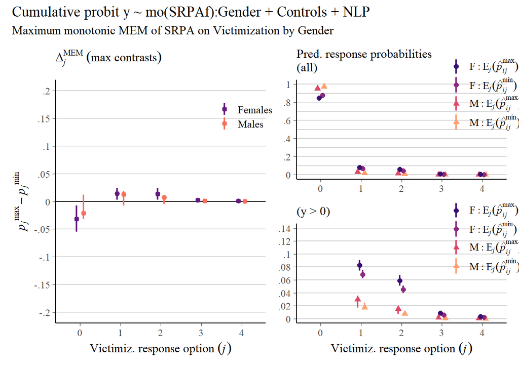

```r
#manual predictions at user-specified means or representative values

# function to generate var mean
# meanvar <- function(x){
#   mean(x, na.rm=TRUE)
# }

#define predictor grid for conditional avg at covariate means or rep values
# ndmo_gen <- tibble(
#   gender= c("1","2"),
#   nlpf = "2", #set at 2 lifetime partners (mean=1.9)
#   SRintelz = 0,
#   SRpopularz = 0,
#   agez = 0,
#   worked = "1") %>%
#   expand_grid(SRPAf = c("2","14"))

# generate and save predictions at user-specified covariate values
# mod7mopred <- predictions(mod7mo, newdata = ndmo_gen) %>%
#   data.frame() %>%
#   mutate(
#     colgrp = if_else(gender == "1" & SRPAf == "2", "M: E[italic(j)](hat(italic(p))[italic(ij)]^min)", "M: E[italic(j)](hat(italic(p))[italic(ij)]^max)"),
#     colgrp = if_else(gender == "2" & SRPAf == "2", "F: E[italic(j)](hat(italic(p))[italic(ij)]^min)", colgrp),
#     colgrp = if_else(gender == "2" & SRPAf == "14", "F: E[italic(j)](hat(italic(p))[italic(ij)]^max)", colgrp),
#   SRPAf = ifelse(SRPAf == "2", "E[italic(j)](hat(italic(p))[italic(ij)]^min)", "E[italic(j)](hat(italic(p))[italic(ij)]^max)"))


#Let's go with automated predictions by response category at means

mod7mopred <- predictions(mod7mo, variables = list(SRPAf = c("2","14")),
newdata = "mean", by = c("SRPAf", "group","gender")) %>%
  data.frame() %>%
  mutate(
    colgrp = if_else(gender == "1" & SRPAf == "2", "M: E[italic(j)](hat(italic(p))[italic(ij)]^min)", "M: E[italic(j)](hat(italic(p))[italic(ij)]^max)"),
    colgrp = if_else(gender == "2" & SRPAf == "2", "F: E[italic(j)](hat(italic(p))[italic(ij)]^min)", colgrp),
    colgrp = if_else(gender == "2" & SRPAf == "14", "F: E[italic(j)](hat(italic(p))[italic(ij)]^max)", colgrp),
  SRPAf = ifelse(SRPAf == "2", "E[italic(j)](hat(italic(p))[italic(ij)]^min)", "E[italic(j)](hat(italic(p))[italic(ij)]^max)"))


#function to find & drop leading zeroes (used for x-axis label)
dropLeadingZero <- function(l){
  str_replace(l, '0(?=.)', '')
}

mod7mopred_m <- mod7mopred %>% dplyr::filter(gender=="1")
mod7mopred_f <- mod7mopred %>% dplyr::filter(gender=="2")

#full range of y responses (0:4)
mod7mop1 <-  ggplot(mod7mopred, aes(x = group, y = estimate, ymin = conf.low, ymax = conf.high,
             color = colgrp)) +
  geom_hline(yintercept = 0:10 / 10, color = "lightgrey") +
  geom_linerange(data=mod7mopred_m, aes(color = colgrp), linewidth = 3/4, position = position_dodge(width = 1/3)) +
  geom_point(data=mod7mopred_m, aes(shape = colgrp),
             position = position_dodge(width = 1/3),
             size = 2) +
  geom_linerange(data=mod7mopred_f, aes(color = colgrp), linewidth = 3/4, position = position_dodge(width = 1/6)) +
  geom_point(data=mod7mopred_f, aes(shape = colgrp),
             position = position_dodge(width = 1/6),
             size = 2) +
  scale_color_viridis_d(NULL, option = "magma", begin = .2, end = .8,
                        labels = scales::parse_format()) +
  scale_shape_manual(NULL, values = c(19, 19, 17, 17),
                     labels = scales::parse_format()) +
  scale_y_continuous(limits = c(0, 1), breaks=seq(0, 1, by = .2),
                     labels = dropLeadingZero) +
  labs(subtitle = "Pred. response probabilities\n(all)") +
  theme(legend.background = element_blank(),
        legend.position = c(0.9, 0.85),
        legend.key.height= unit(.5, 'cm'),
        legend.key.width= unit(.5, 'cm'),
        legend.title = element_text(size=10),
        legend.text=element_text(size=10),
        axis.title.y = element_blank(),
        axis.title.x = element_blank())


#nonzero victimization values only (1:4)
mod7mop2 <-  ggplot(mod7mopred, aes(x = group, y = estimate, ymin = conf.low, ymax = conf.high,
             color = colgrp)) +
  geom_hline(yintercept = 0:7 / 50, color = "lightgrey") +
  geom_linerange(data=mod7mopred_m, aes(color = colgrp), linewidth = 3/4, position = position_dodge(width = 1/3)) +
  geom_point(data=mod7mopred_m, aes(shape = colgrp),
             position = position_dodge(width = 1/3),
             size = 2) +
  geom_linerange(data=mod7mopred_f, aes(color = colgrp), linewidth = 3/4, position = position_dodge(width = 1/6)) +
  geom_point(data=mod7mopred_f, aes(shape = colgrp),
             position = position_dodge(width = 1/6),
             size = 2) +
  scale_color_viridis_d(NULL, option = "magma", begin = .2, end = .8,
                        labels = scales::parse_format()) +
  scale_shape_manual(NULL, values = c(19, 19, 17, 17),
                     labels = scales::parse_format()) +
  scale_y_continuous(limits = c(0, .14), breaks=seq(0, .14, by = .02),
                     labels = dropLeadingZero) +
  labs(subtitle = "(y > 0)",
       x = expression(Victimiz.~response~option~(italic(j)))) +
  theme(legend.background = element_blank(),
        legend.position = c(0.9, 0.85),
        legend.key.height= unit(.5, 'cm'),
        legend.key.width= unit(.5, 'cm'),
        legend.title = element_text(size=10),
        legend.text=element_text(size=10),
        axis.title.y = element_blank()
        )


# estimate contrasts at means or rep values

mod7mocon <- comparisons(mod7mo, variables = list(SRPAf = c("2","14")),
newdata = "mean", by = c("group","gender")) %>%
  data.frame() %>%
  mutate(
    gender = if_else(gender == "1", "Males", "Females"))


mod7mop3 <- mod7mocon %>%
  ggplot(aes(x = group, y = estimate, ymin = conf.low, ymax = conf.high, color = gender)) +
  geom_hline(yintercept = -4:4 / 20, color = "lightgrey") +
  geom_hline(yintercept = 0, color = "black") +
  geom_pointrange(aes(color = gender), linewidth = 3/4, size = 1/3, position = position_dodge(width = 1/3)) +
  scale_color_viridis_d(NULL, option = "magma", begin = .3, end = .7,
                        labels = scales::parse_format()) +
  scale_y_continuous(expression(italic(p[j])^max-italic(p[j])^min),
                     limits = c(-0.2, 0.2), breaks=seq(-.2, .2, by = .05),
                     labels = dropLeadingZero) +
  labs(subtitle = expression(Delta[italic(j)]^{MEM}~(max~contrasts)),
       x = expression(Victimiz.~response~option~(italic(j)))) +
  theme(legend.background = element_blank(),
        legend.position = c(0.9, 0.85),
        legend.key.height= unit(.5, 'cm'),
        legend.key.width= unit(.5, 'cm'),
        legend.title = element_text(size=10),
        legend.text=element_text(size=10)
        )

# combine and entitle
((mod7mop3 | mod7mop1 / mod7mop2)) +
  plot_annotation(title = "Cumulative probit y ~ mo(SRPAf):Gender + Controls + NLP",
  subtitle = "Maximum monotonic MEM of SRPA on Victimization by Gender")
```

#### 9.2.2 “Interaction Model 3 (Controls + NLP)” Contrasts

```r
mod7mocon %>% gt()
```

| rowid | term | group | contrast | gender | estimate | conf.low | conf.high | predicted_lo | predicted_hi | predicted | tmp_idx |
| --- | --- | --- | --- | --- | --- | --- | --- | --- | --- | --- | --- |
| 1 | SRPAf | 0 | mean(14) - mean(2) | Females | -0.03191 | -0.05434 | -0.00729 | 0.87898 | 0.84699 | 0.88303 | 1 |
| 2 | SRPAf | 0 | mean(14) - mean(2) | Males | -0.02123 | -0.03154 | 0.01197 | 0.97431 | 0.95349 | 0.97030 | 2 |
| 1 | SRPAf | 1 | mean(14) - mean(2) | Females | 0.01423 | 0.00327 | 0.02406 | 0.06817 | 0.08241 | 0.06628 | 1 |
| 2 | SRPAf | 1 | mean(14) - mean(2) | Males | 0.01268 | -0.00726 | 0.01859 | 0.01741 | 0.02981 | 0.01988 | 2 |
| 1 | SRPAf | 2 | mean(14) - mean(2) | Females | 0.01391 | 0.00317 | 0.02378 | 0.04496 | 0.05890 | 0.04324 | 1 |
| 2 | SRPAf | 2 | mean(14) - mean(2) | Males | 0.00751 | -0.00417 | 0.01133 | 0.00758 | 0.01496 | 0.00895 | 2 |
| 1 | SRPAf | 3 | mean(14) - mean(2) | Females | 0.00262 | 0.00059 | 0.00458 | 0.00588 | 0.00850 | 0.00557 | 1 |
| 2 | SRPAf | 3 | mean(14) - mean(2) | Males | 0.00081 | -0.00043 | 0.00129 | 0.00058 | 0.00137 | 0.00071 | 2 |
| 1 | SRPAf | 4 | mean(14) - mean(2) | Females | 0.00114 | 0.00026 | 0.00205 | 0.00200 | 0.00314 | 0.00187 | 1 |
| 2 | SRPAf | 4 | mean(14) - mean(2) | Males | 0.00023 | -0.00012 | 0.00038 | 0.00013 | 0.00035 | 0.00016 | 2 |

We knew from earlier models that stratifying on NLP would result in much smaller predicted probability contrasts (i.e., SRPA’s maximum effect estimates). Comparing this gender interaction model to the previous interaction model without NLP reveals that the gender differences in contrasts have nearly disappeared after adjusting for NLP. This might indicate that observed gender differences in the effects of SRPA on sexual victimization are accounted for largely by increased exposure risks of physically attractive and sexually active women compared to men. The small remaining estimated effect may be accounted for by other unmeasured mechanisms like gratifiability.